# Power Analysis for Structural Equation Models: semPower 2 Manual

*Morten Moshagen & Martina Bader*

*2025-09-12*

Contact: morten.moshagen@uni-ulm.de

Please cite as:

- Moshagen, M., & Bader, M. (2024). semPower: General Power Analysis for Structural Equation Models. *Behavior Research Methods, 56*, 2901-2922. https://doi.org/10.3758/s13428-023-02254-7

##### Version history

The first iteration of `semPower` was developed as a java program in 2015 and was ported as a slightly extended version to R a year afterwards. These versions provided support for a priori, post hoc, and compromise model-free power analyses based on common effect-size measures such as the RMSEA. The R package was subsequently extended to support covariance matrices as input as an alternative way to define the effect. The current, second version of `semPower` expands this approach by providing many convenience functions to define the effect in terms of model parameters, covering many commonly encountered model structures, and also supports simulated power estimation in addition to analytical power analyses.

##### Installation

The `semPower` package can be installed via [CRAN](https://cran.r-project.org/package=semPower). The latest development version is available from github at https://github.com/moshagen/semPower and can be installed as follows:

```r
# install.packages("devtools")
devtools::install_github("moshagen/semPower")
```

(Very) basic functionality is also provided as a shiny app, which can be used online at https://sempower.shinyapps.io/sempower.

# 1 Introduction

`semPower` provides a collection of functions to perform power analyses for structural equation models. Statistical power is a concept arising in the context of classical (frequentist) null-hypothesis significance testing and is defined as the probability to reject a certain hypothesis if this hypothesis is factually wrong. As a general rule, a hypothesis test is only meaningful to the extent that statistical power is reasonably high, because otherwise a non-significant test outcome carries little information regarding the veracity of the tested hypothesis.

For illustration, consider a simple two-factor CFA model and assume that the interest lies in detecting that the correlation between the factors differs from zero. To test the hypothesis that the factors are uncorrelated, one can compare a model that freely estimates the factor correlation with an otherwise identical model that restricts the correlation between these factors to zero. If the restricted model fits the data significantly worse, the hypothesis of a zero correlation between the factors is rejected, in turn, informing the conclusion that the correlation between the factors differs from zero.

Statistical power now gives the probability that the outcome of the model test associated with this hypothesized model turns out significant on a certain alpha-error level with a certain sample size. Suppose that the correlation between the factors is $r = .20$ in the population, each factor is measured by 3 indicators and all (non-zero) loadings equal .5, $\alpha = .05$, and a sample size of $N = 125$. Then, the probability of obtaining a significant test outcome to detect a correlation of $r \geq .20$ is just 20%. Stated differently, in 4 out of 5 random samples (each of size $N = 125$) one will *not* detect that the factors are correlated. Indeed, to obtain a more reasonable power of 80% in this scenario, a sample size of $N = 783$ is required.

Correspondingly, statistical power is an integral part in planning the required sample size and statistical hypothesis testing more generally. Of note, however, a sufficiently large sample to obtain a certain power does not always imply a sufficiently large sample to enable model estimation. At times, the required sample size to yield a sufficiently high power might still be too small to estimate the model at hand, so that sample size considerations should also be based on other factors beyond statistical power.

## 1.1 Types of power analyses

Generally, statistical power depends on

- the extent to which the tested hypothesis is wrong (= the magnitude of effect)
- the sample size (N)
- the alpha error (alpha)
- the degrees of freedom (df)

and will be higher for a larger effect, a larger sample size, a higher alpha error, and fewer degrees of freedom. (Note that this only applies for effect-size metrics that do not adjust for parsimony.[^1]) When performing a power analysis, one of these quantities is computed as a function of the other quantities, giving rise to different types of power analyses:

- **A priori power analysis**: Determines the required sample size to detect a certain effect with a desired power, given alpha and df.
- **Post-hoc power analysis**: Determines the achieved power to detect a certain effect with a given sample size, alpha and df.
- **Compromise power analysis**: Determines the alpha and the beta error, given the alpha/beta ratio, the sample size, a certain effect, and the df.

Each type of power analysis has different aims. A priori power analyses are performed prior to data collection to inform the required number of observations to detect an expected effect with the desired power. Post-hoc power analyses are performed after data collection to judge whether the given sample size yields a power that is sufficiently high for a meaningful test of a certain hypothesis. Post-hoc power analyses are not to be confused with “observed power”. Estimates of “observed power” determine power to detect an effect size observed in a study, which is close to meaningless (see Yuan & Maxwell, 2005, for details). Compromise power analyses are used to determine which decision rule to apply in evaluating whether the outcome of a hypothesis test favors the null or the alternative hypothesis (see Moshagen & Erdfelder, 2016, for details).

## 1.2 Types of hypotheses

Statistical power is always tied to a particular hypothesis, so power will typically differ even for the same (base-)model depending on which hypothesis is considered. A general statement such as “power was 80%” is meaningless, unless the hypothesis for which power was determined is also stated (such as “power to detect a correlation $\geq .2$ between the first and the second factor was 80%.”). Moreover, power can be high for one hypothesis, but low for other hypotheses, so a power analysis should always be performed concerning (a) the focal hypotheses and (b) the hypothesis where the smallest effect is expected.

In SEM, the typical types of hypotheses that occur either implement equality constraints on two or more parameters (such as cross-group constraints) or assign a particular parameter a specific value (such as zero).[^2] For instance, consider a cross-lagged panel model (CLPM) with two constructs *X* and *Y* measured by three indicators each at three different waves (so the full model comprises six factors). Relevant (non-exhaustive) hypotheses could be

- whether the model as a whole describes the data well.
- whether measurement invariance over time concerning the indicators holds.
- whether the autoregressive effects of *X* are constant across waves.
- whether the autoregressive effects of *X* are different from zero.
- whether the autoregressive effects of *Y* are constant across waves.
- whether the autoregressive effects of *Y* are different from zero.
- whether the autoregressive effects of *X* are equal to those of *Y*.
- whether the cross-lagged effects of *X* on *Y* are constant across waves.
- whether the cross-lagged effects of *Y* on *X* are constant across waves.
- whether the cross-lagged effects of *X* on *Y* are different from zero.
- whether the cross-lagged effects of *Y* on *X* are different from zero.
- whether the cross-lagged effects of *X* on *Y* are equal to those of *Y* on *X*.
- whether the synchronous (residual) correlations between *X* and *Y* differ from zero.
- whether the synchronous (residual) correlations are equal across waves.

Any of these hypotheses will likely be associated with a different expectation of what reflects the relevant magnitude of effect and consequently with a different power to detect this effect. For example, concerning the hypothesis of whether an autoregressive effect differs from zero, one will usually be satisfied to obtain sufficient power to detect a large regression coefficient (of, say, $b \geq .50$). Concerning the cross-lagged effects, however, one rather wants sufficient power to detect a small regression coefficient (of, say, $b \geq .10$). Furthermore, a cross-lagged effect of *X* on *Y* of .10 will not always be associated with the same power as a cross-lagged effect of *Y* on *X* of the same magnitude, because power to detect a cross-lagged effect also depends on all other parameters of the model, such as autoregressive effects and loadings.

To give a number of examples, the following provides the required sample sizes to yield a power of 80% on $\alpha = .05$, assuming that *X* and *Y* are measured by three indicators each each of 2 waves, all loadings on *X* are .5 and those on *Y* are .7, and all autoregressive and cross-lagged effects are equal for *X* and *Y*:

- N = 249 to detect that the model exhibits misfit corresponding to RMSEA $\geq$ .05.
- N = 138 to detect that the autoregressive effect of *X* is $\geq$ .50
- N = 56 to detect that the autoregressive effect of *Y* is $\geq$ .50
- N = 1836 to detect that the cross-lagged effect of *X* on *Y* is $\geq$ .10
- N = 2110 to detect that the cross-lagged effect of *Y* on *X* is $\geq$ .10

Correspondingly, one should define the relevant hypothesis of interest carefully when performing a power analysis (and again note that the required $N$ to achieve sufficient power is not necessarily sufficient to support model estimation).

## 1.3 Performing power analyses

Next to defining a relevant hypothesis, performing a power analysis (obviously) requires a decision on which type of power analysis to perform. The types of power analyses available in `semPower` are:

- semPower.aPriori to perform an a priori power analysis (i.e., determine the required sample size).
- semPower.postHoc to perform a post hoc power analysis (i.e., determine the achieved power).
- semPower.compromise to perform a compromise power analysis (i.e., determine a reasonable decision rule).

Any power analysis requires to specify the magnitude of effect that is to be detected in a certain metric. The functions stated above understand the following effect-size measures: F0, RMSEA, Mc, GFI, and AGFI. Because any of these effect measures apply equally regardless of the particular type of model considered, the functions above are also referred to as model free power analyses. For example, the statement that power to reject a model with 100 df exhibiting misspecifications corresponding to RMSEA $\geq .05$ on $\alpha$ = .05 with a sample size of 250 is $1 - \beta$ = 97% is always true, regardless of whether the model under scrutiny is a CFA model, a CLPM, a multigroup model, or any other SEM model. It is the very nature of effect sizes that they are agnostic with respect to how a particular model looks like.

However, a common problem in performing a power analysis is that it is often difficult to translate a specific hypothesis into a specific value for a specific effect size (such as a specific value for the RMSEA). Consider the situation that one is interested in determining whether two factors in a CFA model are correlated. A suitable model to test this hypothesis would constrain the correlation between these factors to zero. When this constrained model fits the data as well as the unconstrained model (freely estimating the correlation), both factors can be assumed to be orthogonal. Otherwise, one would conclude that the factors are correlated. Suppose that a correlation between these factors of $r \geq .1$ is considered a meaningful deviation from orthogonality. In terms of power analyses, one thus wants sufficient power to identify whether the correlation between the factors is at least $r = .1$. The misfit associated with a model assuming a correlation of 0 when, in reality, the true correlation is at least $r = .1$ is supposed to define the magnitude of effect. The problem is now that one cannot immediately say how this difference in a certain model parameter (the correlation between the factors) translates to an effect size such as the RMSEA.

For this reason, `semPower` also provides various convenience functions that allow for a model-based definition of the effect of interest in terms of model parameters as well as a more generic definition of the effect as function of population and model-implied means and covariance matrices. In the example above, the relevant convenience function (semPower.powerCFA) just requires the definition of the factor model and the specification of the to be detected correlation as input, and plugs the associated effect size (which is RMSEA = .05 in the scenario above when each factor is measured by three indicators loading by .5 each, and when df = 1) into one of the model-free power functions. Currently, `semPower` provides model-based power analyses for the following model types:

- Hypotheses arising in a standard CFA model.
- Hypotheses arising in models involving a bifactor structure.
- Hypotheses related to latent regressions.
- Hypotheses related to mediation models.
- Hypotheses related to generic path models.
- Hypotheses related to measurement invariance across groups.
- Hypotheses arising in a cross-lagged panel model.
- Hypotheses arising in a random intercept cross-lagged panel model.
- Hypotheses arising in a generic structural equation model.

The remainder of this document provides some notes on the statistical background, a formal definition of decision errors in hypothesis testing, statistical power, and various effect sizes, and a detailed description of the functions contained in this package.

# 2 Statistical Background

This chapter provides a brief statistical background on hypothesis testing, model estimation, and effect sizes in SEM.

## 2.1 Hypothesis Testing and Statistical Power

The statistical evaluation of mathematical models often proceeds by considering a test statistic that expresses the discrepancy between the observed data and the data as implied by the fitted model. In SEM, the relevant test statistic for a sample of size $N$ is given by $T = \hat{F}(N-1)$. $\hat{F}$ denotes the minimized sample value of the chosen discrepancy function (such as the Maximum Likelihood discrepancy function) and thereby indicates the lack of fit of the model to the sample data. Thus, $T$ permits a likelihood-ratio test of the null hypothesis (H0) that the model is correct. If the hypothesized model holds in the population, $T$ can be shown to follow asymptotically a central $\chi^2$(df) distribution with $df = .5 \cdot p(p+1) - q$ degrees of freedom, where $p$ is the number of manifest variables and $q$ denotes the number of free parameters. This is why $T$ is often referred to as the “chi-square model test statistic” – a convention which is followed here.

Based on the observed value for the chi-square test statistic, a null hypothesis significance test can be performed to evaluate whether this value is larger than what would be expected by chance alone. The usual test proceeds as follows: Given a certain specified alpha-error level (typically $\alpha$ = .05), a critical chi-square value is obtained from the asymptotic central $\chi^2$(df) distribution. If the observed value for the chi-square test statistic exceeds the critical value, the null hypothesis that the model fits the data is rejected. Otherwise, H0 is retained. Finding that the observed test statistic exceeds the critical value (implying an upper-tail probability that falls below the specified alpha level) thus leads to the statistical decision that the discrepancy between the hypothesized and the actual population covariance matrix is too large to be attributable to sampling error only. Accordingly, a statistically significant chi-square test statistic provides evidence against the validity of the hypothesized model.

When testing statistical hypotheses using this framework, two types of decision errors can occur: The alpha error (or Type-I error) of incorrectly rejecting a true H0 (a correct model) and the beta error (or Type-II error) of incorrectly retaining a false H0 (an incorrect model). Statistical power is defined as the complement of the beta-error probability ($1 - \beta$) and thus gives the probability to reject an incorrect model.

If the H0 is false, the chi-square test statistic is no longer central $\chi^2$(df) distributed, but can be shown to follow a noncentral $\chi^2$(df, $\lambda$) distribution with a non-centrality parameter $\lambda$ and an expected value of df + $\lambda$ (MacCallum et al., 1996). The non-centrality parameter $\lambda$ shifts the expected value of the non-central $\chi^2$(df, $\lambda$) distribution to the right of the corresponding central distribution. Having determined the critical value associated with the desired alpha probability from the central $\chi^2$(df) distribution, the beta-error probability can be computed by constructing the corresponding non-central $\chi^2$(df, $\lambda$) distribution with a certain non-centrality parameter $\lambda$ and obtaining the area (i.e., the integral) of this distribution to the left of the critical value:

$$\beta = \int_{0}^{\chi^2_{crit}} f_{\chi^2(df, \lambda)}(x) \, dx$$
Correspondingly, statistical power is the area of the non-central $\chi^2$(df, $\lambda$) distribution to the right of the critical value, i.e., $= 1 - \beta$. The general situation is illustrated in the following figure.

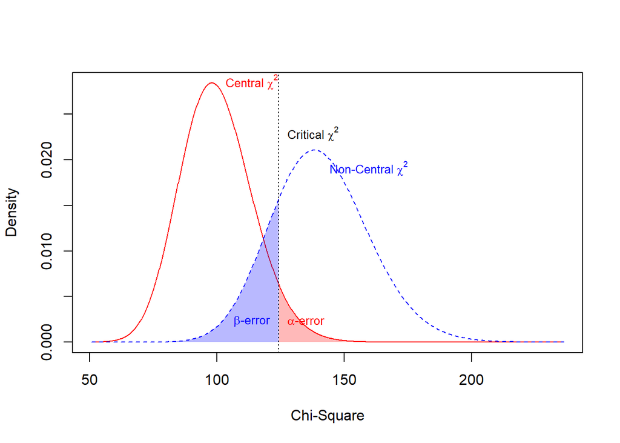

Figure 2.1: Central (red) and non-central (blue) chi-square distributions.

The figure depicts a central (solid) $\chi^2$(df = 100) and a non-central (dashed) $\chi^2$(df = 100, $\lambda = 40.75$). The area of the central distribution $\chi^2$(df) to the right of the critical value reflects the alpha error. The black vertical line indicates a critical value of 124, which corresponds to alpha = .05. The area of $\chi^2$(df, $\lambda$) distribution to the left of the critical value is the beta-error probability, which takes a value of beta = .20 in this example. Statistical power is defined as 1 - beta, that is, the area under the noncentral $\chi^2$(df, $\lambda$) distribution to the right of the critical value.

## 2.2 Measures of Effect

As evident from the above, power depends on the applied critical value corresponding to a certain alpha error probability and on the distance between the central and the non-central $\chi^2(df)$ distributions as quantified by the non-centrality parameter $\lambda$. The non-centrality parameter $\lambda$, in turn, depends on the number of observations $N$ and on the degree to which the tested H0 is factually wrong, i.e., on the discrepancy between the H0 and the H1 model (the effect size).

To define the discrepancy between the H0 and the H1 model for power analysis, any non-centrality based measure of effect can be used. For model-free power analyses, `semPower` understands the measures detailed below. Any model-based power analysis is eventually converted into the population minimum of the fit function as effect size.

##### F0

$F_0$ is the population minimum of the chosen fitting function, such as weighted least-squares (WLS) or Maximum Likelihood (ML). The ML fitting function is

The WLS fitting function is
$$F_0 = (\sigma - s)' V (\sigma - s)$$
where $\sigma = vec(\mu, \Sigma)$, $s = vec(\hat \mu, \hat \Sigma)$, and $V$ is a weight matrix. In the (full) WLS fitting function, $V$ is (often) the inverse of $N$ times the asymptotic covariance matrix of the sample statistics. In the DWLS fitting function, $V$ is a diagonal matrix with the inverse of the diagonal elements of $N$ times the asymptotic covariance matrix of the sample statistics. The ULS fitting function is a special case with $V = I$

If the model is correct, $\hat{\Sigma} = \Sigma$, $\hat{\mu} = \mu$, and thus $F_0 = 0$. Otherwise, $F_0 > 0$ with higher values expressing a larger discrepancy (misfit) of the model to the data.

If fitting a model to some sample data of size $N$, the estimated minimum of the fit function, $\hat{F}$, is used to construct an asymptotically $\chi^2$-distributed model test statistic, commonly simply called the chi-square model test:

$$\chi^2 = \hat{F}(N-1)$$
Note that $\hat{F}$ is a biased estimate of $F_0$: If $F_0 = 0$, the expected value of $\hat{F}$ is df, i.e., the model degrees of freedom. For a model with $q$ free parameters, the df are given by
$$df = \dfrac{p(p+1)}{2} - q$$

Whereas $F_0$ is the genuine measure of effect in SEM, the main disadvantage is that specific values are difficult to interpret because of its logarithmic scaling and because specific values also depend on features unrelated to model fit such as a the number of manifest variables comprised in the model. For these reasons, various transformations of $F_0$ exist that are described in the following.

##### RMSEA

The Root-Mean-Squared Error of Approximation (RMSEA; Browne & Cudeck, 1992; Steiger & Lind, 1980) scales $F_0$ by the model degrees of freedom:

$$RMSEA = \sqrt{(F_0/df)}$$
so that the RMSEA is bounded by zero and lower values indicate a better fit. The implied $F_0$ is:
$$F_0 = df \cdot RMSEA^2$$
Given that $F_0$ is scaled by the df, defining an effect in terms of the RMSEA requires specification of the degrees of freedom.

##### Mc

McDonald’s (1989) measure of non-centrality (Mc) is a transformation of $F_0$ on the interval 0-1, with higher values indicating better fit.

$$Mc = e^{-.5F_0}$$
so that
$$F_0 = -2\ln{Mc}$$

##### GFI

The Goodness-of-Fit Index (GFI; Jöreskog & Sörbom, 1984; Steiger, 1990) scales $F_0$ on the interval 0-1, with higher values indicating better fit:

$$GFI = \dfrac{p}{p+2F_0}$$

$$F_0 = \dfrac{p (1-GFI)}{2GFI}$$
As the GFI depends on the number of observed variables ($p$), this number needs to be provided when defining an effect in terms of the GFI.

##### AGFI

The Adjusted Goodness-of-Fit Index (AGFI; Jöreskog & Sörbom, 1984; Steiger, 1990) modifies the GFI by including a penalty for the number of free parameters, as measured by the model degrees of freedom:

$$AGFI = 1 - \dfrac{p(p+1)}{2df} \left(1 - \dfrac{p}{p+2F_0} \right)$$
$$F_0 = \dfrac{p (1-AGFI) df}{p(p+1) -2df(1-AGFI)}$$

Specifying an effect in terms of the AGFI requires specification of both the number of observed variables ($p$) and the model degrees of freedom ($df$).

##### Measures not based on non-centrality

Fit-indices that are not based on non-centrality have no straightforward relation to $F_0$ and are thus not well suited for power analyses. However, when the input parameters include covariance matrices, `semPower` also reports the following measures.

###### SRMR

The Standardized Root-Mean-Square Residual (SRMR) is a measure of the (root of the) average (squared) difference between the (standardized) model-implied and population covariance matrices. It ranges from 0 to 1, with lower values indicating better fit. Let $E_0$ be the difference between the model-implied and the population covariance matrix, $E_0 = \Sigma - \hat{\Sigma}$, $vech$ denote the vectorization transformation, and $Q$ be a diagonal matrix of dimension $.5p(p+1)$ containing the inverse of the product of standard deviations of observed variables $i$ and $j$. Then, the SRMR can be defined as

$$SRMR = \sqrt{\dfrac{1}{.5p(p+1)}vech(E_0) \cdot Q \cdot vech(E_0)'}$$

The relation of the residual matrix $E_0$ to $F_0$ is complex and depends on the model-implied covariance matrix, so the SRMR is not well suited to define an effect in terms of $F_0$ (based on ML estimation):
$$F_0 = -\ln|I + \hat{\Sigma}^{-.5} E_0 \hat{\Sigma}^{-.5}|$$

###### CFI

The Comparative Fit Index (CFI) is an incremental index expressing the proportionate reduction of misfit associated with the hypothesized model ($F_{0H}$) in relation to the null model ($F_{0N}$), defined as a model that constrains all covariances to zero. In the population, the CFI ranges from 0 to 1, with higher values indicating better fit.

$$CFI = \dfrac{F_{0N}-F_{0H}}{F_{0N}}$$

Although it is simple to obtain $F_0$ from the CFI, this requires knowledge of $F_{0N}$, which is rather difficult to determine a priori:

$$F_0 = F_{0N} - CFI \cdot F_{0N}$$

# 3 Model-free power analyses

Performing a power analysis generally requires the specification of a measure and magnitude of effect that is to be detected and a provision of the model degrees of freedom (df). Further arguments are required depending on the type of power analysis.

The functions described in this chapter are “model-free” in the sense that the results depend on the df of a model, but are otherwise agnostic with respect to how a particular model looks like. For instance, the power to reject a model with df = 100 exhibiting an RMSEA $\geq$ .05 with N = 500 on $\alpha$ = .05 is always the same, regardless of whether the model is a CFA model, a mediation model, a CLPM, or a multigroup model.

By contrast, model-based power analyses define the effect of interest in terms of particular model parameters, so different functions are required for different types of models. However, the functions performing model-based power analysis are actually only a high-level interface and eventually transform a particular hypothesis concerning the model parameters into an effect size understood by model-free power analyses.

Thus, regardless of whether the effect of interest is directly defined in terms of an effect size understood by `semPower` or indirectly via constraints on particular model parameters, the actual power analysis is always performed by one of the following functions.

## 3.1 A priori power analysis: Determine N

The purpose of a priori power analyses is to determine the required sample size to detect an effect with a certain probability on a specified alpha error. In the language of structural equation modeling, an a priori power analysis asks: How many observations do I need to detect the effect of interest (i.e., falsify the model under scrutiny) with a certain probability (statistical power)?

Performing an a priori power analyses requires the specification of:

- the alpha error (`alpha`)
- the desired power (`power`; or, equivalently, the acceptable beta error, `beta`)
- the type of effect (`effect.measure`)
- the magnitude of effect (`effect`)
- the degrees of freedom of the model (`df`). See how to obtain the df if you are unsure.

Depending on the chosen effect size measure, it may also be required to define the number of observed variables (`p`).

Suppose one wants to determine the required sample size to detect misspecifications of a model (involving df = 50 degrees of freedom) with a power of 80% on an alpha error level of .05, where the amount of misfit corresponds to an RMSEA of at least .05. To achieve this, the function `semPower.aPriori` is called with arguments `effect = .05`, `effect.measure = 'RMSEA'`, `alpha = .05`, `power = .80`, and `df = 50`. The results are stored in a list called `ap`.

```r
ap <- semPower.aPriori(effect = .05, effect.measure = 'RMSEA',
                        alpha = .05, power = .80, df = 50)
```

Equivalently, instead of calling the `semPower.aPriori` function, one may also use the generic `semPower` function with the additional `type = 'a-priori'` argument:

```r
ap <- semPower(type = 'a-priori',
               effect = .05, effect.measure = 'RMSEA',
               alpha = .05, power = .80, df = 50)
```

Calling the `summary` method on `ap` prints the results and a figure of the associated central and non-central $\chi^2$ distributions.

```r
summary(ap)
```

```
##
##  semPower: A priori power analysis
##
##  F0                        0.125000
##  RMSEA                     0.050000
##  Mc                        0.939413
##
##  df                        50
##  Required Num Observations 243
##
##  Critical Chi-Square       67.50480
##  NCP                       30.25000
##  Alpha                     0.050000
##  Beta                      0.199142
##  Power (1 - Beta)          0.800858
##  Implied Alpha/Beta Ratio  0.251077
```

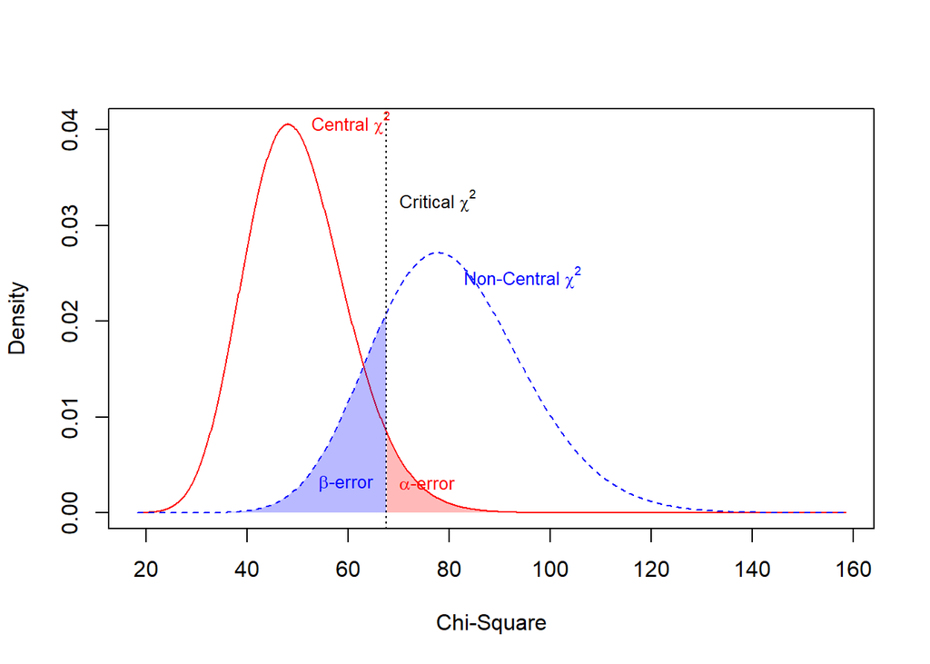

This shows that N = 243 yields a power of approximately 80% to detect the specified effect.

Note that whereas $N \geq 243$ is sufficient to a yield the desired power, larger samples might be required to enable successful model estimation, for instance, when the model under scrutiny comprises a large number of free parameters. The required sample size determined in an a priori power analysis merely gives the lower bound concerning the desired power, but does not consider aspects such as proper convergence and accuracy of parameter recovery when estimating the model under scrutiny. As a more extreme example, the following yields a required N of 14:

```r
ap <- semPower(type = 'a-priori',
               effect = .08, effect.measure = 'RMSEA',
               alpha = .05, power = .80, df = 2000)
```

N = 14 is entirely correct in terms of the desired power (of 80%) for the stated hypothesis (reject a model exhibiting an RMSEA $\geq$ .08 on 2000 df), but will generally be far from sufficient to support the estimation of a model involving 2000 df. As another extreme example, the following yields a required N of 78,516:

```r
ap <- semPower(type = 'a-priori',
               effect = .01, effect.measure = 'RMSEA',
               alpha = .05, power = .80, df = 1)
```

N = 78,516 is also entirely correct when the aim is to yield a power of 80% to reject a model exhibiting an RMSEA $\geq$ .01 on 1 df. However, parameter estimation will likely succeed when the sample is much smaller. Correspondingly, the required sample size to obtain a certain power and the required sample size to obtain trustworthy parameter estimates are different issues. Power is just one aspect in sample size planning.

The output printed above further shows the `Critical Chi-Square`, the non-centrality parameter (`NCP`), and the ratio between the error probabilities (`Implied Alpha/Beta ratio`). In this example, the ratio between alpha and beta is approximately 0.25, showing that committing an beta error is four-times as likely as committing an alpha error. This is obviously a consequence of the chosen input parameters, since a power (1 - beta) of .80 implies an beta error of .20, which is four times the chosen alpha error of .05.

`semPower` also converts the chosen effect into other effect size measures: An RMSEA of .05 (based on df = 50) corresponds to $F_0$ = 0.125 and Mc = .939. If one is also interested in obtaining the associated GFI and AGFI, the number of variables needs to be provided. When the model involves 20 observed variables, the call above can be modified by including the argument `p = 20`:

```r
ap <- semPower.aPriori(effect = .05, effect.measure = 'RMSEA',
                       alpha = .05, power = .80, df = 50, p = 20)
```

Now the GFI and AGFI values equaling RMSEA = .05, assuming df = 50 and p = 20, are also provided.

If one is interested in how power changes for a range of sample sizes, it is useful to request a power plot.

## 3.2 Post hoc power analysis: Determine power

The purpose of post hoc power analyses is to determine the actually achieved power to detect a specified effect with given sample size on a certain alpha-error level. In the language of structural equation modeling, a post hoc power analysis asks: With my sample size at hand, how large is the probability (power) to detect the effect of interest?

Performing a post hoc power analyses requires the specification of:

- the alpha error (`alpha`)
- the sample size (`N`)
- the type of effect (`effect.measure`)
- the magnitude of effect (`effect`)
- the degrees of freedom of the model (`df`). See how to obtain the df if you are unsure.

Depending on the chosen effect-size measure, it may also be required to define the number of observed variables (`p`).

```r
ph <- semPower.postHoc(effect = .05, effect.measure = 'RMSEA',
                      alpha = .05, N = 1000, df = 100)
```

```r
ph <- semPower(type = 'post-hoc',
               effect = .05, effect.measure = 'RMSEA',
               alpha = .05, N = 1000, df = 100)
summary(ph)
```

```
##
##  semPower: Post hoc power analysis
##
##  F0                       0.250000
##  RMSEA                    0.050000
##  Mc                       0.882497
##
##  df                       100
##  Num Observations         1000
##  NCP                      249.7500
##
##  Critical Chi-Square      124.3421
##  Alpha                    0.050000
##  Beta                     2.903302e-17
##  Power (1 - Beta)         > 0.9999
##  Implied Alpha/Beta Ratio 1.722177e+15
```

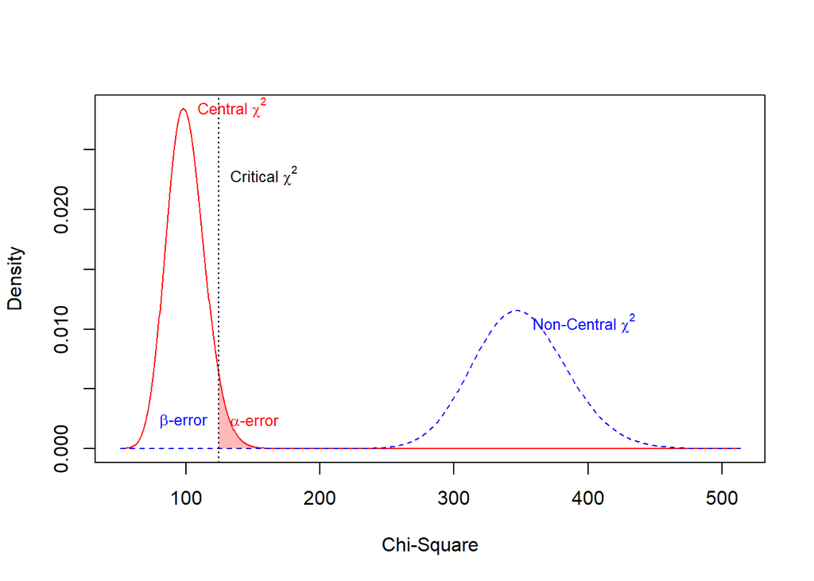

Calling the `summary` method on `ph` provides an output structured identically to the one produced by `semPower.aPriori` and shows that the power is very high (`power > .9999`). The associated error probabilities are provided in higher precision. Specifically, the beta error is `beta = 2.903302e-17` which translates into $2.9 \cdot 10^{-17} = 0.000000000000000029$. In practice, one would almost never miss a model with an actual RMSEA $\geq$ .05 (or F0 $\geq$ 0.25 or Mc $\leq$ .882) under these conditions. The implied alpha/beta ratio is 1.722177e+15, showing that committing an alpha error is about two quadrillion ($10^{15}$) times as likely as committing a beta error.

If one is interested in how power changes for a range of different magnitudes of effect (say, for RMSEAs ranging from .01 to .15), it is useful to request a power plot.

## 3.3 Compromise power analysis: Determine alpha and beta

The purpose of compromise power analyses is to determine alpha and beta (and the associated critical value of the chi-square test statistic) given a specified effect, a certain sample size, and a desired ratio between alpha and beta (Moshagen & Erdfelder, 2016). In the language of structural equation modeling, a compromise power analysis asks: With my sample size at hand, how should the critical value for the chi-square model test be defined to obtain proportionate alpha- and beta-error levels in deciding whether my model is rather aligned with the hypothesis of perfect fit or with the hypothesis of an unacceptable degree of misfit (as defined by the chosen effect)?

Performing a compromise power analyses requires the specification of:

- desired ratio between alpha and beta (`abratio`; defaults to 1)
- the sample size (`N`)
- the type of effect (`effect.measure`)
- the magnitude of effect (`effect`)
- the degrees of freedom of the model (`df`). See how to obtain the df if you are unsure.

Depending on the chosen effect-size measure, it may also be required to define the number of observed variables (`p`).

```r
cp <- semPower.compromise(effect = .08, effect.measure = 'RMSEA',
                           abratio = 1, N = 1000, df = 100)
```

Equivalently, instead of calling `semPower.compromise`, one may also use the generic `semPower` function with the additional `type = 'compromise'` argument:

```r
cp <- semPower(type = 'compromise',
               effect = .05, effect.measure = 'RMSEA',
               abratio = 1, N = 1000, df = 100)
summary(cp)
```

```
##
##  semPower: Compromise power analysis
##
##  F0                       0.250000
##  RMSEA                    0.050000
##  Mc                       0.882497
##
##  df                       100
##  Num Observations         1000
##  Desired Alpha/Beta Ratio 1.000000
##
##  Critical Chi-Square      192.8233
##  Implied Alpha            7.357816e-08
##  Implied Beta             7.357816e-08
##  Implied Power (1 - Beta) > 0.9999
##  Actual Alpha/Beta Ratio  1.000000
```

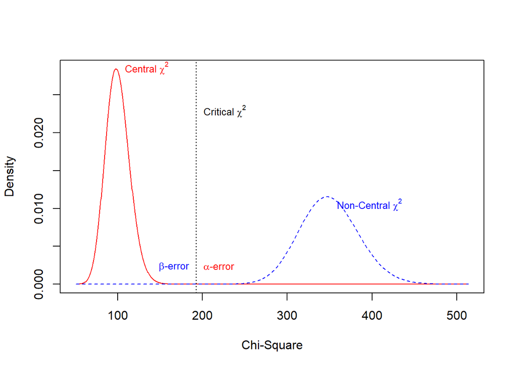

If one rather prefers the error probabilities to differ (for example because one considers falsely accepting an incorrect model to be 100 times as bad as falsely rejecting an correct model), this can be achieved by changing the `abratio` argument accordingly. For example, requesting the alpha error to be 100 times as large as the beta error proceeds by setting `abratio = 100`.

```r
cp <- semPower.compromise(effect = .08, effect.measure = 'RMSEA',
                           abratio = 100, N = 1000, df = 100)
```

## 3.4 Power-analysis to detect an overall difference between two models

A common scenario is to test two competing models against each other, where a more restrictive model (involving more df) is compared against a less restrictive model (involving less df). When the difference between these models lies just in a single (or few) particular parameter(s), the effect should be determined in terms of the model parameters. If, however, the difference between the models potentially spreads across multiple parameters (as, say, when comparing a 3-factor with a 5-factor model), one approach to power analysis it to define the models in terms of overall fit.

For example, to obtain the required sample size to yield a power of 80% to discriminate a model with an associated RMSEA of .04 on 44 df from a model with an associated RMSEA of .05 on 41 df, define both the `effect` and `df` arguments as vectors (do not define lists!) comprising two elements:

```r
ap <- semPower.aPriori(effect = c(.04, .05), effect.measure = 'RMSEA',
                       alpha = .05, power = .80, df = c(44, 41))
summary(ap)
```

which shows that 340 observations are required to discriminate these models. Post hoc and compromise power analyses are performed accordingly.

A similar situation often occurs in tests of measurement invariance, where one wants sufficient power to detect whether certain cross-group or cross-time constraints on the model parameters (such as equal loadings across groups) are violated. Again, the difference between such models can be defined through particular parameters, for instance, by assuming that a single loading differs by .1 across groups. However, it is also reasonable to assume that non-invariance spreads across multiple parameters (say, across all loadings), so that one approach to power analysis it to define the models in terms of overall fit.

The general syntax is the same as above, but now the `N` argument also needs to be set, which gives the number of observations by group in compromise and post hoc power analysis, and the group weights in a priori power analysis. For example, the following asks for the required sample size to detect a change in the Mc of .01 in a three-group model, where all groups are equal-sized (`N = c(1, 1, 1)`):

```r
ap <- semPower.aPriori(effect = c(.99, .98), effect.measure = 'Mc',
                        alpha = .05, power = .80, df = c(69, 57), N = c(1, 1, 1))
summary(ap)
```

This shows that 858 observations (286 by group) are required for a power of 80%.

## 3.5 Define the effect through covariance matrices

The previous sections assumed that the magnitude of effect is determined by defining a certain effect size metric (such as $F_0$ or RMSEA) and a certain magnitude of effect. Alternatively, the effect can also be determined by specifying the population ($\Sigma$) and the model-implied ($\hat{\Sigma}$) covariance matrices (and, if means are part of the model, $\mu$ and $\hat{\mu}$) directly. To determine the associated effect in terms of F0, `semPower` just plugs these matrices in the ML-fitting function:
$$F_0 = \log|\hat{\Sigma}| - \log|\Sigma| + tr(\Sigma\hat{\Sigma}^{-1}) - p + (\mu - \hat{\mu}) \hat{\Sigma}^{-1} (\mu - \hat{\mu})$$

Suppose, $\Sigma$ and $\hat{\Sigma}$ have been defined previously and are referred to by the variables `Sigma` and `SigmaHat` Then, any of the power-analysis functions is called by setting the `Sigma` and `SigmaHat` arguments accordingly (and omitting the `effect` and `effect.measures` arguments). This could look as follows:

```r
semPower.aPriori(alpha = .05, power = .80, df = 100,
                 Sigma = Sigma, SigmaHat = SigmaHat)
semPower.postHoc(alpha = .05, N = 1000, df = 100,
                 Sigma = Sigma, SigmaHat = SigmaHat)
semPower.compromise(abratio = 1, N = 1000, df = 100,
                    Sigma = Sigma, SigmaHat = SigmaHat)
semPower.powerPlot.byN(alpha = .05, df = 100, power.min = .05, power.max = .99,
                       Sigma = Sigma, SigmaHat = SigmaHat)
```

This feature is particularly useful when used in conjunction with other functions provided by `semPower` and is indeed internally used by all functions performing model-based power analyses. An example of how to obtain the relevant covariance matrices is provided in a later chapter.

# 4 Model-based power analyses

A general difficulty in model-free power analysis is that the relation between constraints on a particular model parameter and the resulting effect size is often not clear. For instance, obtaining the required N to detect a cross-lagged effect $\geq$ .10 in a CLPM with a certain power requires to translate the hypothesized cross-lagged effect to a non-centrality based effect size such as RMSEA, which is no straightforward endavour. `semPower` therefore provides various convenience function to simplify this process, which are described in this chapter.

The purpose of all convenience functions is to provide high-level interfaces that allow specifying the parameters of a certain model type (such as a CLPM) and a certain effect of interest in terms of the model parameters (such as a cross-lagged effect). The convenience functions then obtain the relevant population and model-implied covariance matrices and perform the desired power analysis based on these matrices. All convenience functions therefore require that the `lavaan` package (Rosseel, 2012) is installed, and always require the specification of the relevant parameters for the desired power analysis.

More precisely, all convenience functions internally obtain the population covariance matrix (and mean vector, if necessary) via `semPower.genSigma`, define the H0 model (and optionally the H1 model), call `semPower.powerLav` to fit the models to the population values, which, in turn, obtains the model-implied covariance matrix (and mean vector), and plugs the population and model-implied matrices into one of the model-free power analyses functions. Since all of these low level functions are also exposed, an even higher level of flexibility can be achieved by calling these functions directly (see this and this chapter for illustrations).

Given that the functions performing a model-based power analysis typically operate on a factor model, it is generally required to specify the factor model in terms of the number of factors, number of indicators, and loadings. For this reason, the chapter begins with a primer on how to define the factor model.

## 4.1 Definition of the factor model

Although all convenience functions described in this chapter implement different model structures, all these structures typically (but not necessarily) involve latent factors, so the factor model always needs to be defined in terms of the number of factors, the number of indicators for each factors, and the loadings of each indicator on the factors. Indeed, the “factor” model also needs to be specified if the model does not include any factor, but operates on observed variables only (such as a CLPM based on observed scores rather than on latent factors). There are several ways to achieve this, which are documented further below.

The magnitude of the factor loadings and the number of indicators per factor have a very large effect on statistical power (because both quantities increase factor determinacy and thus reduce random noise). For example, power to detect a factor correlation of $r \geq .2$ with N = 250 is 88% when both factors are measured by 10 indicators each and all loadings are .90, but only 11% when both factors are measured by 3 indicators each and all loadings are .30. Likewise, the dispersion of factor loadings also affects power, although to a (considerably) lesser degree. It is thus crucial to be careful in defining appropriate factor loadings, which should generally be based on previous empirical results.

Any `semPower` convenience function expects one of the following arguments to define the factor model:

- `Lambda` to define the loading matrix.
- `loadings` to define a reduced loading matrix that only contains the primary loadings.
- `nIndicator` to define the number of indicators per factor in conjunction with `loadM` to define a single loading magnitude for the indicators of each factor or a single loading magnitude to apply for all indicators.

The `nIndicator` and `loadM` arguments are usually the simplest approach, but do not allow for any dispersion of the loading magnitudes within a factor. This flexibility is offered by the `loadings` argument, which in most cases should suit all needs. Providing the complete loading matrix via the `Lambda` argument is only required for more complex loadings patterns where a single indicator is supposed to load on more than one factor.

##### Provide the full loading matrix (`Lambda`)

Suppose there are two factors measured by 3 and 4 indicators, respectively, and all loadings are equal to .5. The first option to define this factor model is to provide a loading matrix for the `Lambda` argument:

```r
Lambda <- matrix(c(
  c(.5, 0),
  c(.5, 0),
  c(.5, 0),
  c(0, .5),
  c(0, .5),
  c(0, .5),
  c(0, .5)
  ), ncol = 2, byrow = TRUE)
```

##### Provide the primary factor loadings only (`loadings`)

A second way to define the model above is to provide a list comprising two vectors for the `loadings` argument:

```r
loadings <- list(
  c(.5, .5, .5),
  c(.5, .5, .5, .5)
  )
```

`loadings` must be a list of vectors, where each vector defines the loading of the indicators on the respective factor. One vector is needed for each factor, so in the example above the first vector comprises 3 and the second 4 elements, reflecting the desired loading matrix above. Note that the `loadings` argument assumes the absence of any secondary loading, so that each loading defined in the vectors refers to a single indicator. As another example, the following are two equivalent ways to define three factors with 3, 4, and 5 indicators loading by the specified values:

```r
Lambda <- matrix(c(
  c(.7, 0, 0),
  c(.6, 0, 0),
  c(.5, 0, 0),
  c(0, .5, 0),
  c(0, .8, 0),
  c(0, .6, 0),
  c(0, .3, 0),
  c(0, 0, .9),
  c(0, 0, .5),
  c(0, 0, .7),
  c(0, 0, .4),
  c(0, 0, .6)
  ), ncol = 3, byrow = TRUE)

loadings <- list(
  c(.7, .6, .5),
  c(.5, .8, .6, .3),
  c(.9, .5, .7, .4, .6)
  )
```

##### Provide a single loading magnitude to apply to all indicators of a specific factor (`nIndicator` and `loadM`)

A third way to define two factors measured by 3 and 4 indicators, respectively, and all loadings equal to .5, is to provide both the `nIndicator` and the `loadM` arguments:

```r
nIndicator <- c(3, 4)
loadM <- .5
```

`nIndicator` is a vector providing the number of indicators separately for each factor. `loadM` can be a single number (as in the example above) to say that all loadings have the same value. Alternatively, `loadM` can be a vector specifying the loadings separately for each factor, where each indicator of a specific factor takes the defined value as loading. Thus, specifying `loadM <- c(.5, .5)` would achieve the same result as the code above, whereas `loadM <- c(.5, .6)` would assign all indicators of the second factor a loading of .6.

##### Factor models involving observed covariates

To include additional observed variables (that do not act as a factor indicator) in a model, a dummy factor with a single indicator loading by 1 can be defined. For instance, each of the following options defines an observed variable and a factor with 4 indicators loading by .5 each:

```r
nIndicator <- c(1, 4)
loadM <- c(1, .5)

loadings <- list(
  c(1),
  c(.5, .5, .5, .5)
  )

Lambda <- matrix(c(
  c(1, 0),
  c(0, .5),
  c(0, .5),
  c(0, .5),
  c(0, .5)
  ), ncol = 2, byrow = TRUE)
```

##### Models including observed variables only

The “factor” model also needs to be defined when the model does not include any factor, but only contains observed variables. Consider a CLPM with two waves based on observed variables only, so there are 4 observed variables in total. Requesting an observed only model can be achieved by using either of the following:

- `Lambda = diag(4)`
- `loadings = as.list(rep(1, 4))`
- `nIndicator = rep(1, 4)` and `loadM = 1`

##### Ordering of factors

For many (but not all) convenience functions, it is important to define the factors in the expected order. For instance, `semPower.powerRegression` treats the first factor as criterion (*Y*) and the remaining factors as predictors (*X*). Thus, `nIndicator <- c(10, 5, 5)` says that the criterion is measured by 10 indicators, whereas both predictors are measured by 5 indicators. Using `nIndicator <- c(5, 10, 5)` instead would imply a criterion measured by 5 indicators. Details on the expected order of factors are provided in each specific convenience function.

##### Multiple group models

The definition of the factor model in the case of multiple groups proceeds in the same way as described above, with the sole exception that the relevant arguments must be provided as a list, where each component corresponds to a specific group. For instance, below are two equivalent ways to define a two-factor model with 3 and 4 indicators, respectively, for two groups. In the first group, all loadings on the first and second factor are .5 and .6, respectively, in the second group all loadings on the first and second factor are .4 and .7, respectively.

```r
# using the loadings argument
loadings <- list(
  # loadings for group 1
  list(
    c(.5, .5, .5),      # factor 1
    c(.6, .6, .6, .6)   # factor 2
  ),
  # loadings for group 2
  list(
    c(.4, .4, .4),      # factor 1
    c(.7, .7, .7, .7)   # factor 2
  )
)

# using nIndicator and loadM
nIndicator <- list(
  # nIndicators for group 1
  c(3, 4),
  # nIndicators for group 2
  c(3, 4)
)
loadM <- list(
  # loadings for group 1
  c(.5, .6),
  # loadings for group 1
  c(.4, .7)
)
```

Because the number of indicators per factor is usually assumed to be identical across groups, the list structure for `nIndicator` can also be omitted (e.g., `nIndicator = c(3, 4)`). Similarly, when also assuming that all loadings are equal across groups, the list structure for `loadM` may be omitted as well, provided that at least one additional argument referring to the factor model (such as `Phi` , `Alpha`, or `tau`) is a list.

## 4.2 Arguments common to all convenience functions

Whereas all convenience functions expect certain arguments (or values provided as arguments) that are unique to the specific function, a number of arguments are expected by all functions:

- The type of power analysis requested (`type`):
  - Use `type = 'a-priori'` (or `'ap'`) to request an a-priori power analysis and provide the alpha error (e. g., `alpha = .05`) and the desired beta error (e. g., `beta = .20`; or equivalently, the desired power, `power = .80`).
  - Use `type = 'post-hoc'` (or `'ph'`) to request a post-hoc power analysis and provide the alpha error (e. g.,`alpha = .05`) and the number of observations (e. g.,`N = 250`).
  - Use `type = 'compromise'` (or `'cp'`) to request a compromise hoc power analysis and provide the desired ratio between alpha and beta error (e. g., `abratio = 1`) and the number of observations (e. g., `N = 250`).
- `fittingFunction`: Defines the fitting function used to obtain $\hat \Sigma$ and $F_0$. Must be one of `'ML'` (the default), `'WLS'`, `'DWLS'`, or `'ULS'`. This should not be confused with derived robust test-statistics (such as ‘`MLM'`,’`MLR'`, ’`WLSMV'`, etc.) that are only relevant in simulated power analysis.
- Arguments defining the factor model, one of:
  - `Lambda` to provide a loading matrix.
  - `loadings` to provide a list of vectors defining the primary factor loadings.
  - `nIndicator` and `loadM` to define the number of indicators by factor and a single loading to apply for all indicators of a specific factor.
- `comparison`: The relevant comparison model; one of `'saturated'` or `'restricted'` (the default). See the chapter on the definition of a comparison model for details.
- `nullEffect`: Defines the relevant hypothesis depending on the specific convenience function.
- `nullWhich`: Defines which parameters are targeted by the hypothesis specified in `nullEffect`.
- `nullWhichGroups`: Defines which groups are targeted when `nullEffect` refers to cross-group constrains.
- `simulatedPower`: Whether to perform a simulated (`TRUE`) rather than an analytical (`FALSE`; the default) power analysis. See the chapter on simulated power for details.

Thus, a typical call could look as follows (here taking a CFA model as an example):

```r
powerCFA <- semPower.powerCFA(
  # define type of power analysis
  type = 'a-priori', alpha = .05, beta = .20,
  # set comparison model
  comparison = 'restricted',
  # define fitting function
  fittingFunction = 'ML',
  # arguments (and values) specific to semPower.powerCFA
  Phi = .25,
  nullEffect = 'cor = 0',
  nullWhich = c(1, 2),
  # define factor model
  nIndicator = c(4, 3), loadM = c(.5, .6)
  )
```

## 4.3 CFA models

`semPower.powerCFA` is used to perform power analyses to reject hypotheses arising in a standard CFA model involving several factors or one or more factor(s) and one or more additional observed covariates. `semPower.powerCFA` provides interfaces to perform power analyses concerning the following hypotheses:

- whether a correlation differs from zero (`nullEffect = 'cor = 0'`).
- whether two correlations differ from each other (`nullEffect = 'corX = corZ'`).
- whether a correlation differs across two or more groups (`nullEffect = 'corA = corB'`).
- whether a loading differs from zero (`nullEffect = 'loading = 0'`).

`semPower.powerCFA` only addresses hypotheses concerning correlation(s) involving one or more factors. `semPower` provides other convenience functions for hypothesis arising in latent regression models, models involving a bifactor structure, mediation models, generic path models, and multigroup measurement invariance. For hypotheses regarding global model fit, a model-free power analysis should be performed.

`semPower.powerCFA` expects the following arguments:

- `Phi`: Either a single number defining the correlation between exactly two factors or the factor correlation matrix.
- `nullEffect`: Defines the hypothesis of interest; one of `'cor = 0'`, `'corX = corZ'`, or `'corA = corB'`.
- `nullWhich`: Defines which correlation(s) is targeted by the hypothesis defined in `nullEffect`.
- `nullWhichGroups`: Defines which groups are targeted when `nullEffect = 'corA = corB'`.
- additional arguments specifying the type of power analysis.
- additional arguments defining the factor model.

`semPower.powerCFA` provides a list as result. Use the `summary` method to obtain formatted results. The list contains the following components:

- The results of the power analysis, which contain the same information as the corresponding model-free counterpart (see a-priori power analysis, post-hoc power analysis, and compromise hoc power analysis).
- `Sigma` and `mu`: Variance-covariance matrix and means in the population.
- `SigmaHat` and `muHat`: Model-implied variance-covariance matrix and means.
- `modelH0` and `modelH1`: `lavaan` model strings defining the H0 and the H1 model (only if `type = 'restricted'`).
- `simRes`: Detailed simulation results when a simulated power analysis (`simulatedPower = TRUE`) was performed.

##### Detect whether a correlation differs from zero

To perform a power analysis to detect whether a correlation between factors differs from zero, use `nullEffect = 'cor = 0'` (which is also the default hypothesis and could thus be omitted).

In the simplest case, the model contains exactly two factors, so only the to-be-detected factor correlation needs to be specified (along the factor model itself). For instance, the following requests the required sample (`type = 'a-priori'`) to detect that a factor correlation of at least .25 (`Phi = .25`) differs from zero (`nullEffect = 'cor = 0'`) on alpha = .05 (`alpha = .05`) with a power of 80% (`power = .80`). The first factor is measured by 4 indicators and the second factor by 3 indicators (`nIndicator = c(4, 3)`). All indicators of the first factor load by .5, whereas all indicators of the second factor load by .6 (`loadM = c(.5, .6)`). See the chapter on specifying a factor model for alternative (more flexible) ways to define the factor loadings.

```r
powerCFA <- semPower.powerCFA(
                              # define type of power analysis
                              type = 'a-priori', alpha = .05, power = .80,
                              # define hypothesis
                              Phi = .25,
                              nullEffect = 'cor = 0',
                              # define measurement model
                              nIndicator = c(4, 3), loadM = c(.5, .6))
summary(powerCFA)
```

The results of the power analysis are printed by calling the `summary` method on `powerCFA`, which in this example provides the same information as a model-free a-priori power analysis counterpart.

If a post hoc power analysis is desired, the arguments related to the power analysis need to be adapted accordingly:

```r
powerCFA <- semPower.powerCFA(
                              # define type of power analysis
                              type = 'post-hoc', alpha = .05, N = 300,
                              # define hypothesis
                              Phi = .25,
                              nullEffect = 'cor = 0',
                              # define measurement model
                              nIndicator = c(4, 3), loadM = c(.5, .6))
```

Now, `summary(powerCFA)` provides the same information as a model-free post-hoc power analysis counterpart. A compromise power analysis (`type = 'compromise'`) is performed analogously.

In the examples above, a power analysis was performed by comparing the implied H0 model against a less restrictive H1 model (by omitting the `comparison` argument which defaults to `'restricted'`). If one rather wants to compare the H0 model against the saturated model, use `comparison = 'saturated'`. See the chapter on the definition of the comparison model for a detailed discussion.

If one is interested in detecting the correlation between a factor and an observed covariate, the only change refers to the definition of the factor model. Below, `nIndicator = c(4, 1)` and `loadM = c(.5, 1)` define a factor with 4 indicators loading by .5 each and another dummy factor with a single indicator loading by 1 (which is then simply an observed variable):

```r
powerCFA <- semPower.powerCFA(type = 'a-priori', alpha = .05, power = .80,
                              Phi = .25,
                              nullEffect = 'cor = 0',
                              nIndicator = c(4, 1), loadM = c(.5, 1))
```

Alternatively, `Phi` can also be a factor correlation matrix. The following defines three factors correlated according to `Phi` and uses the `nullWhich = c(1, 3)` argument to determine the required sample size to detect a correlation of at least .30 between the first and the third factor:

```r
Phi <- matrix(c(
   c(1.00, 0.20, 0.30),
   c(0.20, 1.00, 0.10),
   c(0.30, 0.10, 1.00)
 ), ncol = 3,byrow = TRUE)

powerCFA <- semPower.powerCFA(type = 'a-priori', alpha = .05, power = .80,
                              Phi = Phi,
                              nullEffect = 'cor = 0',
                              nullWhich = c(1, 3),
                              nIndicator = c(3, 3, 3), loadM = c(.5, .7, .6))
```

##### Detect whether a loading differs from zero

To perform a power analysis to detect whether a loading differs from zero, use `nullEffect = 'loading = 0'`.

```r
powerCFA <- semPower.powerCFA(type = 'a-priori', alpha = .05, power = .80,
                              Phi = .3,
                              nullEffect = 'loading = 0',
                              nullWhich = c(3, 1),
                              nIndicator = c(3, 3), loadM = c(.5, .7))
```

In the example above, the indicator associated with the loading targeted by the null hypothesis only exhibited a single non-zero loading, because the population model was defined such that each indicator loads on a single factor. If the loading of interest should refer to a secondary loading (cross-loading), the factor model needs to be defined by providing the Lambda matrix. For instance, the following defines two factors with loading matrix `Lambda` and requests the required sample to detect that the loading of the fourth indicator on the second factor (`nullWhich = c(4, 2)`) differs from zero.

```r
Lambda <- matrix(c(
  c(.8, 0),
  c(.7, 0),
  c(.6, 0),
  c(.5, .1),  # 4th indicator loads on both factors
  c(0, .5),
  c(0, .6),
  c(0, .7),
  c(0, .8)
), ncol = 2, byrow = TRUE)
powerCFA <- semPower.powerCFA(type = 'a-priori', alpha = .05, power = .80,
                              Phi = .3,
                              nullEffect = 'loading = 0',
                              nullWhich = c(4, 2),
                              Lambda = Lambda)
```

##### Detect whether two correlations differ from each other

To perform a power analysis to detect whether two correlations differ from each other, use `nullEffect = 'corX = corZ'`.

For instance, the following requests the required sample (`type = 'a-priori'`) to detect that the correlation between the first and second factor (of .20) differs from the correlation between the first and the third factor (of .30; `nullEffect = 'corX = corZ'`) on alpha = .05 (`alpha = .05`) with a power of 80% (`power = .80`), where all factors are measured by 3 indicators (`nIndicator = c(3, 3, 3)`) and all non-zero loadings on the first, second, and third factor are equal to .5, .7, and .6 (`loadM = c(.5, .7, .6)`), respectively (see Definition of the factor model).

```r
Phi <- matrix(c(
   c(1.00, 0.20, 0.30),
   c(0.20, 1.00, 0.10),
   c(0.30, 0.10, 1.00)
 ), ncol = 3,byrow = TRUE)

powerCFA <- semPower.powerCFA(type = 'a-priori', alpha = .05, power = .80,
                              Phi = Phi,
                              nullEffect = 'corX = corZ',
                              nullWhich = list(c(1, 2), c(1, 3)),
                              nIndicator = c(3, 3, 3), loadM = c(.5, .7, .6))
```

Note that `nullWhich` is now a list comprising two vectors, jointly defining which correlations to set to equality. `nullWhich = list(c(1, 2), c(1, 3))` says that the correlation between the first and the second factor (`c(1, 2)`) and the correlation between the first and the third (`c(1, 3)`) factor are restricted to be equal.

`nullWhich` can also comprise more than two elements to test for the equality of more than two correlations. For instance, using `nullWhich = list(c(1, 2), c(1, 3), c(2, 3))` in the scenario above constrains all factor correlations to be equal.

As before, it is also possible to include observed covariates instead of latent factors by simply defining a dummy factor with a single indicator loading by 1. For example, to replace the first factor in the example above by an observed variable (thus asking for the required N to detect that two factors correlate differently to an observed outcome), the factor model is changed by altering `nIndicator` and `loadM`:

```r
powerCFA <- semPower.powerCFA(type = 'a-priori', alpha = .05, power = .80,
                              Phi = Phi,
                              nullEffect = 'corX = corZ',
                              nullWhich = list(c(1, 2), c(1, 3)),
                              nIndicator = c(1, 3, 3), loadM = c(1, .7, .6))
```

##### Detect whether a correlation differs across two or more groups

To perform a power analysis to detect whether a correlation differs across two or more groups, use `nullEffect = 'corA = corB'`.

For instance, the following requests the required sample (`type = 'a-priori'`) to detect that the correlation between two factors in group 1 (of .20) differs from the one in group 2 (of .40; `nullEffect = 'corA = corB'`) on alpha = .05 (`alpha = .05`) with a power of 80% (`power = .80`). The measurement model is identical in both groups: Both factors are measured by 5 indicators each (`nIndicator = c(5, 5)`), and all non-zero loadings on the first and second factor are equal to .7 and .5 (`loadM = c(.7, .5)`), respectively, in both groups (see Definition of the factor model). `Phi = list(.2, .4)` is now a list comprising two elements, the first defining the correlation between the factors in the first group to be .2, the second defining the correlation between the factors in the second group to be .4. In addition, `N` must also be a list, which in case of an a priori power analysis gives the group weights. `N = list(1, 1)` requests equally sized groups.

```r
powerCFA <- semPower.powerCFA(type = 'a-priori', alpha = .05, power = .80, N = list(1, 1),
                              nullEffect = 'corA = corB',
                              Phi = list(.2, .4),
                              loadM = c(.7, .5),
                              nIndicator = c(5, 5))
```

If using `N = list(2, 1)` instead, the first group would be twice as large as the second group. If a post hoc or compromise power analysis is requested, `N` is a list providing the number of observations for each group.

`Phi` can also be a list of factor correlation matrices (instead of a list of single numbers). For instance, the following defines different factor correlation matrices for two groups (`Phi1` and `Phi2`) with 300 and 400 observations (`N = list(300, 400)`), respectively, and requests the achieved power (`type = 'post-hoc'`) on alpha = .05 (`alpha = .05`) to detect that the correlation between factor 1 and 3 (`nullWhich = c(1, 3)`) differs across groups.

```r
Phi1 <- matrix(c(
    c(1.00, 0.20, 0.50),
    c(0.20, 1.00, 0.10),
    c(0.50, 0.10, 1.00)
 ), ncol = 3,byrow = TRUE)
Phi2 <- matrix(c(
    c(1.00, 0.20, 0.30),
    c(0.20, 1.00, 0.10),
    c(0.30, 0.10, 1.00)
 ), ncol = 3,byrow = TRUE)

powerCFA <- semPower.powerCFA(type = 'post-hoc', alpha = .05, N = list(300, 400),
                              Phi = list(Phi1, Phi2),
                              nullEffect = 'corA = corB',
                              nullWhich = c(1, 3),
                              nIndicator = c(3, 3, 3), loadM = c(.5, .5, .5))
```

If there are more than two groups, the targeted correlation is held equal across all groups by default. If the correlation should only be constrained to equality in specific groups, `nullWhichGroups` is used to identify the groups to which the equality restrictions apply. For instance, the following defines three equally sized groups with a distinct correlation between the two factors, but only asks for the required sample to detect that the correlation in group 1 (of .2) differs from the one in group 3 (of .3; `nullWhichGroups = c(1, 3)`).

```r
powerCFA <- semPower.powerCFA(type = 'a-priori', alpha = .05, power = .80, N = list(1, 1, 1),
                              nullEffect = 'corA = corB',
                              Phi = list(.2, .4, .3),
                              nullWhichGroups = c(1, 3),
                              loadM = c(.7, .5),
                              nIndicator = c(5, 5))
```

##### Detect whether a loading differs from zero

To perform a power analysis to detect whether a loading differs from zero, use `nullEffect = 'loading = 0'`.

For this type of hypothesis, it is often useful to define the loadings using the full loading matrix (`Lambda`), as the interest often lies in the power to detect secondary loadings. The `nullWhich` argument then is a vector defining which element in `Lambda` is hypothesized to equal zero.

For instance, the following requests the required sample (`type = 'a-priori'`) to detect that the loading of indicator 4 on factor 1 (of .1; `nullWhich = c(4, 1)`) differs from zero (`nullEffect = 'loading = 0'`) on alpha = .05 (`alpha = .05`) with a power of 80% (`power = .80`). A two factor model is defined with the loadings corresponding to the ones defined in `Lambda` and a factor correlation of .2 (`Phi = .2`).

```r
Lambda <- matrix(c(
   c(0.80, 0.00),
   c(0.70, 0.00),
   c(0.60, 0.00),
   c(0.10, 0.50),
   c(0.00, 0.50),
   c(0.00, 0.80)
 ), ncol = 2,byrow = TRUE)

powerCFA <- semPower.powerCFA(type = 'a-priori', alpha = .05, power = .80,
                              Phi = .2,
                              nullEffect = 'loading = 0',
                              nullWhich = c(4, 1),
                              Lambda = Lambda)
```

## 4.4 Models involving a bifactor structure

`semPower.powerBifactor` is used to perform power analyses to reject correlational hypotheses arising in a model involving one general factor in a bifactor structure (which is referred to as the “bifactor”) and at least one additional variable, which can also be a bifactor, a standard factor, or an observed covariate. `semPower.powerBifactor` provides interfaces to perform power analyses concerning the following hypotheses:

- whether a correlation differs from zero (`nullEffect = 'cor = 0'`).
- whether two correlations differ from each other (`nullEffect = 'corX = corZ'`).
- whether a correlation differs across two or more groups (`nullEffect = 'corA = corB'`).

`semPower.powerBifactor` only addresses hypotheses concerning correlation(s) involving one or more bifactors. `semPower` provides other convenience functions for hypothesis arising in standard CFA models. For hypotheses regarding global model fit, a model-free power analysis should be performed.

`semPower.powerBifactor` expects the following arguments:

- `bfLoadings`: A single vector or a list containing one or more vectors giving the loadings on each bifactor.
- `bfWhichFactors`: A list containing one or more vectors defining which (specific) factors are part of the bifactor structure.
- `Phi`: Either a single number defining the correlation between exactly two factors or the factor correlation matrix. Must only contain the bifactor(s) and covariate(s), but not any specific factor. `Phi` assumes the following order $(BF_1, \cdots, BF_k, COV_1, \cdots, COV_k)$.
- `nullEffect`: Defines the hypothesis of interest; one of `'cor = 0'`, `'corX = corZ'`, or `'corA = corB'`.
- `nullWhich`: Defines which correlation(s) is targeted by the hypothesis defined in `nullEffect`.
- `nullWhichGroups`: Defines which groups are targeted when `nullEffect = 'corA = corB'`.
- additional arguments specifying the type of power analysis.
- additional arguments defining the factor model, which may only refer to specific factors (that are part of the bifactor) and additional covariate(s). The loadings on the bifactor are defined in `bfLoadings`.

`semPower.powerBifactor` provides a list as result. Use the `summary` method to obtain formatted results. The list contains the following components:

- The results of the power analysis, which contain the same information as the corresponding model-free counterpart (see a-priori power analysis, post-hoc power analysis, and compromise hoc power analysis).
- `Sigma` and `mu`: Variance-covariance matrix and means in the population.
- `SigmaHat` and `muHat`: Model-implied variance-covariance matrix and means.
- `modelH0` and `modelH1`: `lavaan` model strings defining the H0 and the H1 model (only if `type = 'restricted'`).
- `simRes`: Detailed simulation results when a simulated power analysis (`simulatedPower = TRUE`) was performed.

##### Definition of the bifactor structure

A model involving a bifactor structure implies that each indicator that is part of the structure loads on both a general factor (the bifactor) and on a specific factor. In orthogonal bifactor models, the general and the specific factors are independent. A bifactor is defined by specifying the number of indicators and the respective loadings on the bifactor in the argument `bfLoadings`. The specific factors comprised in the bifactor structure are defined in `bfWhichFactors`, and the number of indicators and loadings on the specific factors in either `Lambda`, `loadings`, or `nIndicator` and `loadM` (see the chapter on specifying a factor model). The latter arguments also include the number of indicators and loadings defining the covariate(s).

Note that identifying and estimating models involving a bifactor can be rather tricky, in particular when there is more than a single bifactor structure. Be prepared to receive warnings about non-convergence and adapt your model accordingly. Indeed, a common warning is `lavaan` complaining about a non-positive definite covariance matrix between the latent variables, which can be safely ignored. Concerning identification, it is generally recommended to define at least one indicator that only loads on the bifactor, but not on any of the specific factors.

For example, the following defines a single bifactor with 10 indicators loading by .5 each (`bfLoadings <- rep(.5, 10)`) on the bifactor. The bifactor structure involves 3 specific factors, namely the factors 1, 2, and 3 (`bfWhichFactors <- c(1, 2, 3)`) defined in the argument defining the measurement model (`loadings`). The loadings on the first specific factor are .30, .20, and .10 (`c(.30, .20, .10)`), the loadings on the second .05, .10, and .15 (`c(.05, .10, .15)`), and the loadings on the third are .20, .05, and .15 (`c(.20, .05, .15)`). Furthermore, the fourth factor defined in the `loadings` argument acts as an additional covariate (which is not part of the bifactor structure). The covariate is a factor with 4 indicators, loading by .70, .75, .80, and .85 (`c(.70, .75, .80, .85)`).

```r
bfLoadings <- rep(.5, 10)
bfWhichFactors <- c(1, 2, 3)
loadings <- list(
  c(.30, .20, .10),       # specific factor 1
  c(.05, .10, .15),       # specific factor 2
  c(.20, .05, .15),       # specific factor 3
  c(.70, .75, .80, .85)   # covariate
)
```

The above implies the following loading matrix:
$$\Lambda = \begin{pmatrix}
BF & S_1 & S_2 & S_3 & COV\\
.50 & 0 & 0 & 0 & 0\\
.50 & .30 & 0 & 0 & 0\\
.50 & .20 & 0 & 0 & 0\\
.50 & .10 & 0 & 0 & 0\\
.50 & 0 & .05 & 0 & 0\\
.50 & 0 & .10 & 0 & 0\\
.50 & 0 & .15 & 0 & 0\\
.50 & 0 & 0 & .20 & 0\\
.50 & 0 & 0 & .05 & 0\\
.50 & 0 & 0 & .15 & 0\\
0 & 0 & 0 & 0 & .70\\
0 & 0 & 0 & 0 & .75\\
0 & 0 & 0 & 0 & .80\\
0 & 0 & 0 & 0 & .85
\end{pmatrix}$$

Note that the bifactor comprises 10 indicators, whereas the specific factors jointly comprise only 9 indicators, so that one indicator solely loads on the bifactor. This is in fact desired and recommended to ensure that the model is identified. Any indicator that is exclusive for the bifactor is not part of the `loadings` argument, so that, in the example above, the first indicator loads on the bifactor only and the second indicator is the first indicator of the first specific factor.

If a certain indicator should only load on the specific factor, but not on the bifactor, define the respective loading on the bifactor to equal zero. In the following example, the first indicator of the specific factor (and thus the second indicator of the bifactor) only loads on the specific factor:

```r
bfLoadings <- c(.5, 0, .5, .5, .5, .5, .5, .5, .5, .5)
bfWhichFactors <- c(1, 2, 3)
loadings <- list(
  c(.30, .20, .10),       # specific factor 1
  c(.05, .10, .15),       # specific factor 2
  c(.20, .05, .15),       # specific factor 3
  c(.70, .75, .80, .85)   # covariate
)
```

The correlations between the bifactor(s) and the covariate(s) are defined in `Phi`. However, given that orthogonal bifactor models require all correlations between the bifactor and the specific factors to be zero, `Phi` *must* omit the specific factors and only include the bifactor(s) and the covariate(s) assuming the following order: $(BF_1, \cdots, BF_k, COV_1, \cdots, COV_k)$. For instance, to define the correlation between the bifactor and the covariate in the example above to be .30, `Phi` becomes a matrix with 2 rows and 2 columns:

```r
Phi <- matrix(c(
  c(1, .3),   # bifactor
  c(.3, 1)    # covariate
), ncol = 2, byrow = TRUE)
```

The same approach is used for more complex structures involving more than one bifactor and more than one covariate. If more than one bifactor is to be defined, `bfLoadings` and `bfWhichFactors` become lists, where each component refers to a particular bifactor. For instance, the following defines two bifactors. The first involves 10 indicators that all load by .6 (`rep(.6, 10)`), the second involves 11 indicators that all load by .6 (`rep(.6, 11)`). Both bifactors comprise 3 specific factors (`bfWhichFactors`), the first factors 1-3 (`c(1, 2, 3)`) and the second factors 4-6 (`c(4, 5, 6)`). The `loadings` argument shows that the specific factors 1-3 (that are part of the first bifactor) all involve three indicators, whereas the specific factors 4-6 (that are part of the second bifactor) involve 4, 3, and 3 indicators, respectively. Further, `loadings` also defines a factor that is not part of any of the bifactors and thus acts as a covariate. The covariate is a factor with 4 indicators that all load by .6 (`c(.6, .6, .6, .6)`). As there are now two bifactors and one additional covariate, `Phi`, defining their intercorrelations, must be a $3 \cdot 3$ matrix, where the columns 1-2 refer to the bifactors, and the third column to the covariate. The correlations in `Phi` imply that the correlations between the bifactors is .3. The covariate correlates at .5 and .1 with the first and second bifactor, respectively.

```r
bfLoadings <- list(rep(.6, 10),
                   rep(.6, 11))
bfWhichFactors <- list(c(1, 2, 3),
                       c(4, 5, 6))
loadings <- list(
  # specific factors for bf1
  c(.2, .2, .2),
  c(.15, .15, .15),
  c(.25, .25, .25),
  # specific factors bf2
  c(.10, .15, .15, .20),
  c(.15, .10, .20),
  c(.20, .15, .25),
  # covariate
  c(.6, .6, .6, .6)
)

Phi <- matrix(c(
  c(1.0, 0.3, 0.5),  # bifactor 1
  c(0.3, 1.0, 0.1),  # bifactor 2
  c(0.5, 0.1, 1.0)   # covariate 1
), ncol = 3, byrow = TRUE)
```

##### Detect whether a correlation differs from zero

To perform a power analysis to detect whether a correlation between a bifactor and another factor or observed covariate differs from zero, use `nullEffect = 'cor = 0'` (which is also the default hypothesis and could thus be omitted).

For instance, the following requests the required sample (`type = 'a-priori'`) to detect that a correlation between the bifactor and the covariate of at least .30 (`Phi`) differs from zero (`nullEffect = 'cor = 0'`) on alpha = .05 (`alpha = .05`) with a power of 80% (`power = .80`). `nullWhich = c(1, 2)` defines which correlation between the factors should be restricted to zero. In this example, there is only a single correlation in `Phi`, so `nullWhich` must be `c(1, 2)`. The arguments related to the definition of the bifactor structure were described in detail in the previous section. Here, a bifactor spanning 10 indicators, three specific factors with 3 indicators each, and a covariate not part of the bifactor structure with 4 indicators are defined.

```r
bfLoadings <- rep(.5, 10)
bfWhichFactors <- c(1, 2, 3)
loadings <- list(
  c(.30, .20, .10),       # specific factor 1
  c(.05, .10, .15),       # specific factor 2
  c(.20, .05, .15),       # specific factor 3
  c(.70, .75, .80, .85)   # covariate
)
Phi <- matrix(c(
  c(1, .3),   # bifactor
  c(.3, 1)    # covariate
), ncol = 2, byrow = TRUE)
powerBF <- semPower.powerBifactor(
                                  # define type of power analysis
                                  type = 'a-priori', alpha = .05, power = .80,
                                  # define hypothesis
                                  nullEffect = 'cor = 0',
                                  nullWhich = c(1, 2),
                                  # define factor model
                                  bfLoadings = bfLoadings,
                                  bfWhichFactors = bfWhichFactors,
                                  Phi = Phi,
                                  loadings = loadings
                                  )
summary(powerBF)
```

The results of the power analysis are printed by calling the `summary` method on `powerBF`, which in this example provides the same information as a model-free a-priori power analysis counterpart.

If a post hoc power analysis is desired, the arguments related to the power analysis need to be adapted accordingly:

```r
powerBF <- semPower.powerBifactor(
                                  # define type of power analysis
                                  type = 'post-hoc', alpha = .05, N = 350,
                                  # define hypothesis
                                  nullEffect = 'cor = 0',
                                  nullWhich = c(1, 2),
                                  # define factor model
                                  bfLoadings = bfLoadings,
                                  bfWhichFactors = bfWhichFactors,
                                  Phi = Phi,
                                  loadings = loadings
                                  )
```

Now, `summary(powerBF)` provides the same information as a model-free post-hoc power analysis counterpart. A compromise power analysis (`type = 'compromise'`) is performed analogously.

If one is interested in detecting the correlation between a factor and an observed covariate, the only change refers to the definition of the factor model. Below, the fourth factor defined in `loadings` comprises a single indicator loading by 1 `c(1)`, which is then simply an observed variable:

```r
bfLoadings <- rep(.5, 10)
bfWhichFactors <- c(1, 2, 3)
loadings <- list(
  c(.30, .20, .10),       # specific factor 1
  c(.05, .10, .15),       # specific factor 2
  c(.20, .05, .15),       # specific factor 3
  c(1)                    # observed covariate
)
Phi <- matrix(c(
  c(1, .2),   # bifactor
  c(.2, 1)    # covariate
), ncol = 2, byrow = TRUE)
powerBF <- semPower.powerBifactor(
                                  # define type of power analysis
                                  type = 'a-priori', alpha = .05, power = .80,
                                  # define hypothesis
                                  nullEffect = 'cor = 0',
                                  nullWhich = c(1, 2),
                                  # define factor model
                                  bfLoadings = bfLoadings,
                                  bfWhichFactors = bfWhichFactors,
                                  Phi = Phi,
                                  loadings = loadings
                                  )
```

Similarly, the model can also define two bifactors. In the following, two bifactors comprising 10 and 11 indicators (`bfLoadings`), respectively, and spanning the specific factors 1-3 and 4-6, respectively, (`bfWhichFactors`) are defined, and the required sample size to detect that a correlation between the bifactors of at least .3 is detected with a power of 80% on alpha = .05:

```r
bfLoadings <- list(rep(.6, 10),
                   rep(.6, 11))
bfWhichFactors <- list(c(1, 2, 3),
                       c(4, 5, 6))
loadings <- list(
  # specific factors for bf1
  c(.2, .2, .2),
  c(.15, .15, .15),
  c(.25, .25, .25),
  # specific factors bf2
  c(.10, .15, .15, .20),
  c(.15, .10, .20),
  c(.20, .15, .25)
)
Phi <- matrix(c(
  c(1.0, 0.3),  # bifactor 1
  c(0.3, 1.0)   # bifactor 2
), ncol = 2, byrow = TRUE)
powerBF <- semPower.powerBifactor(
                                  # define type of power analysis
                                  type = 'a-priori', alpha = .05, power = .80,
                                  # define hypothesis
                                  nullEffect = 'cor = 0',
                                  nullWhich = c(1, 2),
                                  # define factor model
                                  bfLoadings = bfLoadings,
                                  bfWhichFactors = bfWhichFactors,
                                  Phi = Phi,
                                  loadings = loadings
                                  )
```

In the examples above, a power analysis was performed by comparing the implied H0 model against a less restrictive H1 model (by omitting the `comparison` argument which defaults to `'restricted'`). If one rather wants to compare the H0 model against the saturated model, use `comparison = 'saturated'`. See the chapter on the definition of the comparison model for a detailed discussion.

##### Detect whether two correlations differ from each other

To perform a power analysis to detect whether two correlations differ from each other, use `nullEffect = 'corX = corZ'`.

For instance, the following requests the required sample (`type = 'a-priori'`) to detect that a correlation between the bifactor and the first covariate (of .30) differs from the correlation between the bifactor and the second covariate (of .50; `nullEffect = 'corX = corZ'`) on alpha = .05 (`alpha = .05`) with a power of 80% (`power = .80`). The arguments related to the definition of the bifactor structure were described in detail in one of the previous sections. Here, a bifactor spanning 10 indicators, three specific factors with 3 indicators each, and two covariates that are not part of the bifactor structure with 4 and 5 indicators, respectively, are defined.

```r
bfLoadings <- rep(.5, 10)
bfWhichFactors <- c(1, 2, 3)
loadings <- list(
  c(.30, .20, .10),             # specific factor 1
  c(.05, .10, .15),             # specific factor 2
  c(.20, .05, .15),             # specific factor 3
  c(.70, .75, .80, .85),        # covariate 1
  c(.80, .50, .40, .55, .60)    # covariate 2
)
Phi <- matrix(c(
  c(1, .3, .5),   # bifactor
  c(.3, 1, .2),   # covariate 1
  c(.5, .2, 1)    # covariate 2
), ncol = 3, byrow = TRUE)
powerBF <- semPower.powerBifactor(
                                  # define type of power analysis
                                  type = 'a-priori', alpha = .05, power = .80,
                                  # define hypothesis
                                  nullEffect = 'corX = corZ',
                                  nullWhich = list(c(1, 2), c(1, 3)),
                                  # define factor model
                                  bfLoadings = bfLoadings,
                                  bfWhichFactors = bfWhichFactors,
                                  Phi = Phi,
                                  loadings = loadings
                                  )
```

Note that `nullWhich` is now a list comprising two vectors, jointly defining which correlations defined in `Phi` to set to equality. `nullWhich = list(c(1, 2), c(1, 3))` says that the correlation between the first and the second factor (`c(1, 2)`) and the correlation between the first and the third factor (`c(1, 3)`) are restricted to be equal. Since the first factor in `Phi` refers to the bifactor, this means that the correlation of the bifactor to the two covariates is targeted by the null hypothesis.

##### Detect whether a correlation differs across two or more groups

To perform a power analysis to detect whether a correlation differs across two or more groups, use `nullEffect = 'corA = corB'`.

For instance, the following requests the required sample (`type = 'a-priori'`) to detect that the correlation between the bifactor and the covariate in group 1 (of .30) differs from the one in group 2 (of .10; `nullEffect = 'corA = corB'`) on alpha = .05 (`alpha = .05`) with a power of 80% (`power = .80`). The measurement model is identical in both groups and implies a bifactor measured by 10 indicators (`bfLoadings`) spanning three specific factors (`bfWhichFactors`) measured by 3 indicators each, and an additional covariate (that is not part of the bifactor structure) measured by 4 indicators (`loadings`). See above for details. `Phi` is now a list comprising two elements, the first defining the correlation between the bifactor and the covariate in the first group (`Phi1`), the second defining the corresponding correlation in the second group (`Phi2`). In addition, `N` must also be a list, which in case of an a priori power analysis gives the group weights. `N = list(1, 1)` requests equally sized groups. If using `N = list(2, 1)` instead, the first group would be twice as large as the second group. If a post hoc or compromise power analysis is requested, `N` is a list providing the number of observations for each group.

```r
bfLoadings <- rep(.6, 10)
bfWhichFactors <- c(1, 2, 3)
loadings <- list(
  # specific factors
  c(.20, .20, .20),
  c(.15, .15, .15),
  c(.25, .25, .25),
  # covariate
  c(.70, .60, .80, .70)
)
# correlations in group 1
Phi1 <- matrix(c(
  c(1.0, 0.3),  # bifactor
  c(0.3, 1.0)   # covariate
), ncol = 2, byrow = TRUE)
# correlations in group 2
Phi2 <- matrix(c(
  c(1.0, 0.1),  # bifactor
  c(0.1, 1.0)   # covariate
), ncol = 2, byrow = TRUE)
powerBF <- semPower.powerBifactor(
                                  # define type of power analysis
                                  type = 'a-priori', alpha = .05, power = .80, N = c(1, 1),
                                  # define hypothesis
                                  nullEffect = 'corA = corB',
                                  nullWhich = c(1, 2),
                                  # define factor model
                                  bfLoadings = bfLoadings,
                                  bfWhichFactors = bfWhichFactors,
                                  Phi = list(Phi1, Phi2),
                                  loadings = loadings
                                  )
```

If there are more than two groups, the targeted correlation is held equal across all groups by default. If the correlation should only be constrained to equality in specific groups, `nullWhichGroups` is used to identify the groups to which the equality restrictions apply. For instance, the following expands the previous example by defining another `Phi` for a third group and then asks for the required sample size to detect that the correlation in group 1 differs from the one in group 3 (`nullWhichGroups = c(1, 3)`).

```r
# correlations in group 3
Phi3 <- matrix(c(
  c(1.0, 0.5),  # bifactor
  c(0.5, 1.0)   # covariate
), ncol = 2, byrow = TRUE)
powerBF <- semPower.powerBifactor(
                                  # define type of power analysis
                                  type = 'a-priori', alpha = .05, power = .80, N = c(1, 1, 1),
                                  # define hypothesis
                                  nullEffect = 'corA = corB',
                                  nullWhich = c(1, 2),
                                  nullWhichGroups = c(1, 3),
                                  # define factor model
                                  bfLoadings = bfLoadings,
                                  bfWhichFactors = bfWhichFactors,
                                  Phi = list(Phi1, Phi2, Phi3),
                                  loadings = loadings
                                  )
```

## 4.5 Latent regression models

`semPower.powerRegression` is used to perform power analyses for SEM models involving a simple linear regression relation of the form $\hat{Y} = \beta_1 \cdot X_1 + ... + \beta_k \cdot X_k$, where $Y$ and $X_i$ can be factors or observed variables. `semPower.powerRegression`provides interfaces to perform power analyses concerning the following hypotheses:

- whether a slope ($\beta_i$) differs from zero (`nullEffect = 'slope = 0'`).
- whether two slopes ($\beta_i$, $\beta_j$) differ from each other (`nullEffect = 'slopeX = slopeZ'`).
- whether a slope ($\beta_{i,m}$, $\beta_{i,n}$) differs across two or more groups (`nullEffect = 'slopeA = slopeB'`).

`semPower.powerRegression` only addresses hypotheses concerning slope(s) in a regression. `semPower` provides other convenience functions for hypothesis arising in mediation models, generic path models, and cross-lagged panel models. For hypotheses regarding global model fit, a model-free power analysis should be performed.

`semPower.powerRegression` expects the following arguments:

- `slopes`: Vector of slopes (or a single number for a single slope) for the predictors $X_1$ to $X_k$ in the prediction of $Y$.
- `corXX`: Correlation(s) (or covariances) between the predictors. Either a single number defining the correlation between exactly two predictors, or a $k \cdot k$ correlation matrix, or `NULL` for uncorrelated predictors (the default).
- `nullEffect`: Defines the hypothesis of interest; one of `'slope = 0'`, `'slopeX = slopeZ'`, or `'slopeA = slopeB'`.
- `nullWhich`: Defines which slope(s) is targeted by the hypothesis defined in `nullEffect`.
- `nullWhichGroups`: Defines which groups are targeted when `nullEffect = 'slopeA = slopeB'`.
- `standardized`: Whether the arguments provided to `slopes` and `corXX` are standardized (`TRUE`, the default) or unstandardized (`FALSE`).
- additional arguments specifying the type of power analysis.
- additional arguments defining the factor model, where the first factor represents the criterion $Y$ and the remaining factors the predictors $X_1$ to $X_k$.

`semPower.powerRegression` provides a list as result. Use the `summary` method to obtain formatted results. The list contains the following components:

- The results of the power analysis, which contain the same information as the corresponding model-free counterpart (see a-priori power analysis, post-hoc power analysis, and compromise hoc power analysis).
- `Sigma` and `mu`: Variance-covariance matrix and means in the population.
- `SigmaHat` and `muHat`: Model-implied variance-covariance matrix and means.
- `modelH0` and `modelH1`: `lavaan` model strings defining the H0 and the H1 model (only if `type = 'restricted'`).
- `simRes`: Detailed simulation results when a simulated power analysis (`simulatedPower = TRUE`) was performed.

##### Detect whether a slope differs from zero

To perform a power analysis to detect whether a slope differs from zero, use `nullEffect = 'slope = 0'` (which is also the default and could thus be omitted).

```r
powerReg <- semPower.powerRegression(
                                     # define type of power analysis
                                     type = 'a-priori', alpha = .05, power = .80,
                                     # define hypothesis
                                     slopes = c(.2, .3),
                                     corXX = .4,
                                     nullEffect = 'slope = 0',
                                     nullWhich = 1,
                                     # define measurement model
                                     nIndicator = c(3, 5, 4),
                                     loadM = c(.5, .6, .7))
summary(powerReg)
```

The results of the power analysis are printed by calling the `summary` method on `powerReg`, which, in this example, provides the same information as a model-free a-priori power analysis counterpart.

```r
powerReg <- semPower.powerRegression(
                                     # define type of power analysis
                                     type = 'a-priori', alpha = .05, power = .80,
                                     # define hypothesis
                                     slopes = c(.2, .3),
                                     corXX = .4,
                                     nullEffect = 'slope = 0',
                                     nullWhich = 1,
                                     # define measurement model
                                     nIndicator = c(3, 5, 4),
                                     loadM = c(.5, .6, .7))
```

In the examples above, a power analysis was performed by comparing the implied H0 model against a less restrictive H1 model (by omitting the `comparison` argument which defaults to `'restricted'`). If one rather wants to compare the H0 model against the saturated model, use `comparison = 'saturated'`. See the chapter on the definition of the comparison model for a detailed discussion.

Also, all slopes were treated as completely standardized parameters (by omitting the `standardized` argument, which defaults to `TRUE`). This implies that `semPower` defines the residual variances (in $\Psi$) such that all variances are 1. If the slopes should rather be treated as unstandardized, set `standardized = FALSE`, which implies an identity matrix for $\Psi$.

If there are more than two predictors, the predictor intercorrelation matrix must be provided as argument to `corXX`. For instance, consider the regression $\hat{Y} = .3 \cdot X_1 + .2 \cdot X_2 + .1 \cdot X_3$, where all factors are measured by 3 indicators, all loadings equal .5, the interest lies in detecting that the slope for $X_2$ differs from zero (`nullWhich = 2`), and the predictors are correlated according to `corXX`:

```r
corXX <- matrix(c(
 #   X1    X2    X3
 c(1.00, 0.20, 0.30),  # X1
 c(0.20, 1.00, 0.10),  # X2
 c(0.30, 0.10, 1.00)   # X3
), ncol = 3, byrow = TRUE)
powerReg <- semPower.powerRegression(
                                     # define type of power analysis
                                     type = 'a-priori', alpha = .05, power = .80,
                                     # define hypothesis
                                     slopes = c(.3, .2, .1),
                                     corXX = corXX,
                                     nullEffect = 'slope = 0',
                                     nullWhich = 2,
                                     # define measurement model
                                     nIndicator = c(3, 3, 3, 3),
                                     loadM = c(.5, .5, .5, .5))
```

If `corXX` is omitted or `NULL`, all predictors are assumed to be uncorrelated.

If the criterion or (one of) the predictors is an observed variable (instead of a factor), the only change refers to the definition of the factor model. For instance, the following defines the first “factor”, which is always treated as the criterion $Y$, as a dummy factor with a single indicator (`nIndicator = c(1, 5, 4)`) and a loading of 1 (`loadM = c(1, .6, .7)`), so it becomes equivalent to an observed variable:

```r
powerReg <- semPower.powerRegression(
                                     # define type of power analysis
                                     type = 'a-priori', alpha = .05, power = .80,
                                     # define hypothesis
                                     slopes = c(.2, .3),
                                     corXX = .4,
                                     nullWhich = 1,
                                     # define measurement model
                                     nIndicator = c(1, 5, 4),
                                     loadM = c(1, .6, .7))
```

Similarly, using `nIndicator = c(6, 1, 4)` and `loadM = c(.5, 1, .7)` would make the first predictor ($X_1$) an observed variable, and a regression involving observed variables only could be defined using `nIndicator = c(1, 1, 1)` and `loadM = c(1, 1, 1)` or, more simply, by just providing `Lambda = diag(3)` instead of `nIndicator` and `loadM`. A MIMIC model with a factor measured by 5 indicators all loading by .7 would thus correspond to `nIndicator = c(5, 1, 1)` and `loadM = c(.7, 1, 1)`.

##### Detect whether two slopes differ from each other

To perform a power analysis to detect whether two correlations differ from each other, use `nullEffect = 'slopeX = slopeZ'`.

```r
powerReg <- semPower.powerRegression(
                                     # define type of power analysis
                                     type = 'a-priori', alpha = .05, power = .80,
                                     # define hypothesis
                                     slopes = c(.1, .4),
                                     corXX = .25,
                                     nullEffect = 'slopeX = slopeZ',
                                     nullWhich = c(1, 2),
                                     # define measurement model
                                     nIndicator = c(3, 5, 4),
                                     loadM = c(.5, .6, .7))
```

Note that `nullWhich` is now a vector defining which slopes should be set to equality. `nullWhich = c(1, 2)` says that the first and the second slope shall be equal.

`nullWhich` can also comprise more than two elements to test for the equality of more than two slopes For instance, when there are 4 predictors, using `nullWhich = c(1, 2, 4)` would constrain the first, second, and fourth (but not the third) slope to equality.

##### Detect whether a slope differs across two or more groups

To perform a power analysis to detect whether a slope differs across two or more groups, use `nullEffect = 'slopeA = slopeB'`.

For instance, the following sets up four factors measured by 4, 5, 3, and 6 indicators (`nIndicator = c(4, 5, 3, 6)`). All indicators of the first factor load by .5, all indicators of the second factor by .6, all of the third factor by .7, and all of the fourth factor by .6 (`loadM = c(.5, .6, .7, .6)`; see definition of a factor model). Recall that the first factor is treated as criterion ($Y$), and the remaining factors as predictors. The predictors are correlated according to the matrix defined in `corXX`. Note that this part of the factor model is identical across groups, which is indeed a prerequisite to allow for meaningful cross-group comparisons of slopes. However, separate regression relationships are defined for each group by using a list structure for the `slopes` argument: In the first group, the regression equation is $\hat{Y} = .2 \cdot X_1 + .3 \cdot X_2 + .4 \cdot X_3$ (`c(.2, .3, .4)`), whereas in the second group it is $\hat{Y} = .2 \cdot X_1 + .05 \cdot X_2 + .4 \cdot X_3$ (`c(.2, .05, .4)`). Finally, the required sample (`type = 'a-priori'`) is requested to detect that the second slope ($\beta_2$, `nullWhich = 2`) differs across groups (`nullEffect = 'slopeA = slopeB'`) on alpha = .05 (`alpha = .05`) with a power of 80% (`power = .80`). Furthermore, in multiple group models the `N` argument also needs to be provided as a list, which in case of an a priori power analysis gives the group weights. `N = list(1, 1)` requests equally sized groups. If using `N = list(2, 1)` instead, the first group would be twice as large as the second group. If a post hoc or compromise power analysis is requested, `N` is a list providing the number of observations for each group.

```r
corXX <- matrix(c(
  #   X1    X2    X3
  c(1.00, 0.20, 0.30),  # X1
  c(0.20, 1.00, 0.10),  # X2
  c(0.30, 0.10, 1.00)   # X3
), ncol = 3,byrow = TRUE)
powerReg <- semPower.powerRegression(
                                     # define type of power analysis
                                     type = 'a-priori', alpha = .05, power = .80, N = list(1, 1),
                                     # define hypothesis
                                     slopes = list(
                                       # slopes in group 1
                                       c(.2, .3, .4),
                                       # slopes in group 2
                                       c(.2, .05, .4)
                                       ),
                                     corXX = corXX,
                                     nullEffect = 'slopeA = slopeB',
                                     nullWhich = 2,
                                     # define measurement model
                                     nIndicator = c(4, 5, 3, 6),
                                     loadM = c(.5, .6, .7, .6)
                                     )
```

If there are more than two groups, the targeted slope is held equal across all groups by default. If the slope should only be constrained to equality in specific groups, `nullWhichGroups` is used to identify the groups to which the equality restrictions apply. For instance, the following defines three equally sized groups with a distinct slope for $X_2$, but only asks for the required sample to detect that the second slope (`nullWhich = 2`) in group 1 (of .3) differs from the second slope in group 3 (of .45; `nullWhichGroups = c(1, 3)`).

```r
powerReg <- semPower.powerRegression(
                                     # define type of power analysis
                                     type = 'a-priori', alpha = .05, power = .80, N = list(1, 1, 1),
                                     # define hypothesis
                                     slopes = list(
                                       # slopes in group 1
                                       c(.2, .3, .4),
                                       # slopes in group 2
                                       c(.2, .05, .4),
                                       # slopes in group 3
                                       c(.2, .45, .4)
                                       ),
                                     corXX = NULL,  # independent predictors
                                     nullEffect = 'slopeA = slopeB',
                                     nullWhich = 2,
                                     nullWhichGroups = c(1, 3),
                                     # define measurement model
                                     nIndicator = c(4, 5, 3, 6),
                                     loadM = c(.5, .6, .7, .6)
                                     )
```

## 4.6 Mediation models

`semPower.powerMediation` is used to perform power analyses to reject hypotheses arising in a mediation context involving factors and/or observed variables. This includes the simple case or a single variable $M$ mediating the relation between $X$ and $Y$ (`X -> M -> Y`), but may also refer to more complex mediation chains involving several mediators. Note that the power for mediation effects involving latent variables is only approximated. `semPower.powerMediation` provides interfaces to perform power analyses concerning the following hypotheses:

- whether an indirect effect differs from zero (`nullEffect = 'ind = 0'`).
- whether an indirect effect differs across two or more groups (`nullEffect = 'indA = indB'`).

Note that (for now) `semPower` only provides accurate power analyses for models without latent variables, where the test of the indirect effect is performed according to Tofighi and Kelley (2020). For single group models with latent variables (i.e, `nullEffect = 'ind = 0'`), power is only (sometimes roughly) approximated. Multiple group models involving latent variables (i.e., `nullEffect = 'indA = indB'`) are currently not supported.[^3]

`semPower.powerMediation` only addresses hypotheses in a mediation context. `semPower` provides other convenience functions for hypotheses arising in latent regression models, generic path models, and cross-lagged panel models. For hypotheses regarding global model fit, a model-free power analysis should be performed.

`semPower.powerMediation` expects the following arguments:

- Either (assuming a simple mediation of the form `X -> M -> Y`):
  - `bYX`: the slope for $X$ in the prediction of $Y$ (`X -> Y`).
  - `bMX`: the slope for $X$ in the prediction of $M$ (`X -> M`).
  - `bYM`: the slope for $M$ in the prediction of $Y$ (`M -> Y`).
- or (for more complex mediation mechanisms):
  - `Beta`: Matrix of regression weights connecting the latent factors (all-Y notation). Exogenous variables must be in the first row(s), so the upper triangular of Beta must be zero. See this chapter for details.
  - `indirect`: A list of vectors of size 2 indicating the elements of `Beta` that define the indirect effect.
- `estimateDirectEffects`: Whether to estimate all direct effects (`TRUE`, the default). If `FALSE`, only direct effects unequal zero in the population are estimated.
- `nullEffect`: Defines the hypothesis of interest; one of `'ind = 0'` or `'indA = indB'`.
- `nullWhichGroups`: Defines which groups are targeted when `nullEffect = 'indA = indB'`.
- `standardized`: Defines whether all parameters are standardized (`TRUE`, the default) or unstandardized (`FALSE`).
- additional arguments specifying the type of power analysis.
- additional arguments defining the factor model, assuming the order $X$, $M$, $Y$ in case of a simple mediation or the order given in `Beta`.

`semPower.powerMediation` provides a list as result. Use the `summary` method to obtain formatted results. The list contains the following components:

- The results of the power analysis, which contain the same information as the corresponding model-free counterpart (see a-priori power analysis, post-hoc power analysis, and compromise hoc power analysis).
- `Sigma` and `mu`: Variance-covariance matrix and means in the population.
- `SigmaHat` and `muHat`: Model-implied variance-covariance matrix and means.
- `modelH0` and `modelH1`: `lavaan` model strings defining the H0 and the H1 model (only if `type = 'restricted'`).
- `simRes`: Detailed simulation results when a simulated power analysis (`simulatedPower = TRUE`) was performed.

##### Detect whether an indirect effect differs from zero

To perform a power analysis to detect whether a mediation effect (= an indirect effect) differs from zero, use `nullEffect = 'ind = 0'`, which is also the default and could thus be omitted. Note again that this is yields approximate results for models involving latent variables and provides accurate results only for models without latent variables.

In the simple case of a mediation of the form `X -> M -> Y`, the relevant arguments specifying the size of the slopes and thus the magnitude of the mediation effect are `bYX`, `bMX`, and `bYM`. For instance, the following sets up three factors measured by 3, 4, and 5 indicators (`nIndicator = c(3, 4, 5)`). All indicators of the first factor load by .5, all indicators of the second factor by .6, and all indicators of the third factor by .7 (`loadM = c(.5, .6, .7)`). See the chapter on specifying a factor model for alternative (more flexible) ways to define the factor loadings. `semPower.powerMediation` treats the first factor as predictor $X$, the second factor as mediator $M$, and the third factor as criterion $Y$, so in the present example the mediator is measured by 4 indicators loading by .6 each. The slopes for the relations `X -> Y`, `X -> M`, `M -> Y`are defined to be .25 (`bYX = .25`), .3 (`bMX = .3`), and .4 (`bYM = .4`), respectively. Finally, the required sample size (`type = 'a-priori'`) to detect that the indirect effect differs from zero (`nullEffect = 'ind = 0'`) on alpha = .05 (`alpha = .05`) with a power of 80% (`power = .80`) is requested.

```r
powerMed <- semPower.powerMediation(
                                     # define type of power analysis
                                     type = 'a-priori', alpha = .05, power = .80,
                                     # define hypothesis
                                     bYX = .25,
                                     bMX = .3,
                                     bYM = .4,
                                     nullEffect = 'ind = 0',
                                     # define measurement model
                                     nIndicator = c(3, 4, 5),
                                     loadM = c(.5, .6, .7)
                                     )
summary(powerMed)
```

The results of the power analysis are printed by calling the `summary` method on `powerMed`, which, in this example, provides the same information as a model-free a-priori power analysis counterpart.

If a post hoc power analysis is desired, the arguments related to the power analysis need to be adapted accordingly:

```r
powerMed <- semPower.powerMediation(
                                     # define type of power analysis
                                     type = 'post-hoc', alpha = .05, N = 300,
                                     # define hypothesis
                                     bYX = .25,
                                     bMX = .3,
                                     bYM = .4,
                                     nullEffect = 'ind = 0',
                                     # define measurement model
                                     nIndicator = c(3, 4, 5),
                                     loadM = c(.5, .6, .7)
                                     )
```

Now, `summary(powerMed)` provides the same information as a model-free post-hoc power analysis counterpart. A compromise power analysis (`type = 'compromise'`) is performed analogously.

In the examples above, a power analysis was performed by comparing the implied H0 model against a less restrictive H1 model (by omitting the `comparison` argument which defaults to `'restricted'`). If one rather wants to compare the H0 model against the saturated model, use `comparison = 'saturated'`. See the chapter on the definition of the comparison model for a detailed discussion.

Also, all slopes were treated as completely standardized parameters (by omitting the `standardized` argument, which defaults to `TRUE`). This implies that `semPower` defines the residual variances (in $\Psi$) such that all variances are 1. If the slopes should rather be treated as unstandardized, set `standardized = FALSE`, which implies an identity matrix for $\Psi$.

If one or all of the involved variables are observed variables (instead of factors), the only change refers to the definition of the factor model. For instance, the following defines the first “factor”, which is treated as the predictor $X$, as a dummy factor with a single indicator (`nIndicator = c(1, 4, 5)`) and a loading of 1 (`loadM = c(1, .6, .7)`), so it becomes equivalent to an observed variable:

```r
powerMed <- semPower.powerMediation(
                                     # define type of power analysis
                                     type = 'a-priori', alpha = .05, power = .80,
                                     # define hypothesis
                                     bYX = .25,
                                     bMX = .3,
                                     bYM = .4,
                                     nullEffect = 'ind = 0',
                                     # define measurement model
                                     nIndicator = c(1, 4, 5),
                                     loadM = c(1, .6, .7)
                                     )
```

Similarly, a mediation model involving observed variables only could be defined using `nIndicator = c(1, 1, 1)` and `loadM = c(1, 1, 1)` or, more simply, by just providing `Lambda = diag(3)` instead of `nIndicator` and `loadM`.

`semPower.powerMediation` provides an alternative way to specify mediation structures that go beyond the simple case of a `X -> M -> Y` mediation. For illustration, suppose there are four variables, the hypothesized structure is `X -> M1 -> M2 -> Y`, and that the indirect effect of interest is given by the slopes connecting `X -> M1`, `M1 -> M2`, and `M2 -> Y`. To reflect this type of mediation, the `Beta` and `indirect` arguments need to be set. Below, the regression relations between the factors are defined in `Beta` (see this chapter for details), implying a slope for `X -> M1` of .2, for `M1 -> M2` of .3, and for `M2 -> Y` of .4 (and all other slopes being equal to zero). `indirect` is a list of vectors of size two, indicating the elements of `Beta` that define the indirect effect, so in this example, the indirect effect of interest comprise `X -> M1` (`c(2, 1)`), `M1 -> M2` (`c(3, 2)`), `Y -> M2` (`c(4, 3)`). As `estimateDirectEffects` is omitted (and defaults to `TRUE`), all direct effects, i.e. `X -> M2`, `X -> Y`, `M1 -> Y`, are also estimated, even though these are zero in the population. Further, all variables are defined to be observed variables rather than latent factors (`Lambda = diag(4)`).

```r
Beta <- matrix(c(
  c(.00, .00, .00, .00),       # X  = .00*X + .00*M1 + .00*M2 + .00*Y
  c(.20, .00, .00, .00),       # M1 = .20*X + .00*M1 + .00*M2 + .00*Y
  c(.00, .30, .00, .00),       # M2 = .00*X + .30*M1 + .00*M2 + .00*Y
  c(.00, .00, .40, .00)        # Y  = .00*X + .00*M1 + .40*M2 + .00*Y
), byrow = TRUE, ncol = 4)
powerMed <- semPower.powerMediation(
                                     # define type of power analysis
                                     type = 'a-priori', alpha = .05, power = .80,
                                     # define hypothesis
                                     Beta = Beta,
                                     indirect = list(c(2, 1), c(3, 2), c(4, 3)),
                                     nullEffect = 'ind = 0',
                                     # define measurement model
                                     Lambda = diag(4)
                                     )
```

Note that `semPower.powerMediation` cannot be used to include (residual-)correlations in the model. Suppose there are two `X` variables, correlated by .25, and the model considers two possible mediation chains `X1 -> M -> Y` and `X2 -> M -> Y`. The approach to power analysis using `semPower` is to generate the population covariance matrix Sigma using `semPower.powerPath` and then plug this matrix along with a suitable model string into `semPower.powerLav`.

First, `semPower.powerPath` is used as a handy interface to obtain the population covariance matrix Sigma. `Beta` defines the regression relations, and `lPsi` defines the (residual-)correlations between the variables (when `standardized = TRUE`; otherwise it is indeed treated as Psi, see `semPower.powerPath`). Next, `semPower.powerPath` is called, with the sole purpose to obtain Sigma, so all information relating to power are irrelevant. Then, a `lavaan` model string specifying the H0 model is defined, here including the definition of the indirect effect of interest (`ind := a1*b`) and restricting it to zero (`ind == 0`). This model string and Sigma are finally plugged into `semPower.powerLav`, which provides the requested power analysis for the hypothesized indirect effect.

```r
# regression relations
Beta <- matrix(c(
  c(.00, .00, .00, .00),       # X1 = .00*X1 + .00*X2 + .00*M + .00*Y
  c(.00, .00, .00, .00),       # X2 = .00*X1 + .00*X2 + .00*M + .00*Y
  c(.20, .30, .00, .00),       # M  = .20*X1 + .30*X2 + .00*M + .00*Y
  c(.10, .05, .25, .00)        # Y  = .10*X1 + .05*X2 + .25*M + .00*Y
), byrow = TRUE, ncol = 4)
# (residual-)correlations
lPsi <- matrix(c(
  c(1.0, .25, .00, .00),       # X1
  c(.25, 1.0, .00, .00),       # X2
  c(.00, .00, 1.0, .00),       # M
  c(.00, .00, .00, 1.0)        # Y
), byrow = TRUE, ncol = 4)

# use semPower.powerPath to obtain Sigma
powerPath <- semPower.powerPath(
  # define type of power analysis (irrelevant)
  type = 'post-hoc', alpha = .05, N = 1000,
  # define model
  Beta = Beta,
  Psi = lPsi,
  standardized = TRUE,
  # define hypothesis (irrelevant)
  nullEffect = 'beta = 0',
  nullWhich = c(4, 1),
  # define measurement model
  Lambda = diag(4)
)

# get Sigma and set proper variable names
Sigma <- powerPath$Sigma
colnames(Sigma) <- rownames(Sigma) <- c('X1','X2','M','Y')

# define H0 model
modelH0 <- '
M ~ a1*X1 + a2*X2
Y ~ c1*X1 + c2*X2 + b*M
X1 ~~ X2
# indirect effect
ind := a1*b
ind == 0
'
# plug Sigma and model into semPower.powerLav
power <- semPower.powerLav(
  # define type of power analysis
  type = 'a-priori', alpha = .05, power = .80,
  # define hypothesis
  Sigma = Sigma,
  modelH0 = modelH0,
  # define measurement model
  Lambda = diag(4)
)
summary(power)
```

##### Detect whether an indirect differs across groups

To perform a power analysis to detect whether a mediation effect (= an indirect effect) differs across groups, use `nullEffect = 'indA = indB'`. This is currently only possible for models involving observed variables only.

For instance, the following requests the required sample (`type = 'a-priori'`) to detect that the indirect effect in group 1 differs from the one in group 2 (`nullEffect = 'indA = indB'`) on alpha = .05 (`alpha = .05`) with a power of 80% (`power = .80`). `bYX`, `bMX`, and `bYM` are now lists comprising two elements, the first defining the respective slope in the first group, the second the respective slope in the second group. Thus, the slopes in the first and second group for `X -> M` are .2 and .4, for `M -> Y` .3 and .5, and for `X -> M` .25 and .25, respectively. `Lambda = diag(3)` implies that all variables are observed. Furthermore, in multiple group models, the `N` argument also needs to be provided as a list, which in case of an a priori power analysis gives the group weights. `N = list(1, 1)` requests equally sized groups. If using `N = list(2, 1)` instead, the first group would be twice as large as the second group. If a post hoc or compromise power analysis is requested, `N` is a list providing the number of observations for each group.

```r
powerMed <- semPower.powerMediation(type = 'a-priori', alpha = .05, power = .80, N = list(1, 1),
                                    nullEffect = 'indA = indB',
                                    bYX = list(.25, .25),
                                    bMX = list(.2, .4),
                                    bYM = list(.3, .5),
                                    Lambda = diag(3)
                                   )
```

The same as above can also be achieved using the `Beta` and `indirect` arguments, which generally offer greater flexibility. Key is to provide `Beta` as a list, where each component reflects the regression relationships for each group.

```r
# Beta for group 1
Beta1 <- matrix(c(
  c(.00, .00, .00),    # X = .00*X + .00*M + .00*Y
  c(.20, .00, .00),    # M = .20*X + .00*M + .00*Y
  c(.25, .30, .00)     # Y = .25*X + .30*M + .00*Y
), byrow = TRUE, ncol = 3)
# Beta for group 2
Beta2 <- matrix(c(
  c(.00, .00, .00),    # X = .00*X + .00*M + .00*Y
  c(.40, .00, .00),    # M = .40*X + .00*M + .00*Y
  c(.25, .50, .00)     # Y = .25*X + .50*M + .00*Y
), byrow = TRUE, ncol = 3)
powerMed <- semPower.powerMediation(type = 'a-priori', alpha = .05, power = .80, N = list(1, 1),
                                    nullEffect = 'indA = indB',
                                    Beta = list(Beta1, Beta2),
                                    indirect = list(c(2, 1), c(3, 2)),
                                    Lambda = diag(3)
                                    )
```

## 4.7 Generic path models

`semPower.powerPath` is used to perform power analyses to reject hypotheses arising in a generic structural equation model specifying regression relations between the factors or between factors and observed covariates via the `Beta` and `Psi` matrices (see this chapter for details). `semPower.powerPath` provides interfaces to perform power analyses concerning the following hypotheses:

- whether a slope differs from zero (`nullEffect = 'beta = 0'`).
- whether two slopes differ from each other (`nullEffect = 'betaX = betaZ'`).
- whether a slope differs across two or more groups (`nullEffect = 'betaA = betaB'`).

`semPower.powerPath` offers a generic and flexible way to address hypotheses involving regression relationships, so that power analyses can be performed for hypotheses not covered by a more specific convenience function, such as `semPower.powerRegression`, `semPower.powerMediation`, and `semPower.powerCLPM`.

`semPower.powerPath` expects the following arguments:

- `Beta`: Matrix of regression slopes (all-Y notation); see this chapter for examples.
- `Psi`: Variance-covariance matrix of latent (residual) factors or `NULL` when all covariances shall be zero.
- `nullEffect`: Defines the hypothesis of interest; one of `'beta = 0'`, `'betaX = betaZ'`, or `'betaA = betaB'`.
- `nullWhich`: Defines which slope(s) is targeted by the hypothesis defined in `nullEffect`.
- `nullWhichGroups`: Defines which groups are targeted when `nullEffect = 'betaA = betaB'`.
- additional arguments specifying the type of power analysis.
- additional arguments defining the factor model ordered as implied by `Beta`.

`semPower.powerPath` provides a list as result. Use the `summary` method to obtain formatted results. The list contains the following components:

- The results of the power analysis, which contain the same information as the corresponding model-free counterpart (see a-priori power analysis, post-hoc power analysis, and compromise hoc power analysis).
- `Sigma` and `mu`: Variance-covariance matrix and means in the population.
- `SigmaHat` and `muHat`: Model-implied variance-covariance matrix and means.
- `modelH0` and `modelH1`: `lavaan` model strings defining the H0 and the H1 model (only if `type = 'restricted'`).
- `simRes`: Detailed simulation results when a simulated power analysis (`simulatedPower = TRUE`) was performed.

##### Detect whether a slope differs from zero

To perform a power analysis to detect whether a slope differs from zero, use `nullEffect = 'beta = 0'` (which is also the default and could thus be omitted).

```r
Beta <- matrix(c(
  c(.00, .00, .00, .00),       # f1 = .00*f1 + .00*f2 + .00*f3 + .00*f4
  c(.20, .00, .00, .00),       # f2 = .20*f1 + .00*f2 + .00*f3 + .00*f4
  c(.00, .30, .00, .00),       # f3 = .00*f1 + .30*f2 + .00*f3 + .00*f4
  c(.10, .00, .40, .00)        # f4 = .10*f1 + .00*f2 + .40*f3 + .00*f4
), byrow = TRUE, ncol = 4)
powerPath <- semPower.powerPath(
                                # define type of power analysis
                                type = 'a-priori', alpha = .05, power = .80,
                                # define hypothesis
                                Beta = Beta,
                                nullWhich = c(4, 1),
                                # define measurement model
                                nIndicator = c(3, 4, 5, 6),
                                loadM = c(.7, .5, .6, .8),
                                )
summary(powerPath)
```

The results of the power analysis are printed by calling the `summary` method on `powerPath`, which, in this example, provides the same information as a model-free a-priori power analysis counterpart.

If a post hoc power analysis is desired, the arguments related to the power analysis need to be adapted accordingly:

```r
powerPath <- semPower.powerPath(
                                # define type of power analysis
                                type = 'post-hoc', alpha = .05, N = 300,
                                # define hypothesis
                                Beta = Beta,
                                nullEffect = 'beta = 0',
                                nullWhich = c(4, 1),
                                # define measurement model
                                nIndicator = c(3, 4, 5, 6),
                                loadM = c(.7, .5, .6, .8),
                                )
```

Now, `summary(powerPath)` provides the same information as a model-free post-hoc power analysis counterpart. A compromise power analysis (`type = 'compromise'`) is performed analogously.

In the example above, there were no correlations between the factors beyond those implied by the regression relations. The `Psi` argument can be used to add additional sources of covariation. For instance, the following defines four factors with a regression structure (`Beta`) corresponding to $F_3 = .2 \cdot F_1 + .3 \cdot F_2$ and $F_4 = .3 \cdot F_1 + .4 \cdot F_2$. In addition, `Psi` defines a correlation between $F_1$ and $F_2$ of .25 and a (residual) correlation between $F_3$ and $F_4$ of .3.

```r
Beta <- matrix(c(
  c(.00, .00, .00, .00),       # f1 = .00*f1 + .00*f2 + .00*f3 + .00*f4
  c(.00, .00, .00, .00),       # f2 = .00*f1 + .00*f2 + .00*f3 + .00*f4
  c(.20, .30, .00, .00),       # f3 = .20*f1 + .30*f2 + .00*f3 + .00*f4
  c(.30, .40, .00, .00)        # f4 = .30*f1 + .40*f2 + .00*f3 + .00*f4
), byrow = TRUE, ncol = 4)
Psi <- matrix(c(
  c(1.0, .25, .00, .00),       # f1
  c(.25, 1.0, .00, .00),       # f2
  c(.00, .00, 1.0, .30),       # f3
  c(.00, .00, .30, 1.0)        # f4
), byrow = TRUE, ncol = 4)
powerPath <- semPower.powerPath(
                                # define type of power analysis
                                type = 'a-priori', alpha = .05, power = .80,
                                # define hypothesis
                                Beta = Beta,
                                Psi = Psi,
                                nullEffect = 'beta = 0',
                                nullWhich = c(4, 1),
                                # define measurement model
                                nIndicator = c(3, 4, 5, 6),
                                loadM = c(.7, .5, .6, .8),
                                )
```

Note that all examples above treated all parameters as completely standardized (by omitting the `standardized` argument, which defaults to `TRUE`). When `standardized = TRUE`, `semPower` defines the residual variances in $\Psi$ such that all variances are 1. When `Psi` is provided, the diagonal elements are ignored and all off-diagonal elements are treated as (residual-) correlations. When `standardized = FALSE`, `Psi` is unaltered (or replaced by an identity matrix, when `Psi = NULL`).

Further, all examples above performed a power analysis by comparing the implied H0 model against a less restrictive H1 model (by omitting the `comparison` argument which defaults to `'restricted'`). If one rather wants to compare the H0 model against the saturated model, use `comparison = 'saturated'`. See the chapter on the definition of the comparison model for a detailed discussion.

If one (or all) of the involved variables is an observed variable (instead of a factor), the only change refers to the definition of the factor model. For instance, the following defines the first and the third “factor” as dummy factors with a single indicator (`nIndicator = c(1, 4, 1, 6)`) and a loading of 1 (`loadM = c(1, .5, 1, .8)`), so these become equivalent to observed variables:

```r
powerPath <- semPower.powerPath(
                                # define type of power analysis
                                type = 'a-priori', alpha = .05, power = .80,
                                # define hypothesis
                                Beta = Beta,
                                nullWhich = c(4, 1),
                                # define measurement model
                                nIndicator = c(1, 4, 1, 6),
                                loadM = c(1, .5, 1, .8),
                                )
```

Similarly, a path model involving observed variables only could be defined using `nIndicator = c(1, 1, 1, 1)` and `loadM = c(1, 1, 1, 1)` or, more simply, by just providing `Lambda = diag(4)` instead of `nIndicator` and `loadM`.

##### Detect whether two slopes differ from each other

To perform a power analysis to detect whether two correlations differ from each other, use `nullEffect = 'betaX = betaZ'`.

For instance, the following defines the regression relationships (`Beta`) between four factors in the same way as described in detail above to be $F_3 = .2 \cdot F_1 + .3 \cdot F_2$ and $F_4 = .3 \cdot F_1 + .4 \cdot F_2$. The four factors are measured by 3, 4, 5, and 6 indicators (`nIndicator = c(3, 4, 5, 6)`), which load by .7, .5, .6, and .8, respectively (`loadM = c(.7, .5, .6, .8)`, see definition of the factor model). The required sample size (`type = 'a-priori'`) to detect that the slopes for $F1$ and $F_2$ in the prediction of $F_4$ (`nullWhich = list(c(4, 1), c(4, 2))`) differ (`nullEffect = 'betaX = betaZ'`) on alpha = .05 (`alpha = .05`) with a power of 80% (`power = .80`) is requested.

```r
Beta <- matrix(c(
  c(.00, .00, .00, .00),       # f1 = .00*f1 + .00*f2 + .00*f3 + .00*f4
  c(.00, .00, .00, .00),       # f2 = .00*f1 + .00*f2 + .00*f3 + .00*f4
  c(.20, .30, .00, .00),       # f3 = .20*f1 + .30*f2 + .00*f3 + .00*f4
  c(.30, .40, .00, .00)        # f4 = .30*f1 + .40*f2 + .00*f3 + .00*f4
), byrow = TRUE, ncol = 4)
powerPath <- semPower.powerPath(
                                # define type of power analysis
                                type = 'a-priori', alpha = .05, power = .80,
                                # define hypothesis
                                Beta = Beta,
                                nullEffect = 'betaX = betaZ',
                                nullWhich = list(c(4, 1), c(4, 2)),
                                # define measurement model
                                nIndicator = c(3, 4, 5, 6),
                                loadM = c(.7, .5, .6, .8),
                                )
```

Note that `nullWhich` is now a list of vectors defining which slopes should be set to equality. `nullWhich = list(c(4, 1), c(4, 2))` says that the slopes for $F1$ and $F_2$ in the prediction of $F_4$ shall be equal.

`nullWhich` can also comprise more than two elements to test for the equality of more than two slopes For instance, when there are 4 predictors, using `nullWhich = list(c(4, 1), c(4, 2), c(3, 1))` would constrain the slopes for $F1$ and $F_2$ in the prediction of $F_4$ and the slope for $F1$ in the prediction of $F_3$ to equality.

##### Detect whether a slope differs across two or more groups

To perform a power analysis to detect whether a slope differs across two or more groups, use `nullEffect = 'betaA = betaB'`.

For instance, the following defines the regression relationships between three factors in the same way as described in detail above separately for two groups. In the first group (`Beta1`), the relations are $F_2 = .2 \cdot F_1$ and $F_3 = .3 \cdot F_1 + .5 \cdot F_2$, whereas in the second group (`Beta2`) these are $F_2 = .4 \cdot F_1$ and $F_3 = .3 \cdot F_1 + .5 \cdot F_2$. In multiple group models, `Beta` must be provided as a list, where each component defines the regression relations for a specific group (`Beta = list(Beta1, Beta2)`). The measurement model is identical across groups: All factors are measured by 5 indicators (`nIndicator = c(5, 5, 5)`) which load by .7 on the first, by .5 on the second, and by .6 on the third factor (`loadM = c(.7, .5, .6)`). Then, the required sample size (`type = 'a-priori'`) to detect that the slope of $F_1$ in the prediction of $F_2$ (`nullWhich = c(2, 1)`) differs across groups (`nullEffect = 'betaA = betaB'`) on alpha = .05 (`alpha = .05`) with a power of 80% (`power = .80`) is requested. Furthermore, in multiple group models, the `N` argument also needs to be provided as a list, which in case of an a priori power analysis gives the group weights. `N = list(1, 1)` requests equally sized groups. If using `N = list(2, 1)` instead, the first group would be twice as large as the second group. If a post hoc or compromise power analysis is requested, `N` is a list providing the number of observations for each group.

```r
# beta in group 1
Beta1 <- matrix(c(
  c(.00, .00, .00),       # f1 = .00*f1 + .00*f2 + .00*f3 + .00*f4
  c(.20, .00, .00),       # f2 = .20*f1 + .00*f2 + .00*f3 + .00*f4
  c(.30, .50, .00)        # f3 = .30*f1 + .50*f2 + .00*f3 + .00*f4
), byrow = TRUE, ncol = 3)
# beta in group 2
Beta2 <- matrix(c(
  c(.00, .00, .00),       # f1 = .00*f1 + .00*f2 + .00*f3 + .00*f4
  c(.40, .00, .00),       # f2 = .40*f1 + .00*f2 + .00*f3 + .00*f4
  c(.30, .50, .00)        # f3 = .30*f1 + .50*f2 + .00*f3 + .00*f4
), byrow = TRUE, ncol = 3)
powerPath <- semPower.powerPath(
                                # define type of power analysis
                                type = 'a-priori', alpha = .05, power = .80, N = list(1, 1),
                                # define hypothesis
                                Beta = list(Beta1, Beta2),
                                nullEffect = 'betaA = betaB',
                                nullWhich = c(2, 1),
                                # define measurement model
                                nIndicator =  c(5, 5, 5),
                                loadM =  c(.7, .5, .6)
                                )
```

If there are more than two groups, the targeted slope is held equal across all groups by default. If the slope should only be constrained to equality in specific groups, `nullWhichGroups` is used to identify the groups to which the equality restrictions apply. For instance, the following defines three equally sized groups with a distinct slope for $F_1$ in the prediction of $F_2$, but only asks for the required sample to detect that this slope (`nullWhich = c(2, 1)`) in group 1 (of .20) differs from the second slope in group 3 (of .40; `nullWhichGroups = c(1, 3)`).

```r
# beta in group 1
Beta1 <- matrix(c(
  c(.00, .00),      # f1 = .00*f1 + .00*f2
  c(.20, .00)       # f2 = .20*f1 + .00*f2
), byrow = TRUE, ncol = 2)
# beta in group 2
Beta2 <- matrix(c(
  c(.00, .00),      # f1 = .00*f1 + .00*f2
  c(.30, .00)       # f2 = .30*f1 + .00*f2
), byrow = TRUE, ncol = 2)
# beta in group 3
Beta3 <- matrix(c(
  c(.00, .00),      # f1 = .00*f1 + .00*f2
  c(.40, .00)       # f2 = .40*f1 + .00*f2
), byrow = TRUE, ncol =2)
powerPath <- semPower.powerPath(
                                # define type of power analysis
                                type = 'a-priori', alpha = .05, power = .80, N = list(1, 1, 1),
                                # define hypothesis
                                Beta = list(Beta1, Beta2, Beta3),
                                nullEffect = 'betaA = betaB',
                                nullWhich = c(2, 1),
                                nullWhichGroups =  c(1, 3),
                                # define measurement model
                                nIndicator =  c(5, 5),
                                loadM =  c(.7, .5)
                                )
```

## 4.8 Multiple group invariance

`semPower.powerMI` is used to perform power analyses for hypotheses arising in multigroup measurement invariance models. The typical - but not in all parts necessary - sequence is (a) configural, (b) metric, (c) scalar, and (d) residual invariance concerning the measurement part, and (e) latent variances, (f) latent covariances, and (g) latent means concerning the structural part, where each level of invariance is usually compared against the previous level (e.g., scalar vs. metric).. `semPower.powerMI` provides interfaces to perform power analyses concerning the hypothesis whether a particular level of invariance is tenable, implementing a model-based approach, so that non-invariant parameters need to be specified. When one does not expect (or is not interested in or does not have sufficiently specific hypotheses on) measurement non-invariance for certain parameters, but rather assumes that non-invariance spreads across multiple parameters (say, across most or all loadings), one should consider to perform model-free power analysis concerning the overall difference between two models.

`semPower.powerMI` only addresses hypotheses concerning multigroup measurement invariance. See the corresponding chapter for other hypothesis arising in multigroup settings.

`semPower.powerMI` expects the following arguments:

- `comparison`: Defines the comparison model (see below for valid arguments).
- `nullEffect`: Defines the level of invariance of interest (see below for valid arguments).
- `useReferenceIndicator`: Defines whether to identify the factor variances and factor means using a referent indicator (`TRUE`) or using a standardization approach setting the means to 0 and the variances to 1 (`FALSE`, the default). See below for details.
- `singleGroupIdent`: whether to maintain the identification constraints only for a single group (`TRUE`) or whether to maintain all scaling constraints (`FALSE`). See below for details.
- additional arguments specifying the type of power analysis.
- additional arguments defining the factor model, which must include a list structure for at least some model parameters, so that parameters that differ across groups are defined.

There are two ways to specify the models defined in the `comparison` and the `nullEffect` arguments. Either, one may specify a specific level of invariance that includes all previous levels:

- `'configural'`: no invariance constraints. Shows the same fit as the saturated model, so this only affects the df.
- `'metric'`: all loadings are restricted to equality.
- `'scalar'`: all loadings and (indicator-)intercepts are restricted to equality.
- `'residual'`: all loadings, (indicator-)intercepts, and (indicator-)residuals are restricted to equality.
- `'variances'`: all loadings, (indicator-)intercepts, (indicator-)residuals, and factor variances are restricted to equality.
- `'covariances'`: all loadings, (indicator-)intercepts, (indicator-)residuals, factor variances, and factor covariances are restricted to equality.
- `'means'`: all loadings, (indicator-)intercepts, and (indicator-)residuals, factor variances, factor covariances, and latent means are restricted to equality.

Alternatively, the models can also be defined using `lavaan` style `group.equal` restrictions as a vector to allow for greater flexibility:

- `'none'`: no invariance constraints and thus representing a configural invariance model.
- `c('loadings')`: all loadings are restricted to equality.
- `c('loadings', 'intercepts')`: all loadings and (indicator-)intercepts are restricted to equality.
- `c('loadings', 'intercepts', 'residuals')`: all loadings, (indicator-)intercepts, and (indicator-)residuals are restricted to equality.
- `c('loadings', 'residuals')`: all loadings and (indicator-)residuals are restricted to equality.
- `c('loadings', 'intercepts', 'means')`: all loadings, (indicator-)intercepts, and latent factor means are restricted to equality.

By default, the factors are identified by setting their means to 0 and their variances to 1 (`useReferenceIndicator = FALSE`), so that all loadings and indicator intercepts are freely estimated. In models involving constraints on loadings or intercepts, a single group identification approach is used by default (`singleGroupIdent = TRUE`), so that the factor variances and means are constrained in only a single group, but are freely estimated in all remaining groups. This mimics the `lavaan` approach to invariance testing. If setting `singleGroupIdent = FALSE`, the identification constraints are maintained in models assuming metric or scalar invariance, so that the factor means and variances are constrained to 0 and 1, respectively, in all groups. Concerning metric invariance, this was the default behavior in `semPower` versions prior 2.1.4.

A referent scaling approach can be be defined using `useReferenceIndicator = TRUE`, so that the loading and the intercept of the first indicator of each factor are constrained in each group, and the factor variances and means are freely estimated. Reference scaling is always maintained in all invariance models, so `singleGroupIdent` must be `FALSE`.

`semPower.powerMI` provides a list as result. Use the `summary` method to obtain formatted results. The list contains the following components:

- The results of the power analysis, which contain the same information as the corresponding model-free counterpart (see a-priori power analysis, post-hoc power analysis, and compromise hoc power analysis).
- `Sigma` and `mu`: Variance-covariance matrix and means in the population.
- `SigmaHat` and `muHat`: Model-implied variance-covariance matrix and means.
- `modelH0` and `modelH1`: `lavaan` model strings defining the H0 and the H1 model (only if `type = 'restricted'`). Note that multiple group constraints are provided to `lavaan` via its `group.equal` argument, which is not returned by `semPower.powerMI`.
- `simRes`: Detailed simulation results when a simulated power analysis (`simulatedPower = TRUE`) was performed.

##### Detect metric non-invariance

To perform a power analysis to detect whether a metric invariance model is significantly worse than a configural invariance model, use `nullEffect = 'metric'` in conjunction with `comparison = 'configural'`, and define the factor model in a way that at least one loading differs across groups (so that metric invariance is violated to the extent as defined by the difference in the loadings across groups).

For instance, the following requests the required sample size (`type = 'a-priori'`) to detect that a metric invariance model (`nullEffect = 'metric'`) differs from a configural invariance model (`comparison = 'configural'`) on alpha = .05 (`alpha = .05`) with a power of 80% (`power = .80`). The model comprises a single factor, which is measured by 5 indicators in both groups. The `loadings` argument specifies that in the first group, all indicators load by .5, whereas in the second group, the indicators load by .7, .4, .6, .4, .7. See the chapter on specifying a factor model for alternative ways to define the factor loadings.

Furthermore, in multiple group models, the `N` argument also needs to be supplied as a list, which in case of an a priori power analysis gives the group weights. `N = list(1, 1)` requests equally sized groups. If using `N = list(2, 1)` instead, the first group would be twice as large as the second group.

```r
powerMI <- semPower.powerMI(
                           # define type of power analysis
                           type = 'a-priori', alpha = .05, power = .80, N = list(1, 1),
                           # define hypothesis
                           comparison = 'configural',
                           nullEffect = 'metric',
                           # define measurement model
                           loadings= list(list(c(.5, .5, .5, .5, .5)), # group 1
                                          list(c(.7, .4, .6, .4, .7))) # group 2
                           )
summary(powerMI)
```

The results of the power analysis are printed by calling the `summary` method on `powerMI`, which in this example provides the same information as a model-free a-priori power analysis counterpart.

If a post hoc power analysis is desired, the arguments related to the power analysis need to be adapted accordingly, where `N` now provides the number of observations for each group:

```r
powerMI <- semPower.powerMI(
                           # define type of power analysis
                           type = 'post-hoc', alpha = .05, N = list(300, 400),
                           # define hypothesis
                           comparison = 'configural',
                           nullEffect = 'metric',
                           # define factor model
                           loadings= list(list(c(.5, .5, .5, .5, .5)), # group 1
                                          list(c(.7, .4, .6, .4, .7))) # group 2
                           )
```

Now, `summary(powerMI)` provides the same information as a model-free post-hoc power analysis counterpart. A compromise power analysis (`type = 'compromise'`) is performed analogously.

The values provided to the `comparison` and `nullEffect` arguments can also be specified according to `lavaan` conventions as vectors, so the following yields the same results as above:

```r
powerMI <- semPower.powerMI(
                           type = 'a-priori', alpha = .05, power = .80, N = list(1, 1),
                           # define hypothesis
                           comparison = 'none',
                           nullEffect = c('loadings'),
                           loadings= list(list(c(.5, .5, .5, .5, .5)), # group 1
                                          list(c(.7, .4, .6, .4, .7))) # group 2
                           )
```

The arguments specifying a factor model must be provided as lists, where each component refers to a specific group. For instance, the following defines a two-factor model, where the first factor is measured by 3 indicators and the second factor is measured by 4 indicators. In the first group, all loadings are equal to .5. In the second group, the loadings on the first factor are also .5, but the loadings on the second factor are .6, .4, .3, and .5 (`loadings = list(list(c(.5, .5, .5), c(.5, .5, .5, .5)), list(c(.5, .5, .5), c(.6, .4, .3, .5)))`). In both groups, the factor correlation is .3 (`Phi = list(.3, 3)`).

```r
powerMI <- semPower.powerMI(
                           type = 'a-priori', alpha = .05, power = .80, N = list(1, 1),
                           comparison = 'configural',
                           nullEffect = 'metric',
                           # define two factors
                           loadings = list(list(c(.5, .5, .5),        # group 1, factor 1
                                                c(.5, .5, .5, .5)),   # group 1, factor 2
                                           list(c(.5, .5, .5),        # group 2, factor 1
                                                c(.6, .4, .3, .5))),  # group 2, factor 2
                           Phi = list(.3, .3))
```

All examples thus far relied on the default identification option (`useReferenceIndicator = FALSE` and `singleGroupIdent = TRUE`). This implies that the factor variances in models involving at least metric invariance are constrained to 1 in a single group, and freely estimated in all remaining groups. Similarly, the factor means in models involving at least scalar invariance are constrained to 0 in a single group, and freely estimated in all remaining groups. In the configural invariance model, factor variances and means are constrained to 1 and 0, respectively, in all groups.

Note that metric invariance equality restrictions are placed on the unstandardized loadings across groups. As a consequence, differences in loadings can be accounted for by the free factor variances, if the loadings are proportional across groups (i.e., the ratio of loadings across groups is identical for all indicators within a factor). In such cases, the metric invariance model shows no discrepancy and a power analysis cannot be performed. For instance, the following assumes a single-factor model, which is measured by 5 indicators in both groups. The loadings are proportional because all indicators load by .5 in the first group, and by .6 in the second group. Running a corresponding power analysis will give an error as both the configural and metric model show an identical and perfect model fit.

```r
powerMI <- semPower.powerMI(
                           # define type of power analysis
                           type = 'a-priori', alpha = .05, power = .80, N = list(1, 1),
                           # define hypothesis
                           comparison = 'configural',
                           nullEffect = 'metric',
                           # define measurement model
                           loadings= list(list(c(.5, .5, .5, .5, .5)), # group 1
                                          list(c(.6, .6, .6, .6, .6))), # group 2
                           # identification options
                           useReferenceIndicator = FALSE,
                           singleGroupIdent = TRUE
                           )
```

However, the same code works well when setting `singleGroupIdent = FALSE`. Then, the factor variances are 1 in all groups regardless of the level of invariance, so the factor variances cannot account for proportionally different loadings.

##### Detect scalar non-invariance

Detecting failure of another level of invariance proceeds largely identical as described in the case of the metric invariance model above. The differences concern that `nullEffect` now refers to the level of invariance of interest (such as `nullEffect = 'scalar'`) and that the comparison model would usually refer to the model one level lower in the hierarchy (such as `comparison = 'metric'`). In addition, when comparing a scalar against a metric invariance model, the factor model should be defined in a way that metric invariance holds (identical loadings across groups), whereas there must be at least one difference across groups concerning the indicator intercepts (`tau`).

```r
powerMI <- semPower.powerMI(
                           # define type of power analysis
                           type = 'a-priori', alpha = .05, power = .80, N = list(1, 1),
                           # define hypothesis
                           comparison = 'metric',
                           nullEffect = 'scalar',
                           # define measurement model (same for all groups)
                           nIndicator = 5,
                           loadM = .5,
                           # define indicator intercepts
                           tau = list(
                             # intercepts in the first group
                             c(0, 0, 0, 0, 0),
                             # intercepts in the second group
                             c(0, .1, -.3, 0, 0)
                           ))
```

Equivalently, `comparison` and `nullEffect` can also be provided according to `lavaan` conventions:

```r
powerMI <- semPower.powerMI(
                           type = 'a-priori', alpha = .05, power = .80, N = list(1, 1),
                           # define hypothesis
                           comparison = c('loadings'),
                           nullEffect = c('loadings', 'intercepts'),
                           # define measurement model
                           nIndicator = 5,
                           loadM = .5,
                           tau = list(
                             c(0, 0, 0, 0, 0),
                             c(0, .1, -.3, 0, 0)
                           ))
```

Similar as in the case of metric invariance, scalar invariance with the default identification option (`useReferenceIndicator = FALSE` and `singleGroupIdent = TRUE`) fixes only the latent factor means of the first group to 0, while the latent factor means of the other groups are set free. As a consequence, differences in indicator intercepts can be accounted for by the free factor means, if the intercepts are proportional across groups (i.e., the ratio of intercepts across groups is identical for all indicators within a factor). In such cases, the scalar invariance model shows no discrepancy and a power analysis cannot be performed.

For instance, the following assumes a single-factor model, which is measured by 5 indicators in both groups. The intercepts are proportional because all intercepts are 0 in the first group, and .1 in the second group. Running a corresponding power analysis with `useReferenceIndicator = FALSE` and `singleGroupIdent = TRUE` will give an error as both the metric and scalar model show an identical and perfect model fit. However, setting `singleGroupIdent = FALSE` will work fine.

```r
powerMI <- semPower.powerMI(
                           type = 'a-priori', alpha = .05, power = .80, N = list(1, 1),
                           # define hypothesis
                           comparison = 'metric',
                           nullEffect = 'scalar',
                           # define measurement model
                           nIndicator = 5,
                           loadM = .5,
                           tau = list(
                             c(0, 0, 0, 0, 0),
                             c(.1, .1, .1, .1, .1)
                           ),
                           # identification options
                           useReferenceIndicator = FALSE,
                           singleGroupIdent = TRUE
                           )
```

##### Detect residual non-invariance

Detecting residual non-invariance again proceeds largely identical as described above. The main difference is that the `Theta` matrix providing the residual-variances needs to be provided.

For instance, the following uses `lavaan` style restrictions to request the required sample (`type = 'a-priori'`) to detect that a residual invariance model (`nullEffect = c('loadings', 'residuals')`) differs from a metric invariance model (`comparison = c('loadings')`) on alpha = .05 (`alpha = .05`) with a power of 80% (`power = .80`). Importantly, the residual variances (`Theta`) partly differ across groups: In the first group, all residual variances are .75, whereas in the second group, the residual variances are .70, .50, and .60.

```r
Theta1 <- matrix(c(
  c(.75, 0, 0),
  c(0, .75, 0),
  c(0, 0, .75)
), ncol = 3, byrow = TRUE)
Theta2 <- matrix(c(
  c(.70, 0, 0),
  c(0, .50, 0),
  c(0, 0, .60)
), ncol = 3, byrow = TRUE)
powerMI <- semPower.powerMI(
                           type = 'a-priori', alpha = .05, power = .80, N = list(1, 1),
                           # define hypothesis
                           comparison = c('loadings'),
                           nullEffect = c('loadings', 'residuals'),
                           # define measurement model
                           nIndicator = 3,
                           loadM = .5,
                           Theta = list(Theta1, Theta2))
```

Note that if defining the invariance models using the predefined constants (`nullEffect = 'residual'`), invariance of intercepts is also assumed, so the proper comparison model would be `comparison = 'scalar'.`

##### Detect whether latent means differ across groups

Detecting that latent factor means differ across groups again proceeds largely identical as described above for tests of other levels of invariance. However, the model definition must include a statement about indicator intercepts (`tau`) and latent means (`Alpha`).

For instance, the following requests the required sample (`type = 'a-priori'`) to detect that the latent means on a single factor differ across groups (`nullEffect = c('loadings', 'intercepts', 'means')`) in comparison to a scalar invariance model (`comparison = c('loadings', 'intercepts')`) on alpha = .05 (`alpha = .05`) with a power of 80% (`power = .80`). The model comprises a single factor, which is measured by 5 indicators that all load by .5 in both groups (`nIndicator = 5` and `loadM = .5`; see definition of the factor model). All indicator intercepts (`tau`) equal zero in both groups. Importantly, the latent mean (`Alpha`) is 0 in the first, but .5 in the second group (thus corresponding to a standardized mean difference of .5, because the factor variances are fixed to 1):

```r
powerMI <- semPower.powerMI(
                           # define type of power analysis
                           type = 'a-priori', alpha = .05, power = .80, N = list(1, 1),
                           # define hypothesis
                           comparison = c('loadings', 'intercepts'),
                           nullEffect = c('loadings', 'intercepts', 'means'),
                           # define measurement model (same for all groups)
                           nIndicator = 5,
                           loadM = .5,
                           # define indicator intercepts
                           tau = list(
                             c(0, 0, 0, 0, 0),
                             c(0, 0, 0, 0, 0)
                           ),
                           # define latent means in the first and the second group
                           Alpha = list(
                             c(0.0),
                             c(0.5)
                           ))
```

## 4.9 Longitudinal invariance

`semPower.powerLI` is used to perform power analyses for hypotheses arising in models assessing longitudinal invariance involving the repeated assessment of one or more attributes. The typical - but not in all parts necessary - sequence is (a) configural, (b) metric, (c) scalar, and (d) residual invariance concerning the measurement part, and (e) latent variances, (f) latent covariances, and (g) latent means concerning the structural part, where each level of invariance is usually compared against the previous level (e.g., scalar vs. metric). `semPower.powerLI` provides interfaces to perform power analyses concerning the hypothesis whether a particular level of invariance is tenable, implementing a model-based approach, so that non-invariant parameters need to be specified. When one does not expect (or is not interested in or does not have sufficiently specific hypotheses on) measurement non-invariance for certain parameters, but rather assumes that non-invariance spreads across multiple parameters (say, across most or all loadings), one should consider to perform model-free power analysis concerning the overall difference between two models.

`semPower.powerLI` only addresses hypotheses concerning longitudinal measurement invariance. For multigroup invariance, see the `semPower.powerMI`.

`semPower.powerLI` expects the following arguments:

- `comparison`: Defines the comparison model (see below for valid arguments).
- `nullEffect`: Defines the level of invariance of interest (see below for valid arguments).
- `useReferenceIndicator`: Defines whether to identify the factor variances and factor means using a referent indicator (`TRUE`) or using a standardization approach setting the means to 0 and the variances to 1 (`FALSE`, the default).
- `singleOccasionIdent`: When `useReferenceIndicator = FALSE`, whether to maintain the identification constraints only for a single measurement (`TRUE`) or whether to maintain all scaling constraints (`FALSE`).
- `autocorResiduals`: Defines whether the residuals of the indicators of latent variables are autocorrelated over waves (`TRUE`, the default) or not (`FALSE`). This affects the df when the comparison model is the saturated model and generally affects power (also for comparisons to the restricted model).
- `Phi`: Defines the factor covariance matrix, a single number when there are exactly two measurements, or `NULL` for uncorrelated factors with unit variance.
- additional arguments specifying the type of power analysis.
- additional arguments defining the factor model.

The general model structure posits at least one factor measured at two ore more occasions. The invariance constraints over occasions are always placed separately for each factor. For example, if two factors are measured twice, equality constraints on loading over time are placed over the measurements of each factor separately.

There are two ways to specify the models defined in the `comparison` and the `nullEffect` arguments. Either, one may specify a specific level of invariance that includes all previous levels:

- `'configural'`: no invariance constraints. Shows the same fit as the saturated model, so this only affects the df.
- `'metric'`: all loadings are restricted to equality.
- `'scalar'`: all loadings and (indicator-)intercepts are restricted to equality.
- `'residual'`: all loadings, (indicator-)intercepts, and (indicator-)residual variances are restricted to equality.
- `'variances'`: all loadings, (indicator-)intercepts, (indicator-)residual variances, and latent variances are restricted to equality.
- `'covariances'`: all loadings, (indicator-)intercepts, (indicator-)residual variances, latent variances, and latent covariances are restricted to equality.
- `'means'`: all loadings, (indicator-)intercepts, (indicator-)residual variances, latent variances, latent covariances, and latent means are restricted to equality.

Alternatively, the models can also be defined using `lavaan` style restrictions as a vector to allow for greater flexibility, for instance:

- `'none'`: no invariance constraints and thus representing a configural invariance model.
- `c('loadings')`: all loadings are restricted to equality.
- `c('loadings', 'intercepts')`: all loadings and (indicator-)intercepts are restricted to equality.
- `c('loadings', 'intercepts', 'residuals')`: all loadings, (indicator-)intercepts, and (indicator-)residual variances are restricted to equality.
- `c('loadings', 'residuals')`: all loadings and (indicator-)residual variances are restricted to equality.
- `c('loadings', 'intercepts', 'means')`: all loadings, (indicator-)intercepts, and latent factor means are restricted to equality.
- `c('loadings', 'residuals', 'lv.variances')`: all loadings, (indicator-)residual variances, and latent factor variances are restricted to equality.

By default, the factors are identified by setting their means to 0 and their variances to 1 (`useReferenceIndicator = FALSE`), so that all loadings and indicator intercepts are freely estimated. In models involving constraints on loadings or intercepts, a single occasion identification approach is used by default (`singleOccasionIdent = TRUE`), so that the factor variances and means are constrained at only a single occasion, but are freely estimated at all remaining occasions. This mimics the `lavaan` approach to invariance testing.

If setting `singleOccasionIdent = FALSE`, the identification constraints are maintained in models assuming metric or scalar invariance, so that the factor means and variances are constrained to 0 and 1, respectively, across all occasions (so invariance of factor variances and factor means is always met). Concerning metric invariance, this was the default behavior in `semPower` versions prior 2.1.4.

A referent scaling approach can be be defined using `useReferenceIndicator = TRUE`, so that the loading and the intercept of the first indicator of each factor are constrained at all occasions, and the factor variances and means are freely estimated. Reference scaling is always maintained in all invariance models, so `singleOccasionIdent` has no effect (i.e. is always `FALSE`).

Beyond the arguments stated above, `semPower.powerLI` requires the definition of the factor model. In particular, either `Lambda`, or `loadings`, or `nIndicator` and `loadM` always need to be defined, and `Theta`, `tau` and `Alpha` need to be defined for particular levels of invariance. If longitudinal invariance for a single factor measured at T occasions is of interest, `loadings` can be a single list with T elements, and `nIndicator`, `loadM`, `tau` and `Alpha` can be single vectors. If longitudinal invariance for multiple factors measured at T occasions is of interest, `loadings`, `nIndicator`, `loadM`, `tau` and `Alpha` must be wrapped in a list with T elements, where each element refers to a single measurement occasion. `Phi` and `Theta` always must be a single matrix. The order of `Phi` must be F1_T1, F2_T1, …, F1_T2, F2_T2, …, F1_TZ, F2_TZ, …, FX_TZ. The order of `Theta` must match the order of `Phi` and thus first contains the respective indicators of F1 at T1, F2 at T1, …, F1 at T2, F2 at T2, and so on.

`semPower.powerLI` provides a list as result. Use the `summary` method to obtain formatted results. The list contains the following components:

- The results of the power analysis, which contain the same information as the corresponding model-free counterpart (see a-priori power analysis, post-hoc power analysis, and compromise hoc power analysis).
- `Sigma` and `mu`: Variance-covariance matrix and means in the population.
- `SigmaHat` and `muHat`: Model-implied variance-covariance matrix and means.
- `modelH0` and `modelH1`: `lavaan` model strings defining the H0 and the H1 model (only if `type = 'restricted'`).
- `simRes`: Detailed simulation results when a simulated power analysis (`simulatedPower = TRUE`) was performed.

##### Detect metric non-invariance

To perform a power analysis to detect whether a metric invariance model is significantly worse than a configural invariance model, use `nullEffect = 'metric'` in conjunction with `comparison = 'configural'`, and define the factor model in a way that at least one loading differs across measurement occasions (so that metric invariance is violated to the extent defined by the difference in the loadings across measurements).

For instance, the following requests the required sample size (`type = 'a-priori'`) to detect that a metric invariance model (`nullEffect = 'metric'`) differs from a configural invariance model (`comparison = 'configural'`) on alpha = .05 (`alpha = .05`) with a power of 80% (`power = .80`). The model comprises an attribute measured at two time points which are correlated by .3 (`Phi = .3`). The attribute is measured by 4 indicators (at both the first and the second measurement). At the first measurement, all indicators load by .7, whereas at the second measurement, the indicators load by .4, .5, .6, and .6. In addition, the model comprises autocorrelated indicator residuals across time, because the `autocorResiduals` (which defaults to `TRUE`) argument is omitted, and relies on single occasion identification (by omitting `useReferenceIndicator = FALSE` and `singleOccasionIdent = TRUE`).

```r
powerLI <- semPower.powerLI(
  # define type of power analysis
  type = 'a-priori', alpha = .05, power = .80,
  # define hypothesis
  comparison = 'configural',
  nullEffect = 'metric',
  # define model
  loadings = list(
    c(.7, .7, .7, .7),   # factor 1 at T1
    c(.4, .5, .6, .6)    # factor 1 at T2
  ),
  Phi = .3
)
summary(powerLI)
```

The results of the power analysis are printed by calling the `summary` method on `powerLI`, which in this example provides the same information as a model-free a-priori power analysis counterpart.

If a post hoc power analysis is desired, the arguments related to the power analysis need to be adapted accordingly:

```r
powerLI <- semPower.powerLI(
  # define type of power analysis
  type = 'post-hoc', alpha = .05, N = 400,
  # define hypothesis
  comparison = 'configural',
  nullEffect = 'metric',
  # define model
  loadings = list(
    c(.7, .7, .7, .7),   # factor 1 at T1
    c(.4, .5, .6, .6)    # factor 1 at T2
  ),
  Phi = .3
)
```

Now, `summary(powerLI)` provides the same information as a model-free post-hoc power analysis counterpart. A compromise power analysis (`type = 'compromise'`) is performed analogously.

The values provided to the `comparison` and `nullEffect` arguments can also be specified according to `lavaan` conventions as vectors, so the following yields the same results as above:

```r
powerLI <- semPower.powerLI(
  # define type of power analysis
  type = 'a-priori', alpha = .05, power = .80,
  # define hypothesis
  comparison = 'none',    # configural invariance
  nullEffect = 'loadings',
  # define model
  loadings = list(
    c(.7, .7, .7, .7),   # factor 1 at T1
    c(.4, .5, .6, .6)    # factor 1 at T2
  ),
  Phi = .3
)
```

Note that by default the factors are scaled using single occasion identification (`useReferenceIndicator = FALSE` and `singleOccasionIdent = TRUE`). This means that the variance of the factor(s) measured at the first occasion are fixed to 1, whereas the remaining factor variances are freely estimated. All loadings are also freely estimated.

Repeating the call above but adding `singleOccasionIdent = FALSE` would again freely estimate all loadings, but fix all factor variances to 1. These different approaches to identification can have a profound impact on power, also because this changes the df.

A reference identification results by adding `useReferenceIndicator = TRUE` (and `singleOccasionIdent = FALSE`). Then, all factor variances are freely estimated, whereas the loading of the first indicator of each factor is fixed. Thus, the loadings of the first indicator should be equal across measurements.

```r
Phi <- matrix(c(
  # F1T1 F2T1 F1T2 F2T2
  c(1,   0,   .5,  .0),    # F1 T1
  c(0,   1,    0,  .6),    # F2 T1
  c(.5,  0,    1,  .0),    # F1 T2
  c(0,   .6,   0,   1)     # F2 T2
), ncol = 4, byrow = TRUE)
powerLI <- semPower.powerLI(
  # define type of power analysis
  type = 'a-priori', alpha = .05, power = .80,
  # define hypothesis
  comparison = 'none',   # configural invariance
  nullEffect = c('loadings'),
  # define model
  loadings = list(
    list(
      c(.8, .8, .7),   # factor 1 at T1
      c(.5, .7, .5)    # factor 2 at T1
    ),
    list(
      c(.7, .6, .7),   # factor 1 at T2
      c(.6, .8, .4)    # factor 2 at T2
    )
  ),
  Phi = Phi
)
```

##### Detect scalar non-invariance

Detecting failure of another level of invariance proceeds largely identical to the procedure described in the case of the metric invariance model above. The differences concern that `nullEffect` now refers to the level of invariance of interest (such as `nullEffect = 'scalar'`) and that the comparison model would usually refer to the model one level lower in the hierarchy (such as `comparison = 'metric'`). In addition, when comparing a scalar against a metric invariance model, the factor model should be defined in a way that metric invariance holds (identical loadings across groups), whereas there must be at least one difference across groups concerning the indicator intercepts (`tau`).

For instance, the following requests the required sample (`type = 'a-priori'`) to detect that a scalar invariance model (`nullEffect = 'scalar'`) differs from a metric invariance model (`comparison = 'metric'`) on alpha = .05 (`alpha = .05`) with a power of 80% (`power = .80`). The model comprises an attribute assessed at two time points, which is measured by 4 indicators that load by .7, .6, .7, and .6 at both measurement occasions (`loadings`; see definition of the factor model). Importantly, the indicator intercepts (`tau`) partly differ across time: the intercepts of the second and fourth indicators is 0 at the first second measurement, but .2 at the second and fourth measurements:

```r
powerLI <- semPower.powerLI(
  # define type of power analysis
  type = 'a-priori', alpha = .05, power = .80,
  # define hypothesis
  comparison = 'metric',
  nullEffect = 'scalar',
  # define model
  loadings = list(
    c(.7, .6, .7, .6),   # factor 1 at T1
    c(.7, .6, .7, .6)    # factor 1 at T2
  ),
  tau = c(0, 0, 0, 0,     # intercepts at time 1
          0, .2, 0, .2),   # intercepts at time 2
  Phi = .3
)
```

Equivalently, `comparison` and `nullEffect` can also be provided according to `lavaan` conventions:

```r
powerLI <- semPower.powerLI(
  # define type of power analysis
  type = 'a-priori', alpha = .05, power = .80,
  # define hypothesis
  comparison = c('loadings'),
  nullEffect = c('loadings', 'intercepts'),
  # define model
  loadings = list(
    c(.7, .6, .7, .6),   # factor 1 at T1
    c(.7, .6, .7, .6)    # factor 1 at T2
  ),
  tau = c(0, 0, 0, 0,     # intercepts at time 1
          0, .2, 0, .2),   # intercepts at time 2
  Phi = .3
)
```

Again note that different identification options may lead to different results. By default, single occasion identification (`useReferenceIndicator = FALSE` and `singleOccasionIdent = TRUE`) freely estimates all intercepts and all factor means except for those measured at the first occasion. `singleOccasionIdent = FALSE` also freely estimate all intercepts, but fixes all factor means to 0. A reference identification (`useReferenceIndicator = TRUE`) freely estimates all factor means and fixes the intercept of the first factor indicator to 0.

If multiple factors are measured repeatedly, `tau` becomes a list with each element providing the intercepts at a particular measurement, as in the following example:

```r
powerLI <- semPower.powerLI(
  # define type of power analysis
  type = 'a-priori', alpha = .05, power = .80,
  # define hypothesis
  comparison = c('loadings'),
  nullEffect = c('loadings', 'intercepts'),
  # define model
  loadings = list(
    list(
      c(.8, .8, .7),   # factor 1 at T1
      c(.5, .7, .5)    # factor 2 at T1
    ),
    list(
      c(.8, .8, .7),   # factor 1 at T2
      c(.5, .7, .5)    # factor 2 at T2
    )
  ),
  tau = list(
    c(0, 0, 0,         # intercepts at T1
      0, 0, 0),
    c(0, .2, 0,        # intercepts at T2
      0, .2, 0)
  ),
  Phi = diag(4)
)
```

##### Detect residual non-invariance

Detecting residual non-invariance again proceeds largely identical to the procedure described above. The main difference is that now the `Theta` matrix providing the residual variances needs to be provided. `Theta` can be a diagonal matrix only providing the residual variances. When specifying non-zero off-diagonal elements reflecting correlated indicator residuals, this should be done in a way that only the residuals of the same indicator shows correlations across measurement occasions (and the autocorrelations are estimated by setting `autocorResiduals = TRUE`), because otherwise this would incur misfit in the H1 model.

For instance, the following uses `lavaan` style restrictions to request the required sample (`type = 'a-priori'`) to detect that a residual invariance model (`nullEffect = c('loadings', 'residuals')`) differs from a metric invariance model (`comparison = c('loadings')`) on alpha = .05 (`alpha = .05`) with a power of 80% (`power = .80`). Importantly, the residual variances (`Theta`) differ across groups: At the first measurement, all residual variances are .75, whereas at the second measurement, the residual variances are .70, .50, and .60.

```r
powerLI <- semPower.powerLI(
  type = 'a-priori', alpha = .05, power = .80,
  # define hypothesis
  comparison = c('loadings'),
  nullEffect = c('loadings', 'residuals'),
  # define model
  loadings = list(
    c(.7, .6, .7),   # factor 1 at T1
    c(.7, .6, .7)    # factor 1 at T2
  ),
  Phi = .3,
  # diagonal matrix for Theta
  Theta = diag(
    c(.75, .75, .75,   # time 1
      .70, .50, .60)   # time 2
  )
)
```

Note that if defining the invariance models using the predefined constants (`nullEffect = 'residual'`), invariance of intercepts is also assumed, so the proper comparison model would be `comparison = 'scalar'.`

##### Detect whether latent means differ across measurements

Detecting that latent factor means differ across time again proceeds largely identical to the procedure described above for tests of other levels of invariance. However, the model definition must include a statement about indicator intercepts (`tau`) and latent means (`Alpha`).

For instance, the following requests the required sample (`type = 'a-priori'`) to detect that the latent means differ across time (`nullEffect = c('loadings', 'intercepts', 'means')`) in comparison to a scalar invariance model (`comparison = c('loadings', 'intercepts')`) on alpha = .05 (`alpha = .05`) with a power of 80% (`power = .80`). All indicator intercepts (`tau`) equal zero at both measurements. Importantly, the latent mean (`Alpha`) is 0 at the first measurement occasion, but .25 at the second measurement occasion:

```r
powerLI <- semPower.powerLI(
  type = 'a-priori', alpha = .05, power = .80,
  # define hypothesis
  comparison = c('loadings', 'intercepts'),
  nullEffect = c('loadings', 'intercepts', 'means'),
  # define model
  loadings = list(
    c(.7, .6, .7),   # factor 1 at T1
    c(.7, .6, .7)    # factor 1 at T2
  ),
  Phi = .3,
  # invariant indicator intercepts
  tau = c(0, 0, 0,
          0, 0, 0),
  # non-invariant latent means
  Alpha = c(0, .25)
)
```

Again, if multiple factors are measured repeatedly, both `tau` and `Alpha` become a list.

The particular comparison performed above cannot be defined using the predefined constants (e.g., `means` vs. `scalar`), because using `nullEffect = 'means'` instead includes all invariance constraints of the previous levels (i.e, loadings, intercepts, residuals, and factor covariances), so the proper comparison model would then be `comparison = 'covariances'.`

##### Detect whether factor variances differ across measurements

Detecting that factor variances differ across time again proceeds largely identical to the procedure described above for tests of other levels of invariance. However, the model definition must include a definition of the factor variance-.covariance matrix (`Phi`).

For instance, the following requests the required sample (`type = 'a-priori'`) to detect that a metric invariance model with invariant variances (`nullEffect = c('loadings', 'lv.variances')`) differs from a metric invariance model without constraints on the variances (`comparison = c('loadings')`) on alpha = .05 (`alpha = .05`) with a power of 80% (`power = .80`). The model comprises an attribute assessed at two time points, which is measured by 4 indicators that load by .7, .6, .7, and .6 at both measurement occasions. The factor variance-covariance matrix (`Phi`) defines the variance of the factor at the first measurement to be 1, but at the second measurement to be .7.

```r
Phi <- matrix(c(
  # F1T1 F1T2
  c(1,   .2),    # F1 T1
  c(.2,  .7)     # F1 T2
  ), ncol = 2, byrow = TRUE)
powerLI <- semPower.powerLI(
  # define type of power analysis
  type = 'a-priori', alpha = .05, power = .80,
  # define hypothesis
  comparison = c('loadings'),
  nullEffect = c('loadings', 'lv.variances'),
  # define model
  loadings = list(
    c(.7, .6, .7, .6),   # factor 1 at T1
    c(.7, .6, .7, .6)    # factor 1 at T2
  ),
  Phi = Phi
)
```

##### Detect whether factor covariances differ across measurements

Detecting that the factor covariances differ across time again proceeds largely identical to the procedure described above for tests of other levels of invariance. The tests of covariances only refer to covariances between factors measured at the same occasion, i.e. covariances across measurements (such as stabilities) not part of this hypothesis.

For instance, the following requests the required sample (`type = 'a-priori'`) to detect that the factor covariances differ across time (`nullEffect = c('loadings', 'lv.variances', 'lv.covariances')`) in comparison to a metric invariance model with equal variances (`comparison = c('loadings', 'lv.variances')`) on alpha = .05 (`alpha = .05`) with a power of 80% (`power = .80`). The correlation (because the variances are 1) between the first and second factor at the first measurement is .2, whereas the correlation between the first and the second factor at the second measurement is 0. The null hypothesis states that these two correlations are equal.

```r
Phi <- matrix(c(
  # F1T1 F2T1 F1T2 F2T2
  c(1,   .2,   .5,  .0),    # F1 T1
  c(.2,   1,    0,  .6),    # F2 T1
  c(.5,  0,    1,  .0),     # F1 T2
  c(0,   .6,   0,   1)      # F2 T2
), ncol = 4, byrow = TRUE)
powerLI <- semPower.powerLI(
  type = 'a-priori', alpha = .05, power = .80,
  # define hypothesis
  comparison = c('loadings', 'lv.variances'),
  nullEffect = c('loadings', 'lv.variances', 'lv.covariances'),
  # define model
  loadings = list(
    list(
      c(.8, .8, .7),   # factor 1 at T1
      c(.5, .7, .5)    # factor 2 at T1
    ),
    list(
      c(.8, .8, .7),   # factor 1 at T2
      c(.5, .7, .5)    # factor 2 at T2
    )
  ),
  Phi = Phi
)
```

Note that this particular comparison cannot be defined using the predefined constants. If using `nullEffect = 'covariances'` instead, this would include all invariance constraints of the previous levels (i.e, loadings, intercepts, residuals, variances).

## 4.10 Autoregressive models

`semPower.powerAutoreg` is used to perform power analyses for hypotheses arising in an autoregressive model of the form $X_{t} = \beta_{t,(t-1)} \cdot X_{(t-1)}$ (e.g., `X1 -> X2 -> X3 -> X4`), which may also include lag-2 (e.g., `X1 -> X3`, `X2 -> X4`) and lag-3 effects (e.g., `X1 -> X4`). `semPower.powerAutoreg` provides interfaces to perform power analyses concerning the following hypotheses:

- whether the autoregressive lag-1 (`nullEffect = 'lag1'`), lag-2 (`'lag2'`), or lag-3 (`'lag3'`) effects are equal across waves (stationarity of autoregressive parameters).
- whether the residual-variances of $X$ are equal across waves (stationarity of variance; `'var'`).
- whether the conditional means of $X$ are equal across waves (stationarity of means; `'mean'`).
- whether the autoregressive lag-1 (`'lag1 = 0'`), lag-2 (`'lag2 = 0'`), or lag-3 (`'lag3 = 0'`) effect is zero.
- whether the autoregressive lag-1 effect of $X$ is equal across groups (`'lag1A = lag1B'`).

`semPower.powerAutoreg` only addresses hypotheses in autoregressive models. For other hypotheses concerning longitudinal measurement invariance, see `semPower.powerLI`. For ARMA models, see `semPower.powerARMA`. For CLPM models, see `semPower.powerCLPM`.

`semPower.powerAutoreg` expects the following arguments:

- `nWaves`: The number of waves, must be $\geq$ 2.
- `lag1` or equivalently `autoregEffects`: Vector of the autoregressive effects, e.g., `c(.7, .6, .5)` for autoregressive effects of .7 for `X1 -> X2`, .6 for `X2 -> X3`, and .5 for `X3 -> X4`.
- `lag2`: Vector of lag-2 effects or `NULL` for no lag-2 effects, e.g., `c(.2, .1)` for lag-2 effects of .2 for `X1 -> X3` and .1 for `X2 -> X4`.
- `lag3`: Vector of lag-3 effects or `NULL` for no lag-3 effects, e.g., `c(.05)` for a lag-3 effect of .05 for `X1 -> X4`.
- `means`: Vector of means for $X$. Can be `NULL` for no meanstructure.
- `variances`: Vector of (residual-)variances for $X$. When provided, `standardized` must be `FALSE`. When omitted and `standardized = FALSE`, all (residual-)variances are equal to 1. When omitted and `standardized = TRUE`, the (residual-)variances are determined so that all variances are 1, and will thus typically differ from each other.
- `waveEqual`: Parameters that are assumed to be equal across waves in both the H0 and the H1 model. Valid are `'lag1'` (or equivalently `'autoreg'`), `'lag2'`, and `'lag3'` to constrain the autoregressive effects of the specified lag, or `NULL` for none (so that all parameters are freely estimated, subject to the constraints defined in `nullEffect`).
- `nullEffect`: Defines the hypothesis of interest. Valid are the same arguments as in `waveEqual` and additionally `'lag1 = 0'` (or equivalently `'autoreg = 0'`), `'lag2 = 0'`, `'lag3 = 0'` to constrain the lag-1, lag-2, or lag-3 effects to zero, and `'lag1A = lag1B'` (or equivalently `'autoregA = autoregB'`) to constrain the lag-1 effects be equal across groups.
- `nullWhich`: Defines which parameter(s) is targeted by the hypothesis defined in `nullEffect` when there are > 2 waves and the targeted parameter is not part of `waveEqual`.
- `nullWhichGroups`: For hypotheses involving cross-groups comparisons, vector indicating the groups for which equality constrains should be applied. By default, the restrictions apply to all groups.
- `standardized`: Whether all parameters are standardized (`TRUE`, the default) or unstandardized (`FALSE`).
- `invariance`: Whether metric invariance over waves (and scalar invariance when means are part of the model) is assumed (`TRUE`, the default) or not (`FALSE`).
- `autocorResiduals`: Whether the residuals of the indicators of latent variables are autocorrelated over waves (`TRUE`, the default) or not (`FALSE`).
- additional arguments specifying the type of power analysis.
- additional arguments defining the factor model, where the order of factors is ($X_1$, $X_2$, …, $X_{nWaves}$).

`semPower.powerAutoreg` provides a list as result. Use the `summary` method to obtain formatted results. The list contains the following components:

- The results of the power analysis, which contain the same information as the corresponding model-free counterpart (see a-priori power analysis, post-hoc power analysis, and compromise hoc power analysis).
- `Sigma` and `mu`: Variance-covariance matrix and means in the population.
- `SigmaHat` and `muHat`: Model-implied variance-covariance matrix and means.
- `modelH0` and `modelH1`: `lavaan` model strings defining the H0 and the H1 model (only if `type = 'restricted'`).
- `simRes`: Detailed simulation results when a simulated power analysis (`simulatedPower = TRUE`) was performed.

##### Detect whether an autoregressive effect differs from zero

```r
powerAutoreg <- semPower.powerAutoreg(
  # define type of power analysis
  'a-priori', alpha = .05, power = .80,
  # define hypothesis
  nWaves = 3,
  autoregEffects = c(.5, .7),  # x1->x2, x2->x3
  nullEffect = 'autoreg = 0',
  nullWhich = 1,
  # define measurement model
  nIndicator = c(3, 3, 3), loadM = .5
)
summary(powerAutoreg)
```

The results of the power analysis are printed by calling the `summary` method on `powerAutoreg`, which in this example provides the same information as a model-free a-priori power analysis counterpart.

If a post hoc power analysis is desired, the arguments related to the power analysis need to be adapted accordingly:

```r
powerAutoreg <- semPower.powerAutoreg(
  # define type of power analysis
  type = 'post-hoc', alpha = .05, N = 300,
  # define hypothesis
  nWaves = 3,
  autoregEffects = c(.5, .7),  # x1->x2, x2->x3
  nullEffect = 'autoreg = 0',
  nullWhich = 1,
  # define measurement model
  nIndicator = c(3, 3, 3), loadM = .5
)
```

Now, `summary(powerAutoreg)` provides the same information as a model-free post-hoc power analysis counterpart. A compromise power analysis (`type = 'compromise'`) is performed analogously.

In the examples above, a power analysis was performed by comparing the implied H0 model against a less restrictive H1 model (by omitting the `comparison` argument which defaults to `'restricted'`). If one rather wants to compare the H0 model against the saturated model, use `comparison = 'saturated'`. See the chapter on the definition of the comparison model for a detailed discussion.

If the $X$ variables are observed variables rather than latent factors, the only change refers to the definition of the measurement model. Below, `Lambda = diag(3)` defines three dummy factors with a single indicator loading by 1, so these become observed variables:

```r
powerAutoreg <- semPower.powerAutoreg(
  # define type of power analysis
  type = 'post-hoc', alpha = .05, N = 300,
  # define hypothesis
  nWaves = 3,
  autoregEffects = c(.5, .7),  # x1->x2, x2->x3
  nullEffect = 'autoreg = 0',
  nullWhich = 1,
  # define measurement model
  Lambda = diag(3)
)
```

If the autoregressive effects are considered stable across measurement occasions, the `waveEqual` can be used to define both the H0 and the H1 models to implement equality restrictions on these parameters. For instance, the following defines the autoregressive effects of `X1 -> X2` and the one of `X2 -> X3` to be .50 (`autoregEffects = c(.5, .5)`), and restricts these to equality in both the H0 and the H1 model using `waveEqual = c('autoreg')` (or equivalently `waveEqual = c('lag1')`). Given that there is now a single autoregressive parameter, the `nullWhich` argument can be omitted.

```r
powerAutoreg <- semPower.powerAutoreg(
  # define type of power analysis
  type = 'a-priori', alpha = .05, power = .80,
  # define hypothesis
  nWaves = 3,
  autoregEffects = c(.5, .5),  # x1->x2, x2->x3
  waveEqual = c('autoreg'),
  nullEffect = 'autoreg = 0',
  # define measurement model
  nIndicator = c(3, 3, 3), loadM = .5
)
```

The models may also include lag-2 or lag-3 effects. For instance, the following defines 4 measurement occasions (`nWaves = 4`) and all lag-1 effects to be .5 (`autoregEffects = c(.5, .5, .5)`), all lag-2 effects to be .2 (`lag2Effects = c(.2, .2)`), and the lag-3 effect to be .1 (`lag3Effects = .1`). Further, both the lag-1 and the lag-2 effects are constrained to be equal across waves in both the H0 and the H1 model (`waveEqual = c('lag1', 'lag2')`). Then, the required sample size is requested to detect that the lag-3 effect differs from zero (`nullEffect = 'lag3 = 0'`).

```r
powerAutoreg <- semPower.powerAutoreg(
  # define type of power analysis
  'a-priori', alpha = .05, power = .80,
  # define hypothesis
  nWaves = 4,
  lag1Effects = c(.5, .5, .5),     # x1->x2, x2->x3, x3->x4
  lag2Effects = c(.2, .2),         # x1->x3, x2->x4
  lag3Effects = .1,                # x1->x4
  waveEqual = c('lag1', 'lag2'),
  nullEffect = 'lag3 = 0',
  # define measurement model
  nIndicator = c(3, 3, 3, 3), loadM = .5
)
```

##### Detect non-stationarity of autoregressive parameters

To perform a power analysis to detect whether the autoregressive parameters differ across measurement occasions (non-stationarity of the autoregressive parameters), use `nullEffect = 'autoreg'` (or equivalently `nullEffect = 'lag1'`) for lag-1 parameters, `nullEffect = 'lag2'` for lag-2 parameters, and `nullEffect = 'lag3'` for lag-3 parameters.

For instance, the following defines an autoregressive model with 3 measurement occasions (`nWaves = 3`) and requests the required sample size (`type = 'a-priori'`) to detect that the autoregressive effects `X1 -> X2` (of. 50) and `X2 -> X3` (of .60) differ (`nullEffect = 'lag1'`) with a power of 80% (`power = .80`) on alpha = .05 (`alpha = .05`).

```r
powerAutoreg <- semPower.powerAutoreg(
  # define type of power analysis
  type = 'a-priori', alpha = .05, power = .80,
  # define hypothesis
  nWaves = 3,
  autoregEffects = c(.5, .6),  # x1->x2, x2->x3
  nullEffect = 'lag1',
  # define measurement model
  nIndicator = c(3, 3, 3), loadM = .5,
  standardized = FALSE
)
```

The procedure is equivalent when investigating stationarity of the autoregressive lag-2 or lag-3 parameters. For instance, the following defines an autoregressive model with 4 measurement occasions (`nWaves = 4`), defines wave-constant autoregressive lag-1 effects, and requests the required sample size (`type = 'a-priori'`) to detect that the autoregressive lag-2 effects `X1 -> X3` (of. 20) and `X2 -> X4` (of .10) differ (`nullEffect = 'lag2'`).

```r
powerAutoreg <- semPower.powerAutoreg(
  # define type of power analysis
  type = 'a-priori', alpha = .05, power = .80,
  # define hypothesis
  nWaves = 4,
  lag1Effects = c(.5, .5, .5),  # x1->x2, x2->x3, x3->x4
  lag2Effects = c(.2, .1),      # x1->x3, x2->x4
  waveEqual = 'lag1',
  nullEffect = 'lag2',
  # define measurement model
  nIndicator = c(3, 3, 3, 3), loadM = .5
)
```

##### Detect non-stationarity of variance

To perform a power analysis to detect whether the residual variances of $X$ differ across measurement occasions (non-stationarity of variance), use `nullEffect = 'var'`. Note that the hypothesis of stationarity of variance does not include the first measurement of $X$, because this variance differs in meaning from the variance associated with the remaining measurements.

For instance, the following defines an autoregressive model with 3 measurement occasions (`nWaves = 3`) and requests the required sample size (`type = 'a-priori'`) to detect that the residual variances of $X_2$ and $X_3$ differ (`nullEffect = 'var'`). Both autoregressive effects are .50 and are restricted to equality in both the H0 and the H1 model (`waveEqual = c('autoreg')`). The variance of $X$ at the first measurement occasion is 1, the residual variance of $X$ at the second measurement occasion is .75, and the residual variance of $X$ at the third measurement occasion is .50 (`variances = c(1, .75, .50)`). Because variances are now subject to the hypothesis and thus need to be provided, `standardized` must be set to `FALSE`, so that all parameters are treated as unstandardized. However, in the present example, the only parameters that change by standardization are the autoregressive effect of $X_2$ on $X_3$ and the residual variance of $X_3$.

```r
powerAutoreg <- semPower.powerAutoreg(
  # define type of power analysis
  type = 'a-priori', alpha = .05, power = .80,
  # define hypothesis
  nWaves = 3,
  autoregEffects = c(.5, .5),  # x1->x2, x2->x3
  variances = c(1, .75, .50),  # x1, x2, x3
  waveEqual = c('autoreg'),
  nullEffect = 'var',
  # define measurement model
  nIndicator = c(3, 3, 3), loadM = .5,
  standardized = FALSE
)
```

##### Detect non-stationarity of means

To perform a power analysis to detect whether the conditional means of the $X$ differ across measurement occasions (non-stationarity of means), use `nullEffect = 'mean'`. Note that the hypothesis of stationarity of means does not include the first measurement of $X$, because its mean differs in meaning from those of the remaining measurements.

For instance, the following defines an autoregressive model with 3 measurement occasions (`nWaves = 3`) and requests the required sample size (`type = 'a-priori'`) to detect that the conditional means of $X_2$ and $X_3$ differ (`nullEffect = 'mean'`). Both autoregressive effects are .50. The variance of $X_1$ is 1 and the residual variances of $X_2$ and $X_3$ are .75. Both the autoregressive effects and the residual variances are restricted to equality in both the H0 and the H1 model (`waveEqual = c('autoreg', 'var')`). The mean of $X$ at the first measurement occasion is 0, the conditional mean of $X$ at the second measurement occasion is .25, and the conditional mean of $X$ at the third measurement occasion is .50 (`means = c(0, .25, .50)`). Invariance constraints on loadings and indicator intercepts are employed across waves (by omitting the `invariance` argument, which defaults to `TRUE`). Because the variances are provided, `standardized` must be set to `FALSE`. However, in the present example, all standardized parameters equal the unstandardized parameters, so the change in the means can be interpreted in terms of standardized differences.

```r
powerAutoreg <- semPower.powerAutoreg(
  # define type of power analysis
  type = 'a-priori', alpha = .05, power = .80,
  # define hypothesis
  nWaves = 3,
  autoregEffects = c(.5, .5),  # x1->x2, x2->x3
  variances = c(1, .75, .75),  # x1, x2, x3
  means = c(0, .25, .50),
  waveEqual = c('autoreg', 'var'),
  nullEffect = 'mean',
  # define measurement model
  nIndicator = c(3, 3, 3), loadM = .5,
  standardized = FALSE
)
```

Note that the latent means are identified resorting to single occasion identification (i.e., by setting the factor mean at the first measurement occasion to zero), which matches the first value provided for `means` in the example above. However, the first mean may also take a value different from zero without affecting power, because the remaining means are then simply rescaled.

##### Detect whether the lag-1 autoregressive effects differ across groups

To perform a power analysis to detect whether the lag-1 autoregressive effects differ across groups, use `nullEffect = 'autoregA = autoregB'`.

For instance, the following defines an autoregressive model with 3 measurement occasions (`nWaves = 3`), where $X$ is measured by three indicators at each wave, with all loadings equal to .5. The measurement model is identical in both groups. However, different autoregressive effects are defined for each group by using a list structure for the `autoregEffects` argument: In the first group, both autoregressive effects are .5, whereas in the second group, both autoregressive effects are .4. In both groups, the autoregressive effects are constant across waves (`waveEqual = c('autoreg')`). Then, the required sample (`type = 'a-priori'`) is requested to detect that the autoregressive effect differs across groups (`nullEffect = 'autoregA = autoregB'`). Note that metric invariance constraints are applied across both waves and groups (by omitting the `invariance` argument, which defaults to `TRUE`). Furthermore, in multiple group models the `N` argument also needs to be provided as a list, which, in case of an a priori power analysis, gives the group weights. `N = list(1, 1)` requests equally sized groups. If using `N = list(2, 1)` instead, the first group would be twice as large as the second group. If a post hoc or compromise power analysis is requested, `N` is a list providing the number of observations for each group.

```r
powerAutoreg <- semPower.powerAutoreg(
  # define type of power analysis
  type = 'a-priori', alpha = .05, power = .80, N = list(1, 1),
  # define hypothesis
  nWaves = 3,
  autoregEffects = list(
    c(.5, .5),  # group 1: x1->x2, x2->x3
    c(.4, .4)   # group 2: x1->x2, x2->x3
  ),
  waveEqual = c('autoreg'),
  nullEffect = 'autoregA = autoregB',
  # define measurement model
  nIndicator = c(3, 3, 3), loadM = .5,
)
```

If there are more than two groups, the autoregressive effects are held equal across all groups by default. If the constraints should only be placed in specific groups, `nullWhichGroups` is used to identify the groups to which the equality restrictions apply. For instance, `nullWhichGroups = c(1, 3)` defines that the autoregressive effects should only be restricted to equality across the first and the third group.

## 4.11 ARMA models

`semPower.powerARMA` is used to perform power analyses for hypothesis arising in models with autoregressive and moving average parameters (ARMA models) of the form $X_{t} = \beta_{t,(t-1)} \cdot X_{(t-1)} + \gamma_{t,t} \cdot N_{t} + \gamma_{t,(t-1)} \cdot N_{(t-1)}$, where one variable $X$ is repeatedly assessed at different time points (waves), and autoregressive (lag-1, lag-2, or lag-3) effects (e.g., `X1 -> X2 -> X3`), and lag-1, lag-2, or lag-3 moving average parameters (e.g., `N1 -> X2`) are assumed. `semPower.powerARMA` provides interfaces to perform power analyses concerning the following hypotheses:

- whether the autoregressive lag-1 (`nullEffect = 'autoreg'`), lag-2 (`'autoregLag2'`), or lag-3 (`'autoregLag3'`) effects are equal across waves (stationarity of autoregressive effects).
- whether the moving average lag-1 (`'mvAvg'`), lag-2 (`'mvAvgLag2'`), or lag-3 (`'mvAvgLag3'`) parameters are equal across waves (stationarity of moving average effects).
- whether the variances of the noise factors $N$ (= the residual variances of $X$) are equal across waves (stationarity of variance; `'var'`).
- whether the conditional means of $X$ are equal across waves (stationarity of means; `'mean'`).
- whether the autoregressive effect of a certain lag is zero (`'autoreg = 0'`, `'autoregLag2 = 0'`, `'autoregLag3 = 0'`).
- whether the moving average parameter of a certain lag is zero (`'mvAvg = 0'`, `'mvAvgLag2 = 0'`, `'mvAvgLag3 = 0'`).
- whether the autoregressive lag-1 effect is equal across groups (`autoregA = autoregB`).
- whether the moving average lag-1 parameter is equal across groups (`mvAvgA = mvAvgB`).
- whether the variance of the noise factors are equal across groups (`varA = varB`).
- whether the latent means are equal across groups (`meanA = meanB`).

`semPower.powerARMA` only addresses hypotheses arising in ARMA models. For simple autoregressive models models, see `semPower.powerAutoreg`. For hypotheses concerning longitudinal measurement invariance, see `semPower.powerLI`.

`semPower.powerARMA` expects the following arguments:

- `nWaves`: The number of waves (measurement occasions), must be $\geq$ 2.
- `autoregLag1` (or equivalently, `autoregEffects`): Vector of autoregressive lag-1 effects, e.g., `c(.7, .6, .5)` for autoregressive effects of .7 for `X1 -> X2`, .6 for `X2 -> X3`, and .5 for `X3 -> X4`.
- `autoregLag2`: Vector of lag-2 effects or `NULL` for no lag-2 effects, e.g., `c(.2, .1)` for lag-2 effects of .2 for `X1 -> X3` and .1 for `X2 -> X4`.
- `autoregLag3`: Vector of lag-3 effects or `NULL` for no lag-3 effects, e.g., `c(.05)` for a lag-3 effect .05 for `X1 -> X4`.
- `mvAvgLag1`: Vector of the lag-1 moving average parameters, e.g., `c(.7, .6, .5)` for moving average parameters effects of .7 for `N1 -> X2`, .6 for `N2 -> X3`, and .5 for `N3 -> X4`.
- `mvAvgLag2`: Vector of the lag-2 moving average parameters or `NULL` for no lag-2 effects, e.g., `c(.2, .1)` for lag-2 effects of .2 for `N1 -> X3` and .1 for `N2 -> X4`.
- `mvAvgLag3`: Vector of the lag-3 moving average parameters or `NULL` for no lag-3 effects, e.g., `c(.05)` for a lag-3 effect of .05 for `N1 -> X4`.
- `means`: Vector of (conditional) means for $X$. Can be omitted for no meanstructure.
- `variances`: Vector of the variances of the noise factors $N$ (= the residual variances of $X$).
- `waveEqual`: Parameters that are assumed to be equal across waves in both the H0 and the H1 model. Because ARMA models are likely not identified when no such constraints are imposed, `waveEqual` may not be empty. Valid are `'autoreg'`, `'autoregLag2'`, and `'autoregLag3'` for autoregressive effects, `'mvAvg'`, `'mvAvgLag2'`, and `'mvAvgLag3'` for moving average effects, `var` for the variance of the noise factors $N_2 \ldots N_nWaves$ , and `mean` for the conditional means of $X_2 \ldots X_nWaves$ (starting at the second measurement).
- `groupEqual`: Parameters that are restricted across groups in both the H0 and the H1 model, when `nullEffect` implies a multiple group model. Valid are `autoreg` for autoregressive effects, `mvAvg` for moving-average parameters, `var` for the variances of the noise factors $N$, and `mean` for the means of $X$.
- `nullEffect`: Defines the hypothesis of interest. Valid are the same arguments as in `waveEqual` and additionally `'autoreg = 0'`, `'autoregLag2 = 0'`, `'autoregLag3 = 0'`, `'mvAvg = 0'`, `'mvAvgLag2 = 0'`, `'mvAvgLag3 = 0'` to constrain the autoregressive or moving average effects to zero, and `'autoregA = autoregB'`, `'mvAvgA = mvAvgB'`, `'varA = varB'`, `'meanA = meanB'` to constrain the autoregressive (lag-1) effects, moving average (lag-1) parameters, variances of the noise factors, or means of $X$ to be equal across groups.
- `nullWhich`: Defines which parameter(s) is targeted by the hypothesis defined in `nullEffect` when there are > 2 waves and the parameter is not part of `waveEqual`.
- `nullWhichGroups`: For hypotheses involving cross-groups comparisons, a vector indicating the groups for which equality constrains should be applied. By default, the relevant parameter(s) is restricted across all groups.
- `invariance`: Whether metric invariance (and scalar invariance if means are part of the model) over waves is assumed (`TRUE`, the default) or not (`FALSE`).
- `autocorResiduals`: Whether the residuals of the indicators of the $X$ are autocorrelated over waves (`TRUE`, the default) or not (`FALSE`).
- additional arguments specifying the type of power analysis.
- additional arguments defining the factor model, where the order of factors is ($X_1$, $X_2$, …, $X_{nWaves}$).

`semPower.powerARMA` provides a list as result. Use the `summary` method to obtain formatted results. The list contains the following components:

- The results of the power analysis, which contain the same information as the corresponding model-free counterpart (see a-priori power analysis, post-hoc power analysis, and compromise hoc power analysis).
- `Sigma` and `mu`: Variance-covariance matrix and means in the population.
- `SigmaHat` and `muHat`: Model-implied variance-covariance matrix and means.
- `modelH0` and `modelH1`: `lavaan` model strings defining the H0 and the H1 model (only if `type = 'restricted'`).
- `simRes`: Detailed simulation results when a simulated power analysis (`simulatedPower = TRUE`) was performed.

##### Detect non-stationarity of autoregressive effects

To perform a power analysis to detect whether the autoregressive effects differ across measurements (non-stationarity of autoregressive effects), use `nullEffect = 'autoreg'` for lag-1 effects, `nullEffect = 'autoregLag2'` for lag-2 effects, and `nullEffect = 'autoregLag3'` for lag-3 effects.

For instance, the following requests the required sample size (`type = 'a-priori'`) to detect that the autoregressive lag-1 effect (`nullEffect = 'autoreg'`) differs across measurements with a power of 80% (`power = .80`) on alpha = .05 (`alpha = .05`). The model comprises an attribute measured at five occasions (`nWaves = 5`) by 3 indicators each (`nIndicator = rep(3, 5)`), where all loadings are equal to .50 (`loadM = .5`). See the chapter on specifying a factor model for alternative (more flexible) ways to define the factor loadings. The autoregressive (lag-1) effects are .5 for `X1 -> X2`, .4 for `X2 -> X3`, .3 for `X3 -> X4`, and .2 for `X4 -> X5`(`autoregLag1 = c(.5, .4, .3, .2)`). The moving average (lag-1) parameters are .3 for `N1 -> X2`, .4 for `N2 -> X3`, .5 for `N3 -> X4`, and .4 for `N4 -> X5`(`mvAvgLag1 = c(.3, .4, .5, .4)`). The variances of the noise variables (= the residual variances of $X$) are 1 at each measurement occasion (`variances = c(1, 1, 1, 1, 1)`). To identify the model, the `waveEqual` argument is set so that the variances are restricted to be equal across measurements (excluding the first wave) in both the H0 and the H1 model (`waveEqual = c('var')`). In addition, the model comprises autocorrelated indicator residuals across time, because the `autocorResiduals` (which defaults to `TRUE`) argument is omitted, and assumes metric invariance across measurement occasions, because the `invariance` argument (which defaults to `TRUE`) is also omitted.

```r
powerARMA <- semPower.powerARMA(
  # define type of power analysis
  type = 'a-priori', alpha = .05, power = .80,
  # define hypothesis
  nWaves = 5,
  autoregLag1 = c(.5, .4, .3, .2),  # x1->x2, x2->x3, x3->x4, x4->x5
  mvAvgLag1 = c(.3, .4, .5, .4),    # n1->x2, n2->x3, n3->x4, n4->x5
  variances = c(1, 1, 1, 1, 1),     # n1, n2, n3, n4, n5
  waveEqual = c('var'),
  nullEffect = 'autoreg',
  # define measurement model
  nIndicator = rep(3, 5), loadM = .5
)
summary(powerARMA)
```

The results of the power analysis are printed by calling the `summary` method on `powerARMA`, which in this example provides the same information as a model-free a-priori power analysis counterpart.

If a post hoc power analysis is desired, the arguments related to the power analysis need to be adapted accordingly:

```r
powerARMA <- semPower.powerARMA(
  # define type of power analysis
  type = 'post-hoc', alpha = .05, N = 300,
  # define hypothesis
  nWaves = 5,
  autoregLag1 = c(.5, .4, .3, .2),  # x1->x2, x2->x3, x3->x4, x4->x5
  mvAvgLag1 = c(.3, .4, .5, .4),    # n1->x2, n2->x3, n3->x4, n4->x5
  variances = c(1, 1, 1, 1, 1),     # n1, n2, n3, n4, n5
  waveEqual = c('var'),
  nullEffect = 'autoreg',
  # define measurement model
  nIndicator = rep(3, 5), loadM = .5
)
```

Now, `summary(powerARMA)` provides the same information as a model-free post-hoc power analysis counterpart. A compromise power analysis (`type = 'compromise'`) is performed analogously.

In the examples above, a power analysis was performed by comparing the implied H0 model against a less restrictive H1 model (by omitting the `comparison` argument which defaults to `'restricted'`). If one rather wants to compare the H0 model against the saturated model, use `comparison = 'saturated'`. See the chapter on the definition of the comparison model for a detailed discussion.

If the $X$ variables are observed variables rather than latent factors, the only change refers to the definition of the measurement model. Below, `Lambda = diag(5)` defines five dummy factors with a single indicator loading by 1, so these become observed variables:

```r
powerARMA <- semPower.powerARMA(
  # define type of power analysis
  type = 'a-priori', alpha = .05, power = .80,
  # define hypothesis
  nWaves = 5,
  autoregLag1 = c(.5, .4, .3, .2),  # x1->x2, x2->x3, x3->x4, x4->x5
  mvAvgLag1 = c(.3, .4, .5, .4),    # n1->x2, n2->x3, n3->x4, n4->x5
  variances = c(1, 1, 1, 1, 1),     # n1, n2, n3, n4, n5
  waveEqual = c('var'),
  nullEffect = 'autoreg',
  # define measurement model
  Lamda = diag(5)
)
```

The models may also include lag-2 or lag-3 effects. For instance, the following defines 5 measurements (`nWaves = 5`) and all lag-1 autoregressive effects to be .4 (`autoregLag1 = c(.4, .4, .4, .4)`), the lag-2 autoregressive effects to be .15, .1, and .05 (`autoregLag2 = c(.15, .1, .05)`), and the lag-3 autoregressive effects to be .05 and .10 (`autoregLag3 = c(.05, .10)`). The lag-1 moving average parameters are all equal to .30 (`mvAvgLag1 = c(.3, .3, .3, .3)`) and there are no lag-2 or lag-3 moving average parameters. Furthermore, the variances, the lag-1 autoregressive effects, and the lag-1 moving average parameters are constrained to be equal across waves in both the H0 and the H1 model (`waveEqual = c('var', 'autoreg', 'mvAvg')`). Then, the required sample size is requested to detect that the lag-2 autoregressive effects differ across waves (`nullEffect = 'autoregLag2'`).

```r
powerARMA <- semPower.powerARMA(
  # define type of power analysis
  type = 'a-priori', alpha = .05, power = .80,
  # define hypothesis
  nWaves = 5,
  autoregLag1 = c(.4, .4, .4, .4),  # x1->x2, x2->x3, x3->x4, x4->x5
  autoregLag2 = c(.15, .1, .05),    # x1->x3, x2->x4, x3->x5
  autoregLag3 = c(.05, .10),        # x1->x5, x2->x5
  mvAvgLag1 = c(.3, .3, .3, .3),    # n1->x2, n2->x3, n3->x4, n4->x5
  variances = c(1, 1, 1, 1, 1),     # n1, n2, n3, n4, n5
  waveEqual = c('var', 'autoreg', 'mvAvg'),
  nullEffect = 'autoregLag2',
  # define measurement model
  nIndicator = rep(3, 5), loadM = .5
)
```

##### Detect non-stationarity of moving average parameters

The procedure to perform a power analysis to detect whether the moving average parameters differ across measurements (non-stationarity of the moving average parameters) is largely equivalent to the case described in the previous section, except that `nullEffect` refers to the moving average parameters: `nullEffect = 'mvAvg'` for lag-1 effects, `nullEffect = 'mvAvgLag2'` for lag-2 effects, and `nullEffect = 'mvAvgLag3'` for lag-3 effects.

For instance, the following sets up a population model largely identical to the example described above, but this time requests the required sample size to detect that the moving average parameters differ across measurements (`nullEffect = 'mvAvg'`).

```r
powerARMA <- semPower.powerARMA(
  # define type of power analysis
  type = 'a-priori', alpha = .05, power = .80,
  # define hypothesis
  nWaves = 5,
  autoregLag1 = c(.5, .4, .3, .2),  # x1->x2, x2->x3, x3->x4, x4->x5
  mvAvgLag1 = c(.3, .4, .5, .4),    # n1->x2, n2->x3, n3->x4, n4->x5
  variances = c(1, 1, 1, 1, 1),     # n1, n2, n3, n4, n5
  waveEqual = c('var'),
  nullEffect = 'mvAvg',
  # define measurement model
  nIndicator = rep(3, 5), loadM = .5
)
```

Power analyses to detect non-stationarity of the lag-2 or lag-3 moving average parameters are performed similarly. For instance, the following defines 5 measurements (`nWaves = 5`) and all lag-1 autoregressive effects to be .4 (`autoregLag1 = c(.4, .4, .4, .4)`), all lag-2 autoregressive effects to be .10 (`autoregLag2 = c(.1, .1, .1)`), and all lag-3 autoregressive effects to be .05 (`autoregLag3 = c(.05, .05)`). All lag-1 moving average parameters are .30 (`mvAvgLag1 = c(.3, .3, .3, .3)`), the lag-2 moving average parameters are .20, .10, and .05 (`mvAvgLag2 = c(.20, .10, .05)`), and the lag-3 moving average parameters are .05 and .10 (`mvAvgLag3 = c(.05, .10)`). The `waveEqual` arguments specifies stability of the variances, of the the lag-1, lag-2, and lag-3 autoregressive effects, and of the lag-1 moving average parameters (`waveEqual = c('var', 'autoreg', 'autoregLag2', 'autoregLag3', 'mvAvg')`). Then, the required sample size is requested to detect that the lag-2 moving average parameters differ across waves (`nullEffect = 'mvAvgLag2'`).

```r
powerARMA <- semPower.powerARMA(
  # define type of power analysis
  type = 'a-priori', alpha = .05, power = .80,
  # define hypothesis
  nWaves = 5,
  autoregLag1 = c(.4, .4, .4, .4),  # x1->x2, x2->x3, x3->x4, x4->x5
  autoregLag2 = c(.1, .1, .1),   # x1->x3, x2->x4, x3->x5
  autoregLag3 = c(.05, .05),        # x1->x5, x2->x5
  mvAvgLag1 = c(.3, .3, .3, .3),    # n1->x2, n2->x3, n3->x4, n4->x5
  mvAvgLag2 = c(.20, .10, .05),     # n1->x3, n2->x4, n3->x5
  mvAvgLag3 = c(.05, .10),          # n1->x5, x2->x5
  variances = c(1, 1, 1, 1, 1),     # n1, n2, n3, n4, n5
  waveEqual = c('var', 'autoreg', 'autoregLag2', 'autoregLag3', 'mvAvg'),
  nullEffect = 'mvAvgLag2',
  # define measurement model
  nIndicator = rep(3, 5), loadM = .5
)
```

##### Detect non-stationarity of variances

To perform a power analysis to detect whether the variances of the noise factors (= the residual variances of $X$) differ across measurements (non-stationarity of variances), use `nullEffect = 'var'`. Note that the hypothesis of stationarity of variance excludes the first noise factor (i.e., the residual variance of the first measurement of $X$), because its variance differs in meaning from those of the remaining measurements.

For instance, the following defines 5 measurements (`nWaves = 5`), all lag-1 autoregressive effects to be .5 (`autoregLag1 = c(.5, .5, .5, .5)`), and all lag-1 moving average parameters to be .30 (`mvAvgLag1 = c(.3, .3, .3, .3)`). The `waveEqual` arguments specifies stability of the autoregressive and the moving average effects in both the H0 and the H1 model (`waveEqual = c('autoreg', 'mvAvg')`). The variances of the noise factors are 1, 1, .75, .5, and .5 (`variances = c(1, 1, .75, .5, .5)`). Then, the required sample size is requested to detect that the variances of the noise factors differ across waves 2 - 5 (`nullEffect = 'var'`).

```r
powerARMA <- semPower.powerARMA(
  # define type of power analysis
  type = 'a-priori', alpha = .05, power = .80,
  # define hypothesis
  nWaves = 5,
  autoregLag1 = c(.5, .5, .5, .5),  # x1->x2, x2->x3, x3->x4, x4->x5
  mvAvgLag1 = c(.3, .3, .3, .3),    # n1->x2, n2->x3, n3->x4, n4->x5
  variances = c(1, 1, .75, .5, .5), # n1, n2, n3, n4, n5
  waveEqual = c('autoreg', 'mvAvg'),
  nullEffect = 'var',
  # define measurement model
  nIndicator = rep(3, 5), loadM = .5
)
```

##### Detect non-stationarity of means

To perform a power analysis to detect whether the conditional means of the $X$ differ across measurements (non-stationarity of means), use `nullEffect = 'mean'`. As is the case for variances, the hypothesis of stationarity of means excludes the first measurement of $X$, because its mean differs in meaning from those of the remaining measurements.

For instance, the following defines 5 measurements (`nWaves = 5`), all lag-1 autoregressive effects to be .5 (`autoregLag1 = c(.5, .5, .5, .5)`), all lag-1 moving average parameters to be .30 (`mvAvgLag1 = c(.3, .3, .3, .3)`), and all variances of the noise factors to be equal to 1 (`variances = c(1, 1, 1, 1, 1)`). The `waveEqual` arguments specifies stability of the variances, the autoregressive, and the moving average effects in both the H0 and the H1 model (`waveEqual = c('var, 'autoreg', 'mvAvg')`). The means of the $X$ are 0, .3, .2, .5, and .4 (`means = c(0, .3, .2, .5, .4)`). In addition, equal loadings and equal intercepts are assumed across measurements, as the `invariance` argument (which defaults to `TRUE`) is omitted. Then, the required sample size is requested to detect that the means differ across waves 2 - 5 (`nullEffect = 'mean'`).

```r
powerARMA <- semPower.powerARMA(
  # define type of power analysis
  type = 'a-priori', alpha = .05, power = .80,
  # define hypothesis
  nWaves = 5,
  autoregLag1 = c(.5, .5, .5, .5),  # x1->x2, x2->x3, x3->x4, x4->x5
  mvAvgLag1 = c(.3, .3, .3, .3),    # n1->x2, n2->x3, n3->x4, n4->x5
  variances = c(1, 1, 1, 1, 1),     # n1, n2, n3, n4, n5
  means = c(0, .3, .2, .5, .4),     # x1, x2, x3, x4, x5
  waveEqual = c('autoreg', 'mvAvg', 'var'),
  nullEffect = 'mean',
  # define measurement model
  nIndicator = rep(3, 5), loadM = .5
)
```

Note that the latent means of the $X$ are identified resorting to single occasion identification (i.e., by setting the factor mean at the first measurement occasion to zero), which matches the first value provided for `means` in the example above. However, the first mean may also take a value different from zero without affecting power, because the remaining means are then simply rescaled.

##### Detect whether autoregressive or moving average parameters differ from zero

To perform a power analysis to detect whether the autoregressive effects differ from zero, use `nullEffect = 'autoreg = 0'` for lag-1 effects, `nullEffect = 'autoregLag2 = 0'` for lag-2 effects, and `nullEffect = 'autoregLag3 = 0'` for lag-3 effects. To detect whether the moving average parameters differ from zero, use `nullEffect = 'mvAvg = 0'` for lag-1 effects, `nullEffect = 'mvAvgLag2 = 0'` for lag-2 effects, and `nullEffect = 'mvAvgLag3 = 0'` for lag-3 parameters.

For instance, the following requests the required sample size (`type = 'a-priori'`) to detect that the first autoregressive lag-1 effect (`nullEffect = 'autoreg = 0'`) differs from zero with a power of 80% (`power = .80`) on alpha = .05 (`alpha = .05`). The model comprises five measurement occasions (`nWaves = 5`), so that there are four autoregressive lag-1 effects, namely are .5 for `X1 -> X2`, .4 for `X2 -> X3`, .3 for `X3 -> X4`, and .2 for `X4 -> X5`(`autoregLag1 = c(.5, .4, .3, .2)`). Given that there are several autoregressive effects, the `nullWhich` argument is used to define that the first autoregressive effect is targeted by the null hypothesis (`nullWhich = 1`). If the autoregressive effects are considered stable across measurement occasions (e.g., `waveEqual = c('autoreg')`, there is only a single autoregressive parameter and the `nullWhich` argument can be omitted.

```r
powerARMA <- semPower.powerARMA(
  # define type of power analysis
  type = 'a-priori', alpha = .05, power = .80,
  # define hypothesis
  nWaves = 5,
  autoregLag1 = c(.5, .4, .3, .2),  # x1->x2, x2->x3, x3->x4, x4->x5
  mvAvgLag1 = c(.3, .3, .3, .3),    # n1->x2, n2->x3, n3->x4, n4->x5
  variances = c(1, 1, 1, 1, 1),     # n1, n2, n3, n4, n5
  waveEqual = c('var', 'mvAvg'),
  nullEffect = 'autoreg = 0',
  nullWhich = 1,
  # define measurement model
  nIndicator = rep(3, 5), loadM = .5
)
```

Note that the first autoregressive effect (`X1 -> X2`) is only identified when both variances and moving average parameters are constrained to equality across measurement occasions.

Power analyses to detect that moving average parameters differ from zero are performed analogously. For instance, the following determines the required sample size to detect that the lag-2 moving average parameters (`nullEffect = 'mvAvgLag2 = 0'`), which are stable across measurements (`waveEqual` includes `'mvAvgLag2'`), differ from zero:

```r
powerARMA <- semPower.powerARMA(
  # define type of power analysis
  type = 'a-priori', alpha = .05, power = .80,
  # define hypothesis
  nWaves = 5,
  autoregLag1 = c(.4, .4, .4, .4),  # x1->x2, x2->x3, x3->x4, x4->x5
  mvAvgLag1 = c(.3, .3, .3, .3),    # n1->x2, n2->x3, n3->x4, n4->x5
  mvAvgLag2 = c(.2, .2, .2),        # n1->x3, n2->x4, n3->x5
  variances = c(1, 1, 1, 1, 1),     # n1, n2, n3, n4, n5
  waveEqual = c('var', 'autoreg', 'mvAvg', 'mvAvgLag2'),
  nullEffect = 'mvAvgLag2 = 0',
  # define measurement model
  nIndicator = rep(3, 5), loadM = .5
)
```